# House Rent Pricing | EDA, Market Segmentation & Stacking

Author

Felipe Rodrigues

# 📖 Sumário

1. Business Understanding
2. Data Understanding 2.1. Importação dos dados, Tratamento de valores atípicos e Transformação 2.2. Engenharia Reversa de Dados
3. Limpeza dos Dados 3.1. Hoa 3.2. Limpeza Outliers
4. KMeans 4.1. Experimentos de Clusterização 4.2. Visão Final de Segmentos
5. EDA 5.1. Univariada e Multivariada 5.2. Cidade 5.3. Segmentos de Imóveis 5.4. Relações entre features
6. Machine Learning 6.1. Classificador 6.1.1 Modelo Final 6.2. Regressão | Precificador 6.2.1 Modelos Globais 6.2.2. Comparativos Modelo Global 6.2.3. Modelos Especialistas 6.2.3.1. Considerações sobre Global x Especialistas 6.2.4. Meta-Modelo Stacking 6.2.5. Conclusão de Precificador

```python
import pandas as pd
import numpy as np
import matplotlib.pyplot as plt
import seaborn as sns
import missingno as msno
from sklearn.preprocessing import StandardScaler, MinMaxScaler, RobustScaler, PolynomialFeatures
from sklearn.model_selection import train_test_split, GridSearchCV, KFold, StratifiedKFold, cross_val_score, cross_validate, cross_val_predict, learning_curve
from sklearn.metrics import accuracy_score, classification_report, ConfusionMatrixDisplay, r2_score, mean_absolute_error, mean_squared_error, root_mean_squared_error, silhouette_score, roc_auc_score, roc_curve, precision_score, recall_score, f1_score, mean_absolute_percentage_error
from sklearn.neighbors import KNeighborsClassifier, KNeighborsRegressor
from sklearn.tree import DecisionTreeClassifier, DecisionTreeRegressor, plot_tree, export_text
from sklearn.linear_model import LinearRegression, Ridge, Lasso, LogisticRegression
from sklearn.ensemble import RandomForestClassifier, RandomForestRegressor
from sklearn.neural_network import MLPClassifier, MLPRegressor
from statsmodels.api import OLS, add_constant, nonparametric
from sklearn.pipeline import Pipeline
from sklearn.cluster import KMeans
import warnings

warnings.filterwarnings("ignore")
```

```python
cores = plt.cm.magma(np.linspace(0.3, 0.8, 5))
```

## Business Understanding

**OBJETIVOS | Intenções associadas ao notebook**

1. Entender a composição da base e dos segmentos;
2. Entender as relações entre características dos imóveis e preço;
3. Construir um modelo de precificação;
4. Avaliar o desempenho do modelo e investigar padrões nos erros de previsão, incluindo observações com comportamento atípico.

**MACRO | Perguntas de negócio a serem respondidas**

1. A base é composta por quais segmentos de imóveis? Qual a principal categoria?
2. Quais características do imóvel estão associadas ao valor do aluguel e qual a intensidade dessa relação?
3. Conseguimos criar um modelo de precificação para o corretor usar na hora de captar um imóvel?
4. De acordo com o modelo e o tipo de segmento do imóvel, conseguimos identificar padrões na estrutura do imóvel que levam a uma precificação errada?

**MICRO | Perguntas para a investigação**

- Qual a distribuição de apartamentos/casas?
- Qual a proporção de imóveis com e sem condomínio?
- Existe diferença significativa na composição dos imóveis entre cidades?
- Quais segmentos predominam em cada cidade?
- Área influencia o valor do aluguel?
- Rooms, bathroom e parking spaces apresentam relação com o valor?
- Furniture e animal estão associados a diferenças de preço?
- Condomínio incrementa valor ao rent?
- O efeito dessas características muda entre os segmentos?
- Qual algoritmo apresenta melhor desempenho?
- Qual é o erro médio de previsão?
- O modelo generaliza bem para dados que não viu?
- Quais variáveis mais contribuem para a previsão?
- O erro aumenta ou diminui conforme o valor do imóvel?
- O erro é predominantemente de superestimação ou subestimação?
- Existe concentração de erros em algum segmento?

### Dicionário de Dados: `houses_to_rent`

| Coluna | Tradução / Significado | Tipo de Dado Padrão |
| --- | --- | --- |
| **`city`** | Cidade onde o imóvel está localizado | Categórica (String) |
| **`area`** | Área total do imóvel em metros quadrados (m²) | Numérica (Int) |
| **`rooms`** | Quantidade de quartos | Numérica (Int) |
| **`bathroom`** | Quantidade de banheiros | Numérica (Int) |
| **`parking spaces`** | Quantidade de vagas de garagem | Numérica (Int) |
| **`floor`** | Andar do imóvel | Categórica (String) |
| **`animal`** | Indica se o imóvel aceita animais (`acept` / `not acept`) | Categórica (String) |
| **`furniture`** | Indica se o imóvel é mobiliado (`furnished` / `not furnished`) | Categórica (String) |
| **`hoa (R$)`** | Valor da taxa de condomínio (Homeowners Association Tax) | Numérica / Texto |
| **`rent amount (R$)`** | Valor mensal do aluguel | Numérica / Texto |
| **`property tax (R$)`** | Valor do IPTU | Numérica / Texto |
| **`fire insurance (R$)`** | Valor do seguro contra incêndio | Numérica (Float) |
| **`total (R$)`** | Custo total mensal (soma do aluguel e taxas) | Numérica / Texto |

## Data Understanding

### Importação dos dados, Tratamento de valores atípicos e Transformação

```python
data = pd.read_csv('../Dataset/houses_to_rent.csv', index_col=0)
data.head(5)
```

|  | city | area | rooms | bathroom | parking spaces | floor | animal | furniture | hoa | rent amount | property tax | fire insurance | total |
| --- | --- | --- | --- | --- | --- | --- | --- | --- | --- | --- | --- | --- | --- |
| 0 | 1 | 240 | 3 | 3 | 4 | - | acept | furnished | R$0 | R$8,000 | R$1,000 | R$121 | R$9,121 |
| 1 | 0 | 64 | 2 | 1 | 1 | 10 | acept | not furnished | R$540 | R$820 | R$122 | R$11 | R$1,493 |
| 2 | 1 | 443 | 5 | 5 | 4 | 3 | acept | furnished | R$4,172 | R$7,000 | R$1,417 | R$89 | R$12,680 |
| 3 | 1 | 73 | 2 | 2 | 1 | 12 | acept | not furnished | R$700 | R$1,250 | R$150 | R$16 | R$2,116 |
| 4 | 1 | 19 | 1 | 1 | 0 | - | not acept | not furnished | R$0 | R$1,200 | R$41 | R$16 | R$1,257 |

```python
data.shape
```

```
(6080, 13)
```

```python
data.columns
```

```
Index(['city', 'area', 'rooms', 'bathroom', 'parking spaces', 'floor',
       'animal', 'furniture', 'hoa', 'rent amount', 'property tax',
       'fire insurance', 'total'],
      dtype='str')
```

Vamos verificar observações duplicadas, tipo de dados condizentes e valores problemáticos para análise.

```python
data.duplicated().sum()
```

```
np.int64(198)
```

```python
data.drop_duplicates(inplace=True)
```

```python
data.info()
```

```
<class 'pandas.DataFrame'>
Index: 5882 entries, 0 to 6079
Data columns (total 13 columns):
 #   Column          Non-Null Count  Dtype
---  ------          --------------  -----
 0   city            5882 non-null   int64
 1   area            5882 non-null   int64
 2   rooms           5882 non-null   int64
 3   bathroom        5882 non-null   int64
 4   parking spaces  5882 non-null   int64
 5   floor           5882 non-null   str
 6   animal          5882 non-null   str
 7   furniture       5882 non-null   str
 8   hoa             5882 non-null   str
 9   rent amount     5882 non-null   str
 10  property tax    5882 non-null   str
 11  fire insurance  5882 non-null   str
 12  total           5882 non-null   str
dtypes: int64(5), str(8)
memory usage: 921.7 KB
```

```python
data['floor'].value_counts().index
```

```
Index(['-', '1', '3', '2', '4', '5', '6', '8', '7', '9', '10', '11', '12',
       '13', '14', '15', '16', '17', '18', '19', '20', '21', '22', '23', '25',
       '24', '27', '28', '26', '29', '85', '35', '31', '99', '68', '32', '51'],
      dtype='str', name='floor')
```

```python
contagem_tracos = (data == '-').sum()
contagem_tracos
```

```
city                 0
area                 0
rooms                0
bathroom             0
parking spaces       0
floor             1497
animal               0
furniture            0
hoa                  0
rent amount          0
property tax         0
fire insurance       0
total                0
dtype: int64
```

O valor ‘-’ deve-se a casos em que o imóvel é uma casa, ou seja, onde a informação não tem compatibilidade com o imóvel, e será inputado ‘0’ para estas situações. Para as variáveis binárias o ‘0’ será negativo e o ‘1’ será confirmativo.

```python
data['floor'] = data['floor'].replace('-', '0')
data['floor'] = data['floor'].astype(float).astype('Int64')
```

```python
data['animal'] = data['animal'].replace({'not acept' : 0, 'acept' : 1})
data['animal'] = data['animal'].astype('Int64')
```

```python
data['furniture'] = data['furniture'].replace({'not furnished' : 0, 'furnished' : 1})
data['furniture'] = data['furniture'].astype('Int64')
```

```python
data['hoa'].value_counts()
```

```
hoa
R$0         1248
Sem info     114
Incluso       82
R$1,000       71
R$1,500       70
            ...
R$1,720        1
R$628          1
R$4,916        1
R$3,640        1
R$1,764        1
Name: count, Length: 1292, dtype: int64
```

‘Sem info’ e ‘R$0’ são duas informações distintas, sendo a primeira o caso de condomínio não informado e no segundo taxa confirmada como inexistente. Já o caso de ‘Incluso’ terá valores incluídos provavelmente em ‘rent amount’ e usaremos um código identificados para futuro tratamento (‘999999’).

```python
data['hoa'] = data['hoa'].replace({'Incluso' : '999999', 'Sem info' : np.nan})
data['hoa'] = data['hoa'].replace({r'R\$\s?': '', r'[\.,]': ''}, regex=True)
data['hoa'] = data['hoa'].astype('Int64')
```

```python
a = data['rent amount'].value_counts().to_dict()
a.keys()
```

```
dict_keys(['R$15,000', 'R$3,500', 'R$3,000', 'R$2,000', 'R$2,500', 'R$4,000', 'R$6,000', 'R$4,500', 'R$8,000', 'R$5,000', 'R$5,500', 'R$10,000', 'R$12,000', 'R$1,200', 'R$1,800', 'R$7,000', 'R$1,500', 'R$2,200', 'R$2,800', 'R$1,300', 'R$9,000', 'R$1,100', 'R$6,500', 'R$1,600', 'R$1,700', 'R$2,300', …
```

```python
data['rent amount'] = data['rent amount'].replace({r'R\$\s?': '', r'[\.,]': ''}, regex=True)
data['rent amount'] = data['rent amount'].astype('Int64')
```

```python
data['property tax'].value_counts()
```

```
property tax
R$0        1020
R$100        82
R$250        77
R$84         76
R$50         68
           ...
R$214         1
R$2,599       1
R$3,025       1
R$466         1
R$916         1
Name: count, Length: 1036, dtype: int64
```

```python
data['property tax'] = data['property tax'].replace('Incluso','999999')
data['property tax'] = data['property tax'].replace({r'R\$\s?': '', r'[\.,]': ''}, regex=True)
data['property tax'] = data['property tax'].astype('Int64')
```

```python
data['fire insurance'].value_counts()
```

```
fire insurance
R$26     155
R$16     139
R$20     133
R$23     131
R$39     131
        ...
R$133      1
R$118      1
R$229      1
R$305      1
R$301      1
Name: count, Length: 190, dtype: int64
```

```python
data['fire insurance'] = data['fire insurance'].replace('Incluso','999999')
data['fire insurance'] = data['fire insurance'].replace({r'R\$\s?': '', r'[\.,]': ''}, regex=True)
data['fire insurance'] = data['fire insurance'].astype('Int64')
```

```python
data['total'].value_counts()
```

```
total
R$4,089    12
R$2,031     9
R$2,087     8
R$2,555     7
R$1,117     7
           ..
R$7,992     1
R$9,292     1
R$7,277     1
R$3,768     1
R$1,255     1
Name: count, Length: 4069, dtype: int64
```

```python
data['total'] = data['total'].replace({r'R\$\s?': '', r'[\.,]': ''}, regex=True)
data['total'] = data['total'].astype('Int64')
```

Vamos verificar os nulos e a correção dos tipos de dados

```python
data.info()
```

```
<class 'pandas.DataFrame'>
Index: 5882 entries, 0 to 6079
Data columns (total 13 columns):
 #   Column          Non-Null Count  Dtype
---  ------          --------------  -----
 0   city            5882 non-null   int64
 1   area            5882 non-null   int64
 2   rooms           5882 non-null   int64
 3   bathroom        5882 non-null   int64
 4   parking spaces  5882 non-null   int64
 5   floor           5882 non-null   Int64
 6   animal          5882 non-null   Int64
 7   furniture       5882 non-null   Int64
 8   hoa             5768 non-null   Int64
 9   rent amount     5882 non-null   Int64
 10  property tax    5882 non-null   Int64
 11  fire insurance  5882 non-null   Int64
 12  total           5882 non-null   Int64
dtypes: Int64(8), int64(5)
memory usage: 689.3 KB
```

### Engenharia Reversa de Dados

```python
# Retorna uma Series com a contagem do valor 999999 em cada uma das colunas
(data == 999999).sum()
```

```
city               0
area               0
rooms              0
bathroom           0
parking spaces     0
floor              0
animal             0
furniture          0
hoa               82
rent amount        0
property tax      27
fire insurance     0
total              0
dtype: Int64
```

Citamos a possibilidade dos casos ‘Incluso’ estarem embutidos em ‘rent amount’, porém existe a possibilidade de encontrarmos estes valores a apartir da diferença entre o valor descrito como ‘Total’ e o valor referente se somarmos todos os atributos economicos. Para estes casos, também iremos avaliar a relevância da diferença.

```python
del_dados = data[(data['hoa'] == 999999) & (data['property tax'] == 999999)].index
data = data.drop(index=del_dados)
```

```python
data['total_reaj'] = data['hoa'].fillna(0) + data['rent amount'] + data['property tax'] + data['fire insurance']
```

```python
filtro_hoa = data['hoa'] == 999999
filtro_proptax = data['property tax'] == 999999

data.loc[filtro_hoa, 'hoa'] = data.loc[filtro_hoa, 'total'] - data.loc[filtro_hoa, 'total_reaj'] + 999999
data.loc[filtro_proptax, 'property tax'] = data.loc[filtro_proptax, 'total'] - data.loc[filtro_proptax, 'total_reaj'] + 999999
```

```python
data['total_reaj'] = data['hoa'].fillna(0) + data['rent amount'] + data['property tax'] + data['fire insurance']
data['diff'] = data['total_reaj'] - data['total']
```

```python
data.iloc[:,8:][data['hoa'].isnull()].sort_values(by='diff', ascending=True)
```

|  | hoa | rent amount | property tax | fire insurance | total | total_reaj | diff |
| --- | --- | --- | --- | --- | --- | --- | --- |
| 157 | <NA> | 15000 | 250 | 226 | 15480 | 15476 | -4 |
| 2743 | <NA> | 10000 | 955 | 151 | 11110 | 11106 | -4 |
| 5892 | <NA> | 13000 | 950 | 196 | 14150 | 14146 | -4 |
| 2286 | <NA> | 9000 | 911 | 136 | 10050 | 10047 | -3 |
| 1408 | <NA> | 9810 | 1000 | 148 | 10960 | 10958 | -2 |
| ... | ... | ... | ... | ... | ... | ... | ... |
| 3462 | <NA> | 9240 | 1042 | 139 | 10420 | 10421 | 1 |
| 163 | <NA> | 10800 | 988 | 163 | 11950 | 11951 | 1 |
| 2015 | <NA> | 12000 | 0 | 153 | 12150 | 12153 | 3 |
| 5080 | <NA> | 9000 | 1667 | 136 | 10800 | 10803 | 3 |
| 3403 | <NA> | 20000 | 0 | 254 | 20250 | 20254 | 4 |

114 rows × 7 columns

```python
data.iloc[:,8:].sort_values(by='diff', ascending=True)
```

|  | hoa | rent amount | property tax | fire insurance | total | total_reaj | diff |
| --- | --- | --- | --- | --- | --- | --- | --- |
| 1934 | 750 | 2433 | 0 | 31 | 3593 | 3214 | -379 |
| 733 | 800 | 3200 | 0 | 13 | 4178 | 4013 | -165 |
| 1269 | 220000 | 12000 | 1000 | 153 | 233200 | 233153 | -47 |
| 2754 | 600 | 2067 | 0 | 21 | 2716 | 2688 | -28 |
| 3376 | 250 | 1173 | 0 | 7 | 1448 | 1430 | -18 |
| ... | ... | ... | ... | ... | ... | ... | ... |
| 4438 | 14130 | 6400 | 1214 | 82 | 21820 | 21826 | 6 |
| 4371 | 0 | 10840 | 334 | 163 | 11330 | 11337 | 7 |
| 4014 | 0 | 13970 | 417 | 210 | 14590 | 14597 | 7 |
| 747 | 0 | 10120 | 475 | 153 | 10740 | 10748 | 8 |
| 2611 | 690 | 2500 | 313700 | 32 | 316900 | 316922 | 22 |

5881 rows × 7 columns

Não encontramos diff relevantes para registros com somente ‘hoa’ sendo null, mas encontramos em observações com somente ‘property tax’. Vamos inputar estes valores quando maior que 100 (threshold), quando menos vamos considerar que os diffs podem se tratar de potenciais erros de digitação.

```python
mascara_taxa_oculta = data['diff'] < -100
data.loc[mascara_taxa_oculta, 'property tax'] = abs(data.loc[mascara_taxa_oculta, 'diff'])
```

```python
data['total_reaj'] = data['hoa'].fillna(0) + data['rent amount'] + data['property tax'] + data['fire insurance']
data['total'] = data['total_reaj']
data = data.drop(columns=['total_reaj', 'diff'])
```

## Limpeza dos Dados

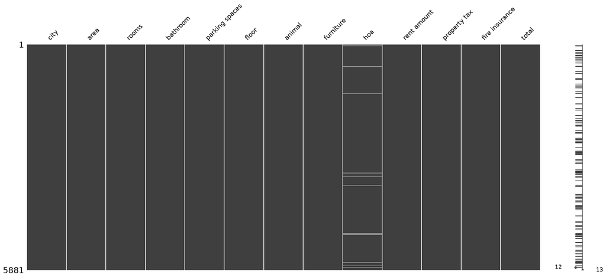

```python
msno.matrix(data)
```

### Hoa

‘Hoa’ será importante, diferente das outras variáveis de valores ela pode nos sugerir um atributo qualitativo importante: caso o imóvel seja apartamento, pode nos informar a qualidade e antiguidade do edifício visto que construções muito antigas, de pequeno porte, não costumam ter valores de condominio. Quanto ao caso de ser uma casa, um condominio costuma envolver imóveis de alto padrão ou acrescem fatores de segurança.

#### Analise inicial

```python
data[['area', 'floor', 'hoa','total']].groupby('floor', dropna=False).describe().T
```

|  | floor | 0 | 1 | 2 | 3 | 4 | 5 | 6 | 7 | 8 | 9 | ... | 27 | 28 | 29 | 31 | 32 | 35 | 51 | 68 | 85 | 99 |
| --- | --- | --- | --- | --- | --- | --- | --- | --- | --- | --- | --- | --- | --- | --- | --- | --- | --- | --- | --- | --- | --- | --- |
| area | count | 1497.0 | 536.0 | 369.0 | 384.0 | 306.0 | 302.0 | 294.0 | 284.0 | 288.0 | 222.0 | ... | 7.0 | 6.0 | 4.0 | 1.0 | 1.0 | 1.0 | 1.0 | 1.0 | 1.0 | 1.0 |
|  | mean | 224.400134 | 111.86194 | 104.826558 | 138.924479 | 114.924837 | 118.066225 | 111.282313 | 116.214789 | 130.46875 | 131.891892 | ... | 167.428571 | 239.333333 | 116.25 | 37.0 | 84.0 | 250.0 | 64.0 | 180.0 | 136.0 | 126.0 |
|  | std | 172.907697 | 101.628716 | 80.997096 | 649.646887 | 85.439601 | 88.344514 | 73.806767 | 83.102047 | 104.305196 | 111.101996 | ... | 116.678843 | 141.796568 | 47.352402 | NaN | NaN | NaN | NaN | NaN | NaN | NaN |
|  | min | 10.0 | 11.0 | 13.0 | 20.0 | 20.0 | 20.0 | 16.0 | 22.0 | 16.0 | 20.0 | ... | 42.0 | 40.0 | 77.0 | 37.0 | 84.0 | 250.0 | 64.0 | 180.0 | 136.0 | 126.0 |
|  | 25% | 94.0 | 51.75 | 52.0 | 52.0 | 53.0 | 55.0 | 56.0 | 56.75 | 57.0 | 57.25 | ... | 69.5 | 149.25 | 92.75 | 37.0 | 84.0 | 250.0 | 64.0 | 180.0 | 136.0 | 126.0 |
|  | 50% | 187.0 | 80.0 | 76.0 | 72.5 | 85.0 | 87.5 | 85.5 | 85.0 | 98.0 | 90.0 | ... | 178.0 | 248.0 | 101.5 | 37.0 | 84.0 | 250.0 | 64.0 | 180.0 | 136.0 | 126.0 |
|  | 75% | 300.0 | 130.0 | 130.0 | 139.25 | 145.0 | 170.0 | 144.75 | 150.0 | 178.25 | 170.0 | ... | 240.0 | 332.5 | 125.0 | 37.0 | 84.0 | 250.0 | 64.0 | 180.0 | 136.0 | 126.0 |
|  | max | 1600.0 | 900.0 | 600.0 | 12732.0 | 580.0 | 515.0 | 360.0 | 450.0 | 884.0 | 800.0 | ... | 333.0 | 423.0 | 185.0 | 37.0 | 84.0 | 250.0 | 64.0 | 180.0 | 136.0 | 126.0 |
| hoa | count | 1394.0 | 529.0 | 369.0 | 384.0 | 305.0 | 302.0 | 294.0 | 284.0 | 288.0 | 220.0 | ... | 7.0 | 6.0 | 4.0 | 1.0 | 1.0 | 1.0 | 1.0 | 1.0 | 1.0 | 1.0 |
|  | mean | 118.614778 | 1035.215501 | 1135.533875 | 1127.583333 | 1384.878689 | 1445.142384 | 1980.357143 | 2110.897887 | 1449.944444 | 1462.681818 | ... | 1431.428571 | 2491.333333 | 1387.5 | 583.0 | 850.0 | 2500.0 | 800.0 | 1700.0 | 1513.0 | 1570.0 |
|  | std | 647.220558 | 1131.226 | 1153.516365 | 1041.717067 | 1309.927349 | 1267.863013 | 11631.982142 | 13026.082178 | 1232.891405 | 1315.718436 | ... | 752.139805 | 1627.330534 | 534.438958 | <NA> | <NA> | <NA> | <NA> | <NA> | <NA> | <NA> |
|  | min | -3.0 | 0.0 | 0.0 | -1.0 | 0.0 | 0.0 | 0.0 | 0.0 | -2.0 | 0.0 | ... | 560.0 | 1460.0 | 750.0 | 583.0 | 850.0 | 2500.0 | 800.0 | 1700.0 | 1513.0 | 1570.0 |
|  | 25% | 0.0 | 300.0 | 420.0 | 409.5 | 520.0 | 583.5 | 600.0 | 566.75 | 638.0 | 599.5 | ... | 830.0 | 1817.0 | 1162.5 | 583.0 | 850.0 | 2500.0 | 800.0 | 1700.0 | 1513.0 | 1570.0 |
|  | 50% | 0.0 | 680.0 | 750.0 | 745.5 | 900.0 | 996.5 | 1000.0 | 974.0 | 1057.5 | 1000.0 | ... | 1500.0 | 1901.5 | 1375.0 | 583.0 | 850.0 | 2500.0 | 800.0 | 1700.0 | 1513.0 | 1570.0 |
|  | 75% | 0.0 | 1300.0 | 1439.0 | 1585.0 | 1800.0 | 1830.0 | 1715.0 | 1747.0 | 1901.75 | 1862.5 | ... | 1850.0 | 2058.75 | 1600.0 | 583.0 | 850.0 | 2500.0 | 800.0 | 1700.0 | 1513.0 | 1570.0 |
|  | max | 14130.0 | 8133.0 | 8300.0 | 4670.0 | 9900.0 | 8500.0 | 200000.0 | 220000.0 | 9000.0 | 7400.0 | ... | 2600.0 | 5785.0 | 2050.0 | 583.0 | 850.0 | 2500.0 | 800.0 | 1700.0 | 1513.0 | 1570.0 |
| total | count | 1497.0 | 536.0 | 369.0 | 384.0 | 306.0 | 302.0 | 294.0 | 284.0 | 288.0 | 222.0 | ... | 7.0 | 6.0 | 4.0 | 1.0 | 1.0 | 1.0 | 1.0 | 1.0 | 1.0 | 1.0 |
|  | mean | 5714.865063 | 4964.869403 | 4991.571816 | 4750.713542 | 5900.584967 | 6083.65894 | 7389.5 | 6457.003521 | 6220.916667 | 6529.486486 | ... | 10554.428571 | 13630.666667 | 11650.5 | 2311.0 | 9908.0 | 18775.0 | 2854.0 | 9239.0 | 5318.0 | 15164.0 |
|  | std | 4630.452748 | 4731.426697 | 4352.4915 | 3908.54246 | 5101.403005 | 4936.927634 | 22470.417682 | 14214.226698 | 4612.48367 | 5022.304891 | ... | 3540.876109 | 5905.765341 | 3506.701917 | <NA> | <NA> | <NA> | <NA> | <NA> | <NA> | <NA> |
|  | min | 660.0 | 835.0 | 803.0 | 940.0 | 817.0 | 889.0 | 925.0 | 871.0 | 927.0 | 912.0 | ... | 6028.0 | 6507.0 | 8798.0 | 2311.0 | 9908.0 | 18775.0 | 2854.0 | 9239.0 | 5318.0 | 15164.0 |
|  | 25% | 2226.0 | 1845.0 | 2058.0 | 2002.75 | 2270.25 | 2695.0 | 2683.0 | 2480.25 | 2801.25 | 2866.75 | ... | 7988.0 | 9328.0 | 10080.5 | 2311.0 | 9908.0 | 18775.0 | 2854.0 | 9239.0 | 5318.0 | 15164.0 |
|  | 50% | 4226.0 | 3044.5 | 3305.0 | 3271.0 | 3984.5 | 4099.5 | 4122.0 | 4172.0 | 4796.5 | 4483.0 | ... | 11430.0 | 14704.0 | 10518.0 | 2311.0 | 9908.0 | 18775.0 | 2854.0 | 9239.0 | 5318.0 | 15164.0 |
|  | 75% | 8086.0 | 6101.5 | 6423.0 | 6015.0 | 7969.0 | 7541.5 | 7041.5 | 7404.25 | 8227.75 | 9296.25 | ... | 12541.0 | 15468.25 | 12088.0 | 2311.0 | 9908.0 | 18775.0 | 2854.0 | 9239.0 | 5318.0 | 15164.0 |
|  | max | 54427.0 | 27844.0 | 28491.0 | 20828.0 | 27291.0 | 31582.0 | 316922.0 | 233153.0 | 28314.0 | 24914.0 | ... | 15365.0 | 22610.0 | 16768.0 | 2311.0 | 9908.0 | 18775.0 | 2854.0 | 9239.0 | 5318.0 | 15164.0 |

24 rows × 37 columns

```python
len(data[(data['hoa'].isnull()) & (data['floor'] == 0)])
```

```
103
```

Os casos acima são imóveis com andar 0, o que signigca que são casas ou sobrados, uma situação em que de forma esmagadora não ocorre taxa condominial. Por isso, iremos inserir 0.

```python
mascara = data[(data['hoa'].isnull()) & (data['floor'] == 0)].index
data.loc[mascara, 'hoa'] = data['hoa'].fillna(0)
```

```python
len(data[(data['hoa'].isnull()) & (data['floor'] > 0)])
```

```
11
```

```python
data[(data['hoa'].isnull()) & (data['floor'] > 0)].sort_values(by=['floor', 'total'])
```

|  | city | area | rooms | bathroom | parking spaces | floor | animal | furniture | hoa | rent amount | property tax | fire insurance | total |
| --- | --- | --- | --- | --- | --- | --- | --- | --- | --- | --- | --- | --- | --- |
| 352 | 1 | 30 | 1 | 1 | 0 | 1 | 0 | 0 | <NA> | 900 | 0 | 12 | 912 |
| 3379 | 1 | 40 | 1 | 1 | 0 | 1 | 0 | 0 | <NA> | 980 | 0 | 13 | 993 |
| 3788 | 1 | 45 | 1 | 1 | 0 | 1 | 0 | 0 | <NA> | 1100 | 0 | 17 | 1117 |
| 1087 | 1 | 127 | 3 | 2 | 2 | 1 | 1 | 0 | <NA> | 5000 | 250 | 76 | 5326 |
| 4313 | 1 | 41 | 3 | 2 | 1 | 1 | 0 | 1 | <NA> | 6500 | 0 | 83 | 6583 |
| 2613 | 1 | 500 | 5 | 5 | 8 | 1 | 1 | 0 | <NA> | 9800 | 92 | 148 | 10040 |
| 3403 | 1 | 410 | 4 | 5 | 5 | 1 | 1 | 0 | <NA> | 20000 | 0 | 254 | 20254 |
| 4045 | 1 | 20 | 1 | 1 | 0 | 4 | 0 | 0 | <NA> | 1000 | 84 | 13 | 1097 |
| 2931 | 1 | 30 | 1 | 1 | 1 | 9 | 0 | 0 | <NA> | 3000 | 0 | 39 | 3039 |
| 2015 | 1 | 185 | 3 | 3 | 2 | 9 | 1 | 0 | <NA> | 12000 | 0 | 153 | 12153 |
| 5537 | 1 | 110 | 3 | 2 | 2 | 14 | 1 | 0 | <NA> | 3200 | 0 | 41 | 3241 |

```python
data[(data['hoa'] == 0) & (data['floor'] > 0)].sort_values(by='total', ascending=False)
```

|  | city | area | rooms | bathroom | parking spaces | floor | animal | furniture | hoa | rent amount | property tax | fire insurance | total |
| --- | --- | --- | --- | --- | --- | --- | --- | --- | --- | --- | --- | --- | --- |
| 1980 | 1 | 900 | 4 | 9 | 8 | 1 | 1 | 0 | 0 | 15000 | 5700 | 226 | 20926 |
| 690 | 1 | 900 | 5 | 9 | 8 | 1 | 1 | 1 | 0 | 15000 | 5470 | 226 | 20696 |
| 731 | 1 | 296 | 4 | 5 | 3 | 3 | 1 | 0 | 0 | 15000 | 0 | 191 | 15191 |
| 481 | 1 | 340 | 4 | 4 | 3 | 2 | 1 | 0 | 0 | 14000 | 834 | 178 | 15012 |
| 2443 | 1 | 120 | 2 | 3 | 2 | 19 | 1 | 1 | 0 | 9920 | 0 | 126 | 10046 |
| ... | ... | ... | ... | ... | ... | ... | ... | ... | ... | ... | ... | ... | ... |
| 3317 | 1 | 25 | 1 | 1 | 0 | 1 | 0 | 0 | 0 | 885 | 0 | 12 | 897 |
| 376 | 1 | 16 | 1 | 1 | 0 | 1 | 0 | 0 | 0 | 850 | 35 | 11 | 896 |
| 221 | 1 | 16 | 1 | 1 | 0 | 1 | 0 | 0 | 0 | 850 | 30 | 11 | 891 |
| 3392 | 1 | 16 | 1 | 1 | 0 | 1 | 0 | 0 | 0 | 850 | 9 | 11 | 870 |
| 5523 | 0 | 42 | 1 | 1 | 0 | 1 | 1 | 0 | 0 | 830 | 12 | 11 | 853 |

126 rows × 13 columns

- Hipótese 1: Prédios/Kitnets sem condomínio (index 352, 3379, 3788 e 4045). São imóveis muito pequenos (áreas de 20 a 45m²), com 1 quarto. O fato de estarem no 1º andar (ou num 4º andar de prédio de escada) com aluguéis baixos (R$ 900 a R$ 1.100) corrobora que a taxa condominial de fato não existe.
- Hipótese 2: Taxa embutida no aluguel / “Pacote Fechado” (Índices 1087, 4313, 2613, 3403, 2931, 2015 e 5537). São imóveis de médio/alto padrão, alguns de andares altos (9º e 14º) ou áreas grandes (como os 500m² da linha 2613). O aluguel varia de R$ 3.000 a R$ 20.000. É pouco provável que não exista taxa de condomínio: ela foi somada ao rent amount pelo anunciante. Procuraremos por regressão estes valores.
- Como existem outros imóveis envolvidos nestas duas situações eram transformar todos NaN em 0 e depois tratá-los todos de uma única vez.

```python
mascara1 = data[(data['hoa'].isnull()) & (data['floor'] > 0)].index
mascara2 = data[(data['hoa'] == 0) & (data['floor'] > 0)].index

data['hoa_status'] = 'ok'
data.loc[mascara1, 'hoa_status'] = 'Suspeito - nan'
data.loc[mascara2, 'hoa_status'] = 'Suspeito - 0'
```

```python
data.loc[mascara1, 'hoa'] = data['hoa'].fillna(0)
```

Importante: O número de clusters será sempre definido segundo o método do cotovelo.

#### KMeans 1

```python
kmeans = data[['area', 'rooms', 'bathroom', 'parking spaces', 'floor', 'hoa']]
kmeans = kmeans[(kmeans['hoa'] == 0) & (kmeans['floor'] > 0)]
kmeans = kmeans.drop(columns='hoa')

standard = StandardScaler()

x = standard.fit_transform(kmeans)
model = KMeans(n_clusters=2, random_state=42, n_init=10)
clusters = model.fit_predict(x)

kmeans['cluster'] = clusters

print(kmeans['cluster'].value_counts())

kmeans.groupby('cluster').agg({
    'area': 'mean',
    'rooms': 'mean',
    'bathroom': 'mean',
    'parking spaces': 'mean',
    'floor': 'mean'})
```

```
cluster
0    133
1      4
Name: count, dtype: int64
```

| cluster | area | rooms | bathroom | parking spaces | floor |
| --- | --- | --- | --- | --- | --- |
| 0 | 66.406015 | 1.646617 | 1.353383 | 0.398496 | 2.887218 |
| 1 | 677.500000 | 4.500000 | 7.000000 | 7.250000 | 1.0 |

```python
altissimo_Padrao = kmeans[kmeans['cluster'] == 1].index
```

#### KMeans 2

```python
kmeans2 = kmeans[kmeans['cluster'] == 0]
kmeans2 = kmeans2.drop(columns='cluster')

x = standard.fit_transform(kmeans2)

resultados = []

for k in range(2, 8):
    model = KMeans(
        n_clusters=k,
        random_state=42,
        n_init=10)

    labels = model.fit_predict(x)

    resultados.append({
        'k': k,
        'silhouette': silhouette_score(x, labels),
        'inertia': model.inertia_})

pd.DataFrame(resultados)
```

|  | k | silhouette | inertia |
| --- | --- | --- | --- |
| 0 | 2 | 0.567466 | 392.137222 |
| 1 | 3 | 0.503208 | 289.336986 |
| 2 | 4 | 0.501071 | 230.224582 |
| 3 | 5 | 0.439296 | 183.709507 |
| 4 | 6 | 0.446643 | 163.054145 |
| 5 | 7 | 0.474435 | 144.308168 |

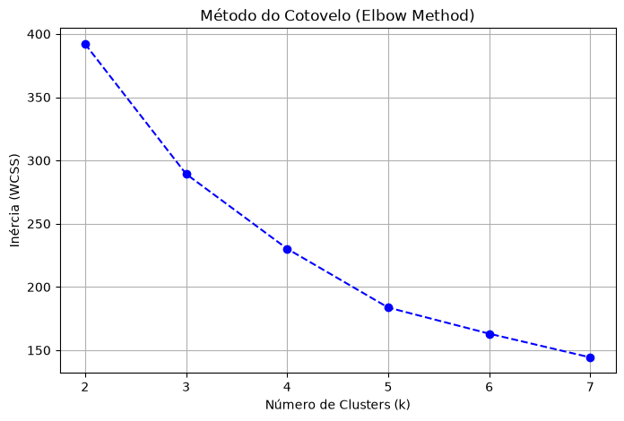

```python
ks = [r['k'] for r in resultados]
inercias = [r['inertia'] for r in resultados]

plt.figure(figsize=(8, 5))
plt.plot(ks, inercias, marker='o', color='b', linestyle='--')

plt.title('Método do Cotovelo (Elbow Method)')
plt.xlabel('Número de Clusters (k)')
plt.ylabel('Inércia (WCSS)')
plt.xticks(ks)
plt.grid(True)

plt.show()
```

```python
model = KMeans(n_clusters=3, random_state=42, n_init=10)
clusters = model.fit_predict(x)

kmeans2['cluster'] = clusters

print(kmeans2['cluster'].value_counts())

kmeans2.groupby('cluster').agg({
    'area': 'mean',
    'rooms': 'mean',
    'bathroom': 'mean',
    'parking spaces': 'mean',
    'floor': 'mean'})
```

```
cluster
0    100
2     18
1     15
Name: count, dtype: int64
```

| cluster | area | rooms | bathroom | parking spaces | floor |
| --- | --- | --- | --- | --- | --- |
| 0 | 49.650000 | 1.410000 | 1.080000 | 0.140000 | 1.54 |
| 1 | 179.266667 | 3.466667 | 3.200000 | 1.333333 | 2.666667 |
| 2 | 65.444444 | 1.444444 | 1.333333 | 1.055556 | 10.555556 |

```python
cluster0 = kmeans2[kmeans2['cluster'] == 0].index
cluster1 = kmeans2[kmeans2['cluster'] == 1].index
cluster2 = kmeans2[kmeans2['cluster'] == 2].index


print(f'Andar mais baixo: {data.loc[cluster2]['floor'].min()} | Andar mais alto: {data.loc[cluster2]['floor'].max()}')
data.loc[cluster2].sort_values(by=['area', 'total'])
```

```
Andar mais baixo: 5 | Andar mais alto: 19
```

|  | city | area | rooms | bathroom | parking spaces | floor | animal | furniture | hoa | rent amount | property tax | fire insurance | total | hoa_status |
| --- | --- | --- | --- | --- | --- | --- | --- | --- | --- | --- | --- | --- | --- | --- |
| 2675 | 1 | 25 | 1 | 1 | 1 | 8 | 1 | 1 | 0 | 4000 | 0 | 51 | 4051 | Suspeito - 0 |
| 2931 | 1 | 30 | 1 | 1 | 1 | 9 | 0 | 0 | 0 | 3000 | 0 | 39 | 3039 | Suspeito - nan |
| 5645 | 1 | 34 | 1 | 1 | 1 | 6 | 0 | 1 | 0 | 2900 | 0 | 37 | 2937 | Suspeito - 0 |
| 3496 | 1 | 40 | 1 | 1 | 0 | 8 | 0 | 0 | 0 | 1094 | 0 | 5 | 1099 | Suspeito - 0 |
| 635 | 1 | 40 | 1 | 1 | 0 | 18 | 0 | 1 | 0 | 2600 | 0 | 33 | 2633 | Suspeito - 0 |
| 1002 | 1 | 42 | 1 | 1 | 1 | 14 | 0 | 0 | 0 | 5000 | 0 | 64 | 5064 | Suspeito - 0 |
| 6043 | 0 | 45 | 1 | 1 | 1 | 17 | 1 | 1 | 0 | 1950 | 0 | 25 | 1975 | Suspeito - 0 |
| 4744 | 1 | 50 | 2 | 1 | 0 | 12 | 0 | 0 | 0 | 3029 | 0 | 39 | 3068 | Suspeito - 0 |
| 995 | 0 | 54 | 1 | 1 | 1 | 6 | 0 | 0 | 0 | 1370 | 31 | 18 | 1419 | Suspeito - 0 |
| 5277 | 1 | 59 | 2 | 1 | 1 | 8 | 1 | 0 | 0 | 3000 | 0 | 39 | 3039 | Suspeito - 0 |
| 1219 | 1 | 68 | 2 | 1 | 1 | 9 | 1 | 0 | 0 | 1850 | 0 | 24 | 1874 | Suspeito - 0 |
| 5456 | 1 | 77 | 1 | 1 | 1 | 8 | 0 | 0 | 0 | 5700 | 0 | 73 | 5773 | Suspeito - 0 |
| 4197 | 1 | 80 | 1 | 2 | 2 | 5 | 1 | 0 | 0 | 6522 | 0 | 83 | 6605 | Suspeito - 0 |
| 5591 | 1 | 92 | 2 | 1 | 1 | 11 | 0 | 0 | 0 | 6860 | 0 | 87 | 6947 | Suspeito - 0 |
| 3239 | 0 | 100 | 2 | 2 | 1 | 11 | 1 | 0 | 0 | 2000 | 0 | 26 | 2026 | Suspeito - 0 |
| 5537 | 1 | 110 | 3 | 2 | 2 | 14 | 1 | 0 | 0 | 3200 | 0 | 41 | 3241 | Suspeito - nan |
| 1769 | 1 | 112 | 1 | 2 | 2 | 7 | 1 | 1 | 0 | 8389 | 0 | 107 | 8496 | Suspeito - 0 |
| 2443 | 1 | 120 | 2 | 3 | 2 | 19 | 1 | 1 | 0 | 9920 | 0 | 126 | 10046 | Suspeito - 0 |

```python
print(f'Andar mais baixo: {data.loc[cluster1]['floor'].min()} | Andar mais alto: {data.loc[cluster1]['floor'].max()}')
data.loc[cluster1].sort_values(by=['area', 'total'])
```

```
Andar mais baixo: 1 | Andar mais alto: 9
```

|  | city | area | rooms | bathroom | parking spaces | floor | animal | furniture | hoa | rent amount | property tax | fire insurance | total | hoa_status |
| --- | --- | --- | --- | --- | --- | --- | --- | --- | --- | --- | --- | --- | --- | --- |
| 472 | 1 | 100 | 2 | 4 | 0 | 1 | 1 | 0 | 0 | 3000 | 0 | 39 | 3039 | Suspeito - 0 |
| 226 | 1 | 122 | 3 | 4 | 3 | 5 | 1 | 0 | 0 | 4500 | 0 | 58 | 4558 | Suspeito - 0 |
| 1087 | 1 | 127 | 3 | 2 | 2 | 1 | 1 | 0 | 0 | 5000 | 250 | 76 | 5326 | Suspeito - nan |
| 6027 | 1 | 130 | 3 | 4 | 0 | 3 | 1 | 1 | 0 | 2443 | 0 | 31 | 2474 | Suspeito - 0 |
| 650 | 1 | 130 | 5 | 2 | 0 | 2 | 1 | 0 | 0 | 3000 | 37 | 39 | 3076 | Suspeito - 0 |
| 2787 | 1 | 140 | 3 | 3 | 1 | 1 | 1 | 0 | 0 | 1750 | 79 | 23 | 1852 | Suspeito - 0 |
| 387 | 1 | 140 | 5 | 2 | 1 | 1 | 1 | 1 | 0 | 3999 | 200 | 51 | 4250 | Suspeito - 0 |
| 1274 | 1 | 150 | 4 | 3 | 0 | 2 | 1 | 0 | 0 | 2850 | 275 | 37 | 3162 | Suspeito - 0 |
| 4449 | 1 | 154 | 4 | 2 | 2 | 1 | 1 | 1 | 0 | 4500 | 321 | 68 | 4889 | Suspeito - 0 |
| 1609 | 1 | 175 | 3 | 4 | 3 | 7 | 1 | 0 | 0 | 9000 | 0 | 115 | 9115 | Suspeito - 0 |
| 2015 | 1 | 185 | 3 | 3 | 2 | 9 | 1 | 0 | 0 | 12000 | 0 | 153 | 12153 | Suspeito - nan |
| 1985 | 1 | 230 | 3 | 2 | 0 | 1 | 1 | 0 | 0 | 2500 | 500 | 32 | 3032 | Suspeito - 0 |
| 3388 | 1 | 270 | 3 | 4 | 0 | 1 | 1 | 0 | 0 | 3500 | 165 | 45 | 3710 | Suspeito - 0 |
| 731 | 1 | 296 | 4 | 5 | 3 | 3 | 1 | 0 | 0 | 15000 | 0 | 191 | 15191 | Suspeito - 0 |
| 481 | 1 | 340 | 4 | 4 | 3 | 2 | 1 | 0 | 0 | 14000 | 834 | 178 | 15012 | Suspeito - 0 |

```python
data.loc[cluster0].describe()
```

|  | city | area | rooms | bathroom | parking spaces | floor | animal | furniture | hoa | rent amount | property tax | fire insurance | total |
| --- | --- | --- | --- | --- | --- | --- | --- | --- | --- | --- | --- | --- | --- |
| count | 100.000000 | 100.000000 | 100.000000 | 100.00000 | 100.000000 | 100.0 | 100.0 | 100.0 | 100.0 | 100.0 | 100.0 | 100.0 | 100.0 |
| mean | 0.960000 | 49.650000 | 1.410000 | 1.08000 | 0.140000 | 1.54 | 0.56 | 0.18 | 0.0 | 1754.33 | 49.13 | 22.84 | 1826.3 |
| std | 0.196946 | 33.928438 | 0.604612 | 0.27266 | 0.348735 | 1.00925 | 0.498888 | 0.386123 | 0.0 | 1068.442632 | 92.19201 | 13.711103 | 1112.9785 |
| min | 0.000000 | 13.000000 | 1.000000 | 1.00000 | 0.000000 | 1.0 | 0.0 | 0.0 | 0.0 | 800.0 | 0.0 | 8.0 | 853.0 |
| 25% | 1.000000 | 25.000000 | 1.000000 | 1.00000 | 0.000000 | 1.0 | 0.0 | 0.0 | 0.0 | 1087.5 | 0.0 | 14.0 | 1112.5 |
| 50% | 1.000000 | 39.000000 | 1.000000 | 1.00000 | 0.000000 | 1.0 | 1.0 | 0.0 | 0.0 | 1454.5 | 11.0 | 19.0 | 1545.5 |
| 75% | 1.000000 | 61.250000 | 2.000000 | 1.00000 | 0.000000 | 2.0 | 1.0 | 0.0 | 0.0 | 2060.0 | 56.75 | 27.0 | 2087.0 |
| max | 1.000000 | 180.000000 | 3.000000 | 2.00000 | 1.000000 | 6.0 | 1.0 | 1.0 | 0.0 | 8000.0 | 667.0 | 102.0 | 8382.0 |

```python
data.loc[cluster2, 'hoa_status'] = 'HOA embutido'
data.loc[cluster1, 'hoa_status'] = 'HOA embutido'
data.loc[altissimo_Padrao, 'hoa_status'] = 'HOA embutido'
```

#### KMeans 3

```python
kmeans3 = data[['area', 'rooms', 'bathroom', 'parking spaces', 'floor', 'hoa_status', 'total']]
kmeans3 = kmeans3[kmeans3['hoa_status'].isin(['Suspeito - 0', 'Suspeito - nan'])]
kmeans3['valor_area'] = kmeans3['total'] / kmeans3['area']
kmeans3 = kmeans3.drop(columns='hoa_status')
kmeans3 = kmeans3.drop(columns='total')


#standard = StandardScaler()
#x = standard.fit_transform(kmeans3)
# Aqui não iremos usar a padronização para para que o sinal economico relativo a nova feature tenha maior importância na distancia pelo KMeans
x = kmeans3


resultados = []

for k in range(2, 8):
    model = KMeans(
        n_clusters=k,
        random_state=42,
        n_init=10)

    labels = model.fit_predict(x)

    resultados.append({
        'k': k,
        'silhouette': silhouette_score(x, labels),
        'inertia': model.inertia_})

pd.DataFrame(resultados)
```

|  | k | silhouette | inertia |
| --- | --- | --- | --- |
| 0 | 2 | 0.561032 | 139875.564636 |
| 1 | 3 | 0.551357 | 64575.895854 |
| 2 | 4 | 0.476759 | 44514.495924 |
| 3 | 5 | 0.482204 | 30771.282931 |
| 4 | 6 | 0.523915 | 19217.743740 |
| 5 | 7 | 0.528326 | 16033.799721 |

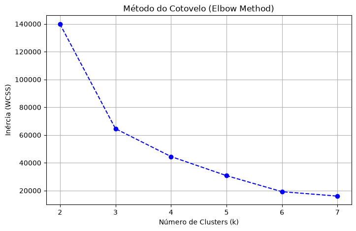

```python
ks = [r['k'] for r in resultados]
inercias = [r['inertia'] for r in resultados]

plt.figure(figsize=(8, 5))
plt.plot(ks, inercias, marker='o', color='b', linestyle='--')

plt.title('Método do Cotovelo (Elbow Method)')
plt.xlabel('Número de Clusters (k)')
plt.ylabel('Inércia (WCSS)')
plt.xticks(ks)
plt.grid(True)

plt.show()
```

```python
model = KMeans(n_clusters=3, random_state=42, n_init=10)
clusters = model.fit_predict(x)

kmeans3['cluster'] = clusters

print(kmeans3['cluster'].value_counts())

kmeans3.groupby('cluster').agg({
    'area': 'mean',
    'rooms': 'mean',
    'bathroom': 'mean',
    'parking spaces': 'mean',
    'floor': 'mean',
    'valor_area': 'mean'})
```

```
cluster
2    62
1    23
0    15
Name: count, dtype: int64
```

| cluster | area | rooms | bathroom | parking spaces | floor | valor_area |
| --- | --- | --- | --- | --- | --- | --- |
| 0 | 22.933333 | 1.133333 | 1.066667 | 0.133333 | 1.533333 | 136.735476 |
| 1 | 101.217391 | 2.086957 | 1.217391 | 0.086957 | 1.565217 | 20.562654 |
| 2 | 36.983871 | 1.225806 | 1.032258 | 0.161290 | 1.532258 | 42.007523 |

```python
cluster0 = kmeans3[kmeans3['cluster'] == 0].index
cluster1 = kmeans3[kmeans3['cluster'] == 1].index
cluster2 = kmeans3[kmeans3['cluster'] == 2].index
```

```python
print(f'Andar mais baixo: {data.loc[cluster0]['floor'].min()} | Andar mais alto: {data.loc[cluster0]['floor'].max()}')
data.loc[cluster0].sort_values(by=['area', 'total'])
```

```
Andar mais baixo: 1 | Andar mais alto: 3
```

|  | city | area | rooms | bathroom | parking spaces | floor | animal | furniture | hoa | rent amount | property tax | fire insurance | total | hoa_status |
| --- | --- | --- | --- | --- | --- | --- | --- | --- | --- | --- | --- | --- | --- | --- |
| 3263 | 1 | 13 | 1 | 1 | 0 | 1 | 1 | 0 | 0 | 2200 | 5 | 28 | 2233 | Suspeito - 0 |
| 5 | 1 | 13 | 1 | 1 | 0 | 2 | 1 | 0 | 0 | 2200 | 42 | 28 | 2270 | Suspeito - 0 |
| 3743 | 1 | 15 | 1 | 1 | 0 | 1 | 0 | 1 | 0 | 1550 | 0 | 20 | 1570 | Suspeito - 0 |
| 2413 | 1 | 16 | 1 | 1 | 0 | 2 | 1 | 0 | 0 | 2700 | 5 | 35 | 2740 | Suspeito - 0 |
| 5081 | 1 | 17 | 1 | 1 | 0 | 1 | 1 | 0 | 0 | 2700 | 5 | 35 | 2740 | Suspeito - 0 |
| 3328 | 1 | 17 | 1 | 1 | 0 | 2 | 1 | 0 | 0 | 2700 | 42 | 35 | 2777 | Suspeito - 0 |
| 60 | 1 | 20 | 1 | 1 | 0 | 1 | 0 | 1 | 0 | 1950 | 0 | 25 | 1975 | Suspeito - 0 |
| 864 | 1 | 20 | 1 | 1 | 0 | 1 | 0 | 1 | 0 | 2050 | 0 | 26 | 2076 | Suspeito - 0 |
| 172 | 1 | 20 | 1 | 1 | 0 | 1 | 1 | 1 | 0 | 2060 | 0 | 27 | 2087 | Suspeito - 0 |
| 765 | 1 | 20 | 1 | 1 | 0 | 2 | 0 | 1 | 0 | 2060 | 0 | 27 | 2087 | Suspeito - 0 |
| 5116 | 1 | 20 | 1 | 1 | 0 | 1 | 0 | 1 | 0 | 2060 | 0 | 27 | 2087 | Suspeito - 0 |
| 4466 | 1 | 21 | 1 | 1 | 0 | 2 | 1 | 0 | 0 | 3200 | 42 | 41 | 3283 | Suspeito - 0 |
| 2778 | 1 | 35 | 1 | 1 | 1 | 3 | 0 | 1 | 0 | 4200 | 17 | 54 | 4271 | Suspeito - 0 |
| 4313 | 1 | 41 | 3 | 2 | 1 | 1 | 0 | 1 | 0 | 6500 | 0 | 83 | 6583 | Suspeito - nan |
| 2066 | 1 | 56 | 1 | 1 | 0 | 2 | 1 | 1 | 0 | 8000 | 280 | 102 | 8382 | Suspeito - 0 |

```python
print(f'Andar mais baixo: {data.loc[cluster1]['floor'].min()} | Andar mais alto: {data.loc[cluster1]['floor'].max()}')
data.loc[cluster1].sort_values(by=['area', 'total'])
```

```
Andar mais baixo: 1 | Andar mais alto: 5
```

|  | city | area | rooms | bathroom | parking spaces | floor | animal | furniture | hoa | rent amount | property tax | fire insurance | total | hoa_status |
| --- | --- | --- | --- | --- | --- | --- | --- | --- | --- | --- | --- | --- | --- | --- |
| 2016 | 0 | 70 | 2 | 2 | 0 | 5 | 0 | 0 | 0 | 1000 | 62 | 16 | 1078 | Suspeito - 0 |
| 1799 | 1 | 70 | 2 | 1 | 0 | 1 | 1 | 0 | 0 | 1600 | 0 | 21 | 1621 | Suspeito - 0 |
| 5818 | 1 | 73 | 1 | 1 | 0 | 2 | 1 | 0 | 0 | 1350 | 62 | 18 | 1430 | Suspeito - 0 |
| 5670 | 1 | 80 | 2 | 1 | 0 | 1 | 0 | 0 | 0 | 1122 | 50 | 15 | 1187 | Suspeito - 0 |
| 2288 | 1 | 80 | 2 | 1 | 0 | 1 | 0 | 0 | 0 | 1200 | 0 | 16 | 1216 | Suspeito - 0 |
| 5731 | 1 | 80 | 1 | 1 | 1 | 2 | 0 | 0 | 0 | 1200 | 0 | 16 | 1216 | Suspeito - 0 |
| 5974 | 1 | 80 | 2 | 1 | 0 | 1 | 1 | 0 | 0 | 1572 | 130 | 20 | 1722 | Suspeito - 0 |
| 5457 | 1 | 80 | 2 | 1 | 0 | 1 | 1 | 0 | 0 | 1800 | 209 | 23 | 2032 | Suspeito - 0 |
| 5831 | 1 | 90 | 2 | 1 | 0 | 1 | 1 | 0 | 0 | 1400 | 142 | 18 | 1560 | Suspeito - 0 |
| 2038 | 1 | 90 | 2 | 1 | 0 | 1 | 1 | 0 | 0 | 1500 | 101 | 20 | 1621 | Suspeito - 0 |
| 1682 | 1 | 90 | 2 | 1 | 0 | 2 | 0 | 0 | 0 | 1720 | 0 | 26 | 1746 | Suspeito - 0 |
| 637 | 1 | 90 | 2 | 1 | 0 | 1 | 1 | 0 | 0 | 2000 | 280 | 26 | 2306 | Suspeito - 0 |
| 5449 | 1 | 95 | 3 | 2 | 0 | 2 | 1 | 0 | 0 | 2350 | 0 | 36 | 2386 | Suspeito - 0 |
| 3559 | 1 | 100 | 2 | 1 | 0 | 4 | 1 | 0 | 0 | 1500 | 50 | 23 | 1573 | Suspeito - 0 |
| 4562 | 1 | 100 | 3 | 1 | 0 | 1 | 1 | 0 | 0 | 2200 | 139 | 28 | 2367 | Suspeito - 0 |
| 45 | 1 | 100 | 2 | 2 | 0 | 1 | 1 | 0 | 0 | 2700 | 265 | 35 | 3000 | Suspeito - 0 |
| 4216 | 1 | 105 | 3 | 1 | 0 | 1 | 1 | 0 | 0 | 3700 | 667 | 47 | 4414 | Suspeito - 0 |
| 5296 | 1 | 120 | 2 | 1 | 0 | 1 | 0 | 0 | 0 | 2200 | 113 | 28 | 2341 | Suspeito - 0 |
| 458 | 1 | 120 | 3 | 2 | 0 | 1 | 1 | 0 | 0 | 2500 | 84 | 38 | 2622 | Suspeito - 0 |
| 4708 | 1 | 130 | 2 | 1 | 1 | 1 | 1 | 0 | 0 | 2200 | 180 | 28 | 2408 | Suspeito - 0 |
| 5497 | 1 | 135 | 2 | 1 | 0 | 2 | 0 | 0 | 0 | 2000 | 5 | 26 | 2031 | Suspeito - 0 |
| 215 | 1 | 170 | 2 | 1 | 0 | 1 | 1 | 1 | 0 | 2481 | 0 | 26 | 2507 | Suspeito - 0 |
| 2200 | 1 | 180 | 2 | 2 | 0 | 2 | 0 | 0 | 0 | 2850 | 0 | 37 | 2887 | Suspeito - 0 |

```python
print(f'Andar mais baixo: {data.loc[cluster2]['floor'].min()} | Andar mais alto: {data.loc[cluster2]['floor'].max()}')
data.loc[cluster2].head(60).sort_values(by=['area', 'total'])
```

```
Andar mais baixo: 1 | Andar mais alto: 6
```

|  | city | area | rooms | bathroom | parking spaces | floor | animal | furniture | hoa | rent amount | property tax | fire insurance | total | hoa_status |
| --- | --- | --- | --- | --- | --- | --- | --- | --- | --- | --- | --- | --- | --- | --- |
| 3392 | 1 | 16 | 1 | 1 | 0 | 1 | 0 | 0 | 0 | 850 | 9 | 11 | 870 | Suspeito - 0 |
| 221 | 1 | 16 | 1 | 1 | 0 | 1 | 0 | 0 | 0 | 850 | 30 | 11 | 891 | Suspeito - 0 |
| 376 | 1 | 16 | 1 | 1 | 0 | 1 | 0 | 0 | 0 | 850 | 35 | 11 | 896 | Suspeito - 0 |
| 3844 | 1 | 16 | 1 | 1 | 0 | 1 | 0 | 0 | 0 | 850 | 59 | 11 | 920 | Suspeito - 0 |
| 881 | 1 | 16 | 1 | 1 | 0 | 1 | 0 | 0 | 0 | 1200 | 59 | 16 | 1275 | Suspeito - 0 |
| 850 | 1 | 20 | 1 | 1 | 0 | 1 | 0 | 0 | 0 | 1000 | 10 | 13 | 1023 | Suspeito - 0 |
| 4045 | 1 | 20 | 1 | 1 | 0 | 4 | 0 | 0 | 0 | 1000 | 84 | 13 | 1097 | Suspeito - nan |
| 5572 | 1 | 20 | 1 | 1 | 0 | 1 | 0 | 0 | 0 | 1000 | 84 | 13 | 1097 | Suspeito - 0 |
| 5710 | 1 | 20 | 1 | 1 | 0 | 1 | 0 | 0 | 0 | 1100 | 35 | 14 | 1149 | Suspeito - 0 |
| 3317 | 1 | 25 | 1 | 1 | 0 | 1 | 0 | 0 | 0 | 885 | 0 | 12 | 897 | Suspeito - 0 |
| 5663 | 1 | 25 | 1 | 1 | 0 | 1 | 0 | 0 | 0 | 1049 | 31 | 14 | 1094 | Suspeito - 0 |
| 4733 | 1 | 25 | 1 | 1 | 0 | 1 | 0 | 0 | 0 | 1000 | 84 | 13 | 1097 | Suspeito - 0 |
| 2904 | 1 | 25 | 1 | 1 | 0 | 1 | 0 | 0 | 0 | 1050 | 84 | 14 | 1148 | Suspeito - 0 |
| 1252 | 1 | 25 | 1 | 1 | 0 | 1 | 0 | 0 | 0 | 1200 | 35 | 16 | 1251 | Suspeito - 0 |
| 3878 | 1 | 25 | 1 | 1 | 0 | 2 | 0 | 1 | 0 | 1750 | 0 | 23 | 1773 | Suspeito - 0 |
| 2472 | 1 | 26 | 1 | 1 | 0 | 2 | 0 | 0 | 0 | 2060 | 0 | 27 | 2087 | Suspeito - 0 |
| 1008 | 1 | 28 | 1 | 1 | 0 | 1 | 1 | 0 | 0 | 1329 | 15 | 17 | 1361 | Suspeito - 0 |
| 3827 | 1 | 28 | 1 | 1 | 0 | 1 | 0 | 1 | 0 | 1750 | 0 | 23 | 1773 | Suspeito - 0 |
| 352 | 1 | 30 | 1 | 1 | 0 | 1 | 0 | 0 | 0 | 900 | 0 | 12 | 912 | Suspeito - nan |
| 5530 | 1 | 30 | 1 | 1 | 0 | 1 | 0 | 0 | 0 | 1459 | 0 | 10 | 1469 | Suspeito - 0 |
| 233 | 1 | 30 | 1 | 1 | 0 | 1 | 1 | 1 | 0 | 1550 | 21 | 20 | 1591 | Suspeito - 0 |
| 1999 | 1 | 30 | 1 | 1 | 0 | 1 | 1 | 0 | 0 | 1550 | 21 | 20 | 1591 | Suspeito - 0 |
| 5309 | 1 | 30 | 1 | 1 | 0 | 2 | 1 | 0 | 0 | 1850 | 0 | 24 | 1874 | Suspeito - 0 |
| 3327 | 1 | 30 | 1 | 1 | 0 | 2 | 0 | 0 | 0 | 2060 | 0 | 27 | 2087 | Suspeito - 0 |
| 1891 | 1 | 31 | 2 | 1 | 0 | 2 | 1 | 0 | 0 | 1040 | 0 | 14 | 1054 | Suspeito - 0 |
| 2001 | 1 | 34 | 1 | 1 | 1 | 1 | 0 | 1 | 0 | 2890 | 0 | 37 | 2927 | Suspeito - 0 |
| 3538 | 1 | 35 | 1 | 1 | 0 | 1 | 0 | 0 | 0 | 900 | 50 | 12 | 962 | Suspeito - 0 |
| 2170 | 1 | 35 | 1 | 1 | 0 | 1 | 1 | 0 | 0 | 950 | 30 | 13 | 993 | Suspeito - 0 |
| 5680 | 1 | 35 | 1 | 1 | 1 | 1 | 1 | 0 | 0 | 977 | 30 | 13 | 1020 | Suspeito - 0 |
| 1866 | 1 | 35 | 1 | 1 | 1 | 1 | 1 | 0 | 0 | 1010 | 30 | 13 | 1053 | Suspeito - 0 |
| 3440 | 1 | 35 | 1 | 1 | 1 | 1 | 1 | 0 | 0 | 1020 | 30 | 13 | 1063 | Suspeito - 0 |
| 2674 | 1 | 35 | 1 | 1 | 0 | 1 | 0 | 1 | 0 | 1650 | 0 | 21 | 1671 | Suspeito - 0 |
| 942 | 1 | 35 | 1 | 1 | 0 | 1 | 0 | 1 | 0 | 1700 | 0 | 22 | 1722 | Suspeito - 0 |
| 1928 | 1 | 37 | 1 | 1 | 0 | 1 | 1 | 0 | 0 | 1400 | 0 | 18 | 1418 | Suspeito - 0 |
| 1396 | 1 | 37 | 2 | 1 | 0 | 1 | 0 | 0 | 0 | 1500 | 25 | 20 | 1545 | Suspeito - 0 |
| 342 | 1 | 38 | 1 | 1 | 0 | 6 | 1 | 0 | 0 | 1680 | 0 | 22 | 1702 | Suspeito - 0 |
| 3379 | 1 | 40 | 1 | 1 | 0 | 1 | 0 | 0 | 0 | 980 | 0 | 13 | 993 | Suspeito - nan |
| 4323 | 1 | 40 | 1 | 1 | 0 | 1 | 1 | 0 | 0 | 1000 | 56 | 13 | 1069 | Suspeito - 0 |
| 3618 | 1 | 40 | 1 | 1 | 1 | 1 | 1 | 0 | 0 | 1300 | 30 | 17 | 1347 | Suspeito - 0 |
| 5523 | 0 | 42 | 1 | 1 | 0 | 1 | 1 | 0 | 0 | 830 | 12 | 11 | 853 | Suspeito - 0 |
| 145 | 1 | 42 | 1 | 1 | 0 | 2 | 1 | 1 | 0 | 3256 | 0 | 42 | 3298 | Suspeito - 0 |
| 1039 | 1 | 44 | 1 | 1 | 0 | 1 | 0 | 0 | 0 | 1200 | 30 | 16 | 1246 | Suspeito - 0 |
| 3788 | 1 | 45 | 1 | 1 | 0 | 1 | 0 | 0 | 0 | 1100 | 0 | 17 | 1117 | Suspeito - nan |
| 5650 | 1 | 45 | 1 | 1 | 0 | 2 | 0 | 0 | 0 | 1400 | 69 | 18 | 1487 | Suspeito - 0 |
| 2711 | 1 | 49 | 1 | 2 | 0 | 1 | 1 | 0 | 0 | 1300 | 0 | 17 | 1317 | Suspeito - 0 |
| 1057 | 1 | 50 | 1 | 1 | 0 | 1 | 1 | 0 | 0 | 950 | 0 | 15 | 965 | Suspeito - 0 |
| 5465 | 0 | 50 | 2 | 1 | 1 | 1 | 1 | 0 | 0 | 800 | 200 | 11 | 1011 | Suspeito - 0 |
| 5683 | 0 | 50 | 2 | 1 | 1 | 3 | 1 | 0 | 0 | 1000 | 0 | 13 | 1013 | Suspeito - 0 |
| 5027 | 1 | 50 | 2 | 1 | 0 | 3 | 1 | 0 | 0 | 1200 | 50 | 16 | 1266 | Suspeito - 0 |
| 4664 | 1 | 50 | 1 | 1 | 0 | 1 | 1 | 1 | 0 | 1550 | 0 | 24 | 1574 | Suspeito - 0 |
| 2332 | 1 | 52 | 2 | 1 | 0 | 3 | 1 | 0 | 0 | 1340 | 0 | 17 | 1357 | Suspeito - 0 |
| 3892 | 1 | 52 | 2 | 1 | 0 | 4 | 1 | 0 | 0 | 1340 | 0 | 17 | 1357 | Suspeito - 0 |
| 506 | 1 | 52 | 2 | 1 | 1 | 4 | 1 | 0 | 0 | 1450 | 0 | 19 | 1469 | Suspeito - 0 |
| 1914 | 1 | 55 | 1 | 1 | 0 | 1 | 1 | 0 | 0 | 1100 | 0 | 8 | 1108 | Suspeito - 0 |
| 3882 | 1 | 55 | 1 | 2 | 0 | 1 | 1 | 0 | 0 | 1400 | 0 | 18 | 1418 | Suspeito - 0 |
| 4630 | 1 | 60 | 2 | 1 | 1 | 1 | 1 | 0 | 0 | 1100 | 0 | 14 | 1114 | Suspeito - 0 |
| 5552 | 1 | 60 | 1 | 1 | 0 | 1 | 1 | 0 | 0 | 1250 | 280 | 16 | 1546 | Suspeito - 0 |
| 971 | 1 | 60 | 2 | 1 | 1 | 2 | 1 | 0 | 0 | 2700 | 0 | 35 | 2735 | Suspeito - 0 |
| 1562 | 1 | 65 | 3 | 1 | 0 | 1 | 1 | 0 | 0 | 3655 | 159 | 47 | 3861 | Suspeito - 0 |
| 1992 | 1 | 70 | 2 | 1 | 0 | 1 | 1 | 0 | 0 | 2448 | 159 | 32 | 2639 | Suspeito - 0 |

```python
data.loc[cluster2].describe()
```

|  | city | area | rooms | bathroom | parking spaces | floor | animal | furniture | hoa | rent amount | property tax | fire insurance | total |
| --- | --- | --- | --- | --- | --- | --- | --- | --- | --- | --- | --- | --- | --- |
| count | 62.000000 | 62.000000 | 62.000000 | 62.000000 | 62.000000 | 62.0 | 62.0 | 62.0 | 62.0 | 62.0 | 62.0 | 62.0 | 62.0 |
| mean | 0.951613 | 36.983871 | 1.225806 | 1.032258 | 0.161290 | 1.532258 | 0.532258 | 0.129032 | 0.0 | 1373.516129 | 31.225806 | 17.806452 | 1422.548387 |
| std | 0.216335 | 13.420674 | 0.458771 | 0.178127 | 0.370801 | 1.082161 | 0.503032 | 0.337972 | 0.0 | 583.89949 | 52.726458 | 7.639068 | 595.182096 |
| min | 0.000000 | 16.000000 | 1.000000 | 1.000000 | 0.000000 | 1.0 | 0.0 | 0.0 | 0.0 | 800.0 | 0.0 | 8.0 | 853.0 |
| 25% | 1.000000 | 26.500000 | 1.000000 | 1.000000 | 0.000000 | 1.0 | 0.0 | 0.0 | 0.0 | 1000.0 | 0.0 | 13.0 | 1053.25 |
| 50% | 1.000000 | 35.000000 | 1.000000 | 1.000000 | 0.000000 | 1.0 | 1.0 | 0.0 | 0.0 | 1200.0 | 9.5 | 16.0 | 1258.5 |
| 75% | 1.000000 | 48.250000 | 1.000000 | 1.000000 | 0.000000 | 2.0 | 1.0 | 0.0 | 0.0 | 1537.5 | 35.0 | 20.0 | 1567.0 |
| max | 1.000000 | 70.000000 | 3.000000 | 2.000000 | 1.000000 | 6.0 | 1.0 | 1.0 | 0.0 | 3655.0 | 280.0 | 47.0 | 3861.0 |

- Cluster 0: São imóveis cujo o preço total do aluguel é alto relativo ao tamanho da área. Esse comportamento é compatível com a hipótese de HOA embutido e o grupo será encaminhado para investigação posterior.
- Cluster 1: São imóveis cujo o preço total do aluguel é baixo relativo ao tamanho da área, podendo pressumir que tratam-se de imóveis sem taxa condominial.
- Cluster 2: São imóveis cujo o preço total do aluguel é baixo relativo ao tamanho da área, podendo pressumir que tratam-se de imóveis sem taxa condominial. A diferença quanto ao grupo anterior é que este possui um corte de imóveis abaixo de 71 metros.

```python
data.loc[cluster0, 'hoa_status'] = 'HOA embutido'
data.loc[cluster1, 'hoa_status'] = 'ok'
data.loc[cluster2, 'hoa_status'] = 'ok'
```

#### Definições sobre ’hoa

```python
data['hoa_status'].value_counts()
```

```
hoa_status
ok              5829
HOA embutido      52
Name: count, dtype: int64
```

```python
mascara = data[(data['hoa'] == 0) & (data['floor'] == 0)].index
data.loc[mascara,'hoa_status'] = 'casa_sem_condominio'
```

```python
mascara = data[(data['hoa'] == 0) & (data['floor'] > 0) & (data['hoa_status'] == 'ok')].index
data.loc[mascara,'hoa_status'] = 'sem taxa'
```

```python
data['hoa_status'].value_counts()
```

```
hoa_status
ok                     4446
casa_sem_condominio    1298
sem taxa                 85
HOA embutido             52
Name: count, dtype: int64
```

```python
data[(data['hoa_status'] == 'ok') & (data['hoa'] < 100)]
```

|  | city | area | rooms | bathroom | parking spaces | floor | animal | furniture | hoa | rent amount | property tax | fire insurance | total | hoa_status |
| --- | --- | --- | --- | --- | --- | --- | --- | --- | --- | --- | --- | --- | --- | --- |
| 276 | 1 | 150 | 2 | 2 | 1 | 0 | 1 | 0 | 1 | 2100 | 0 | 32 | 2133 | ok |
| 288 | 1 | 48 | 2 | 1 | 0 | 2 | 1 | 0 | 90 | 1150 | 90 | 15 | 1345 | ok |
| 378 | 1 | 300 | 3 | 3 | 3 | 0 | 1 | 0 | 1 | 3400 | 417 | 52 | 3870 | ok |
| 453 | 1 | 25 | 1 | 1 | 0 | 0 | 1 | 0 | 20 | 1200 | 25 | 19 | 1264 | ok |
| 624 | 1 | 200 | 2 | 2 | 2 | 0 | 1 | 0 | 1 | 3000 | 167 | 46 | 3214 | ok |
| 628 | 1 | 145 | 3 | 1 | 2 | 0 | 1 | 1 | 90 | 7200 | 238 | 109 | 7637 | ok |
| 648 | 1 | 80 | 1 | 1 | 1 | 5 | 1 | 1 | 1 | 7200 | 0 | 92 | 7293 | ok |
| 658 | 1 | 45 | 2 | 1 | 0 | 2 | 1 | 0 | 60 | 900 | 42 | 12 | 1014 | ok |
| 774 | 1 | 58 | 2 | 3 | 2 | 0 | 0 | 0 | 50 | 2000 | 0 | 31 | 2081 | ok |
| 925 | 1 | 180 | 2 | 2 | 5 | 0 | 1 | 0 | 1 | 3000 | 1 | 46 | 3048 | ok |
| 938 | 1 | 35 | 1 | 1 | 0 | 0 | 1 | 0 | 50 | 850 | 65 | 13 | 978 | ok |
| 1073 | 1 | 48 | 2 | 1 | 0 | 2 | 1 | 0 | 90 | 1191 | 90 | 16 | 1387 | ok |
| 1187 | 1 | 255 | 4 | 4 | 3 | 13 | 1 | 1 | -1 | 11900 | 0 | 151 | 12050 | ok |
| 1282 | 1 | 23 | 1 | 1 | 0 | 2 | 0 | 0 | 30 | 950 | 34 | 13 | 1027 | ok |
| 1319 | 1 | 48 | 1 | 1 | 0 | 3 | 1 | 0 | 90 | 950 | 90 | 26 | 1156 | ok |
| 1367 | 1 | 300 | 3 | 3 | 4 | 0 | 1 | 0 | 1 | 3700 | 950 | 56 | 4707 | ok |
| 1454 | 1 | 300 | 3 | 4 | 4 | 0 | 1 | 0 | 1 | 2800 | 292 | 43 | 3136 | ok |
| 1460 | 1 | 440 | 1 | 2 | 4 | 0 | 1 | 0 | 1 | 9800 | 584 | 148 | 10533 | ok |
| 1549 | 1 | 350 | 4 | 3 | 4 | 0 | 1 | 0 | 1 | 7300 | 600 | 110 | 8011 | ok |
| 1553 | 1 | 190 | 3 | 3 | 4 | 0 | 1 | 1 | 1 | 4500 | 0 | 68 | 4569 | ok |
| 1588 | 1 | 800 | 5 | 7 | 6 | 0 | 1 | 0 | 1 | 15000 | 2051 | 226 | 17278 | ok |
| 1641 | 1 | 180 | 2 | 3 | 2 | 13 | 1 | 0 | 1 | 12500 | 0 | 159 | 12660 | ok |
| 1732 | 1 | 27 | 1 | 1 | 0 | 2 | 0 | 0 | 50 | 895 | 41 | 12 | 998 | ok |
| 1744 | 1 | 35 | 1 | 1 | 0 | 1 | 1 | 0 | 1 | 1950 | 0 | 25 | 1976 | ok |
| 1810 | 1 | 240 | 3 | 4 | 2 | 0 | 1 | 0 | 1 | 8200 | 625 | 124 | 8950 | ok |
| 2161 | 1 | 600 | 4 | 3 | 4 | 2 | 1 | 0 | 1 | 6400 | 0 | 82 | 6483 | ok |
| 2165 | 1 | 74 | 2 | 1 | 0 | 2 | 0 | 0 | 1 | 2500 | 1 | 32 | 2534 | ok |
| 2215 | 1 | 35 | 1 | 1 | 1 | 0 | 0 | 0 | 60 | 1249 | 0 | 8 | 1317 | ok |
| 2412 | 1 | 174 | 3 | 3 | 2 | 0 | 1 | 0 | 20 | 4300 | 183 | 39 | 4542 | ok |
| 2417 | 1 | 48 | 2 | 2 | 1 | 0 | 0 | 0 | 80 | 1900 | 0 | 29 | 2009 | ok |
| 2521 | 1 | 70 | 2 | 1 | 1 | 0 | 1 | 0 | 60 | 2100 | 0 | 32 | 2192 | ok |
| 2679 | 1 | 80 | 2 | 2 | 2 | 0 | 1 | 0 | 50 | 1850 | 173 | 28 | 2101 | ok |
| 2771 | 1 | 150 | 3 | 3 | 2 | 8 | 0 | 1 | -2 | 13500 | 0 | 172 | 13670 | ok |
| 3296 | 1 | 35 | 1 | 1 | 0 | 2 | 0 | 1 | 1 | 1587 | 0 | 21 | 1609 | ok |
| 3343 | 1 | 260 | 4 | 5 | 5 | 3 | 1 | 1 | -1 | 15000 | 0 | 191 | 15190 | ok |
| 3351 | 0 | 300 | 3 | 3 | 4 | 0 | 1 | 0 | 1 | 3800 | 450 | 58 | 4309 | ok |
| 3467 | 1 | 400 | 3 | 3 | 6 | 0 | 1 | 0 | 1 | 15000 | 1123 | 226 | 16350 | ok |
| 3666 | 1 | 50 | 1 | 1 | 0 | 1 | 1 | 0 | 50 | 750 | 25 | 10 | 835 | ok |
| 3719 | 1 | 20 | 1 | 1 | 0 | 0 | 1 | 0 | 20 | 1200 | 25 | 19 | 1264 | ok |
| 3724 | 1 | 32 | 1 | 1 | 0 | 1 | 0 | 0 | 26 | 1290 | 33 | 17 | 1366 | ok |
| 3760 | 1 | 45 | 2 | 1 | 0 | 0 | 0 | 0 | 70 | 1450 | 43 | 22 | 1585 | ok |
| 3775 | 1 | 50 | 2 | 1 | 0 | 1 | 1 | 0 | 54 | 2000 | 42 | 26 | 2122 | ok |
| 3869 | 1 | 100 | 2 | 3 | 2 | 9 | 1 | 0 | 5 | 12960 | 0 | 165 | 13130 | ok |
| 3983 | 1 | 1600 | 4 | 5 | 12 | 0 | 1 | 0 | 1 | 7900 | 5000 | 119 | 13020 | ok |
| 4296 | 1 | 800 | 4 | 2 | 6 | 0 | 1 | 1 | -3 | 15000 | 1667 | 226 | 16890 | ok |
| 4534 | 1 | 80 | 2 | 2 | 2 | 0 | 1 | 0 | 50 | 1700 | 177 | 26 | 1953 | ok |
| 5066 | 1 | 38 | 1 | 1 | 0 | 1 | 0 | 0 | 60 | 950 | 0 | 13 | 1023 | ok |
| 5173 | 1 | 30 | 1 | 1 | 0 | 1 | 1 | 0 | 50 | 1150 | 50 | 15 | 1265 | ok |
| 5246 | 1 | 40 | 2 | 1 | 0 | 3 | 1 | 0 | 80 | 1275 | 87 | 17 | 1459 | ok |
| 5284 | 1 | 45 | 1 | 1 | 0 | 1 | 0 | 0 | 50 | 1360 | 0 | 18 | 1428 | ok |
| 5471 | 1 | 80 | 2 | 2 | 2 | 0 | 1 | 0 | 50 | 2200 | 173 | 34 | 2457 | ok |
| 5545 | 1 | 120 | 1 | 1 | 4 | 0 | 1 | 1 | 1 | 3300 | 275 | 50 | 3626 | ok |
| 5760 | 1 | 211 | 2 | 2 | 2 | 0 | 1 | 0 | 1 | 4500 | 752 | 68 | 5321 | ok |
| 5819 | 1 | 280 | 3 | 4 | 1 | 0 | 1 | 0 | 1 | 3700 | 100 | 56 | 3857 | ok |

A coluna hoa possui problemas de qualidade e ambiguidades que não são suficientemente identificáveis apenas pela EDA atual. Portanto, não será utilizada como variável numérica confiável.

```python
mascara_casa_sem_condominio = data[data['hoa_status'] == 'casa_sem_condominio'].index
mascara_casa_condominio = data[(data['hoa_status'] == 'ok') & (data['floor'] == 0)].index
mascara_apartamento_condominio = data[(data['hoa_status'] == 'ok') & (data['floor'] > 0)].index
mascara_apartamento_sem_condominio = data[(data['hoa_status'] == 'sem taxa')].index
mascara_apartamento_condominio2 = data[(data['hoa_status'] == 'HOA embutido')].index

data['apartamento'] = 10
data['condominio'] = 10

data.loc[mascara_apartamento_condominio, 'apartamento'] = 1
data.loc[mascara_apartamento_sem_condominio, 'apartamento'] = 1
data.loc[mascara_casa_sem_condominio, 'apartamento'] = 0
data.loc[mascara_casa_condominio, 'apartamento'] = 0
data.loc[mascara_apartamento_condominio2, 'apartamento'] = 1


data.loc[mascara_apartamento_condominio, 'condominio'] = 1
data.loc[mascara_apartamento_sem_condominio, 'condominio'] = 0
data.loc[mascara_casa_sem_condominio,'condominio'] = 0
data.loc[mascara_casa_condominio, 'condominio'] = 1
data.loc[mascara_apartamento_condominio2, 'condominio'] = 1
```

```python
data.drop(columns=['hoa_status'], inplace=True)
data['valor_m2'] = data['total'] / data['area']
```

### Limpeza Outliers

```python
col_del_futuro = ['hoa', 'rent amount', 'property tax', 'fire insurance']
```

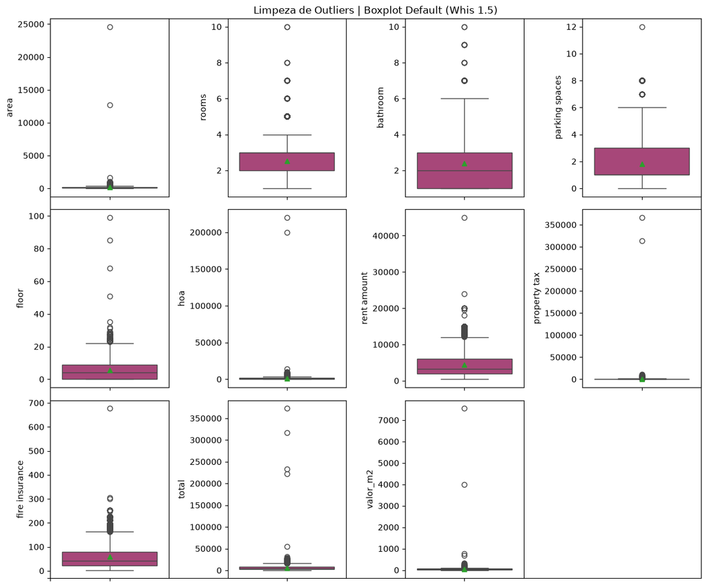

```python
plt.figure(figsize=(12,10))
plt.title('Limpeza de Outliers | Boxplot Default (Whis 1.5)')
plt.xticks([0], [''])
plt.yticks([0], [''])
for i in range(11):
    plt.subplot(3,4,i+1)
    sns.boxplot(data=data.drop(columns=['city', 'animal', 'furniture', 'condominio', 'apartamento']), y=data.drop(columns=['city', 'animal', 'furniture', 'condominio', 'apartamento']).columns[i], showmeans=True, palette='magma')
plt.tight_layout()
```

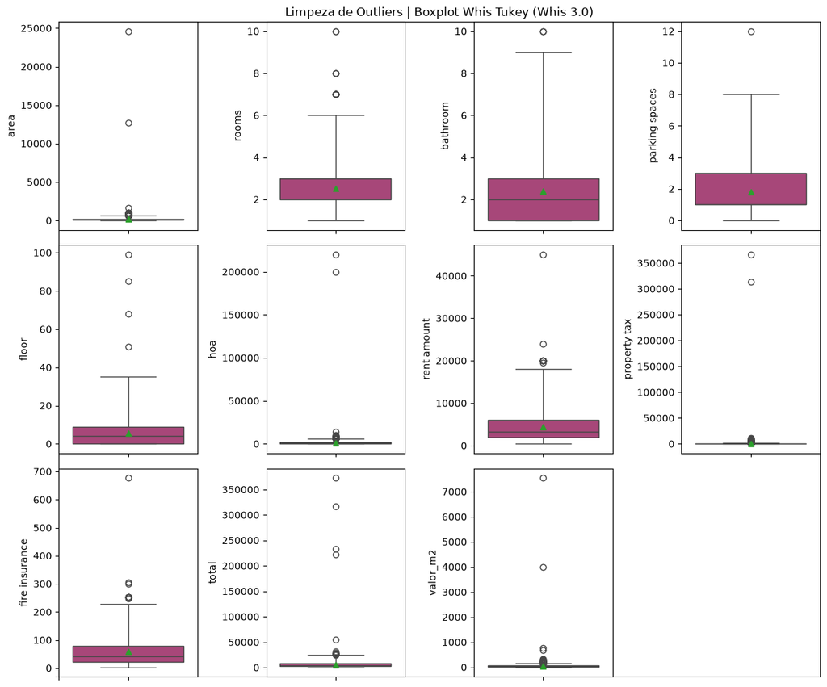

```python
plt.figure(figsize=(12,10))
plt.title('Limpeza de Outliers | Boxplot Whis Tukey (Whis 3.0)')
plt.xticks([0], [''])
plt.yticks([0], [''])
for i in range(11):
    plt.subplot(3,4,i+1)
    sns.boxplot(data=data.drop(columns=['city', 'animal', 'furniture', 'condominio', 'apartamento']), y=data.drop(columns=['city', 'animal', 'furniture', 'condominio', 'apartamento']).columns[i], showmeans=True, palette='magma', whis=3.0)
plt.tight_layout()
```

```python
def box_out (x):
    q3 = x.quantile(0.75)
    q1 = x.quantile(0.25)
    iqr = q3 - q1

    limite_sup_nor = q3 + (1.5 * iqr)
    limite_inf_nor = q1 - (1.5 * iqr)

    limite_sup_tuk = q3 + (3 * iqr)
    limite_inf_tuk = q1 - (3 * iqr)

    return limite_inf_nor, limite_sup_nor, limite_inf_tuk, limite_sup_tuk
```

Os atributos rooms, bathroom e parking spaces inicialmente não serão considerados na análise de outlier, pois serão desvios considerados implícitos ao modelo de negócio.

Em um processo normal, a recomendação seria atuarmos em conjunto com outros especialistas e stakeholders no processo de análise antes de uma exclusão. Aqui não teremos esta possibilidade. Por isso, registros que falharem duas vezes no teste de outliers (default com 1.5 e método de tukey com 3.0) serão fortes candidatos a exclusão, exceto para os casos em que consigamos justificar a permanencia.

Os boxplots nos mostram que somente possuimos outliers nos limites superiores, por isso nos códigos abaixo somente iremos visualizar o dataframe a partir deste limite. Além disso, é importante salientar que o objetivo não é retirar todos os outliers, mas sim: remover ou transformar observações que possam prejudicar a análise/modelagem quando houver evidência suficiente de que são inconsistentes ou inadequadas ao universo analisado.

#### Area

```python
lim_area = box_out(data['area'])
outliers_area = data[data['area'] > lim_area[3]].index

data[data['area'] > lim_area[3]].sort_values(by='area', ascending=False)
```

|  | city | area | rooms | bathroom | parking spaces | floor | animal | furniture | hoa | rent amount | property tax | fire insurance | total | apartamento | condominio | valor_m2 |
| --- | --- | --- | --- | --- | --- | --- | --- | --- | --- | --- | --- | --- | --- | --- | --- | --- |
| 4178 | 1 | 24606 | 5 | 4 | 4 | 12 | 1 | 0 | 2254 | 8100 | 7859 | 103 | 18316 | 1 | 1 | 0.744371 |
| 5494 | 0 | 12732 | 3 | 2 | 0 | 3 | 1 | 0 | 700 | 1600 | 96 | 21 | 2417 | 1 | 1 | 0.189837 |
| 3983 | 1 | 1600 | 4 | 5 | 12 | 0 | 1 | 0 | 1 | 7900 | 5000 | 119 | 13020 | 0 | 1 | 8.1375 |
| 5178 | 1 | 1000 | 4 | 7 | 4 | 10 | 1 | 1 | 6000 | 15000 | 4900 | 191 | 26091 | 1 | 1 | 26.091 |
| 1533 | 0 | 999 | 5 | 7 | 8 | 0 | 1 | 0 | 0 | 14000 | 667 | 211 | 14878 | 0 | 0 | 14.892893 |
| ... | ... | ... | ... | ... | ... | ... | ... | ... | ... | ... | ... | ... | ... | ... | ... | ... |
| 4718 | 0 | 650 | 4 | 7 | 5 | 0 | 1 | 0 | 0 | 8000 | 334 | 121 | 8455 | 0 | 0 | 13.007692 |
| 1651 | 1 | 645 | 5 | 8 | 8 | 0 | 1 | 0 | 0 | 15000 | 2334 | 226 | 17560 | 0 | 0 | 27.224806 |
| 307 | 1 | 640 | 4 | 4 | 4 | 12 | 1 | 1 | 5400 | 10200 | 1584 | 130 | 17314 | 1 | 1 | 27.053125 |
| 1066 | 1 | 630 | 4 | 6 | 4 | 0 | 0 | 0 | 0 | 12300 | 2667 | 185 | 15152 | 0 | 0 | 24.050794 |
| 5621 | 1 | 629 | 4 | 4 | 4 | 0 | 1 | 0 | 0 | 15000 | 2064 | 226 | 17290 | 0 | 0 | 27.488076 |

64 rows × 16 columns

Tirando as duas linhas superiores (possivelmente áreas para fins industriais), com mais de 10k de area, os outros valores são possíveis, sendo imóveis de luxo. Porém, devido sua raridade e um de nossos objetivos ser ao final possuir um modelo preditor de valor de aluguel, estes dados podem introduzir uma variância extrema em nossos dados que atrapalharia este modelo, devido a falta de outros atributos não expostos na base de dados. Eles serão retirados desta análise, pois possivelmente deveriam ser imóveis com um modelo de predição a parte.

```python
data = data.drop(index=outliers_area)
```

#### Floor

```python
lim_floor = box_out(data['floor'])
outliers_floor = data[data['floor'] > lim_floor[3]].index

data[data['floor'] > lim_floor[3]]
```

|  | city | area | rooms | bathroom | parking spaces | floor | animal | furniture | hoa | rent amount | property tax | fire insurance | total | apartamento | condominio | valor_m2 |
| --- | --- | --- | --- | --- | --- | --- | --- | --- | --- | --- | --- | --- | --- | --- | --- | --- |
| 338 | 1 | 136 | 3 | 2 | 1 | 85 | 1 | 0 | 1513 | 3500 | 260 | 45 | 5318 | 1 | 1 | 39.102941 |
| 808 | 1 | 250 | 3 | 2 | 3 | 35 | 1 | 1 | 2500 | 15000 | 1084 | 191 | 18775 | 1 | 1 | 75.1 |
| 2041 | 1 | 126 | 3 | 4 | 3 | 99 | 1 | 0 | 1570 | 13000 | 429 | 165 | 15164 | 1 | 1 | 120.349206 |
| 3113 | 1 | 180 | 4 | 4 | 4 | 68 | 1 | 0 | 1700 | 7000 | 450 | 89 | 9239 | 1 | 1 | 51.327778 |
| 5638 | 0 | 64 | 2 | 2 | 2 | 51 | 1 | 0 | 800 | 1900 | 129 | 25 | 2854 | 1 | 1 | 44.59375 |

```python
data.loc[outliers_floor, 'floor'] = lim_floor[3]
```

#### Hoa

```python
lim_hoa = box_out(data['hoa'])
outliers_hoa = data[data['hoa'] > lim_hoa[3]].index

data[data['hoa'] > lim_hoa[3]].sort_values(by='hoa', ascending=False)
```

|  | city | area | rooms | bathroom | parking spaces | floor | animal | furniture | hoa | rent amount | property tax | fire insurance | total | apartamento | condominio | valor_m2 |
| --- | --- | --- | --- | --- | --- | --- | --- | --- | --- | --- | --- | --- | --- | --- | --- | --- |
| 1269 | 1 | 340 | 5 | 4 | 2 | 7 | 1 | 0 | 220000 | 12000 | 1000 | 153 | 233153 | 1 | 1 | 685.744118 |
| 3303 | 1 | 285 | 4 | 5 | 4 | 6 | 1 | 1 | 200000 | 20000 | 1834 | 254 | 222088 | 1 | 1 | 779.25614 |
| 4438 | 1 | 488 | 4 | 3 | 3 | 0 | 1 | 0 | 14130 | 6400 | 1214 | 82 | 21826 | 0 | 1 | 44.72541 |
| 5752 | 1 | 580 | 5 | 5 | 4 | 4 | 1 | 0 | 9900 | 15000 | 2200 | 191 | 27291 | 1 | 1 | 47.053448 |
| 2039 | 1 | 224 | 4 | 5 | 3 | 12 | 1 | 0 | 9500 | 9500 | 1650 | 121 | 20771 | 1 | 1 | 92.727679 |
| 1405 | 1 | 455 | 4 | 5 | 4 | 5 | 1 | 0 | 8500 | 19500 | 3334 | 248 | 31582 | 1 | 1 | 69.410989 |
| 3751 | 1 | 390 | 4 | 4 | 5 | 8 | 0 | 1 | 8500 | 8600 | 3917 | 109 | 21126 | 1 | 1 | 54.169231 |
| 2208 | 1 | 530 | 5 | 6 | 4 | 2 | 1 | 1 | 8300 | 15000 | 5000 | 191 | 28491 | 1 | 1 | 53.756604 |
| 4336 | 1 | 620 | 4 | 6 | 4 | 1 | 1 | 0 | 8133 | 15000 | 4520 | 191 | 27844 | 1 | 1 | 44.909677 |
| 893 | 1 | 420 | 3 | 3 | 4 | 7 | 1 | 0 | 8043 | 12000 | 2936 | 153 | 23132 | 1 | 1 | 55.07619 |
| 1862 | 1 | 240 | 4 | 4 | 3 | 4 | 1 | 0 | 8000 | 2000 | 2000 | 26 | 12026 | 1 | 1 | 50.108333 |
| 5460 | 1 | 420 | 5 | 4 | 4 | 7 | 1 | 0 | 8000 | 12000 | 200 | 153 | 20353 | 1 | 1 | 48.459524 |
| 1925 | 1 | 280 | 3 | 4 | 2 | 0 | 1 | 1 | 8000 | 8000 | 667 | 121 | 16788 | 0 | 1 | 59.957143 |
| 2655 | 1 | 620 | 4 | 5 | 5 | 8 | 1 | 0 | 7963 | 15000 | 5160 | 191 | 28314 | 1 | 1 | 45.667742 |
| 877 | 1 | 287 | 4 | 4 | 4 | 6 | 0 | 0 | 7900 | 11300 | 2590 | 144 | 21934 | 1 | 1 | 76.425087 |
| 1519 | 1 | 360 | 3 | 5 | 6 | 17 | 1 | 0 | 7552 | 3000 | 4830 | 39 | 15421 | 1 | 1 | 42.836111 |
| 2889 | 0 | 620 | 5 | 6 | 4 | 17 | 1 | 0 | 7400 | 5850 | 1200 | 75 | 14525 | 1 | 1 | 23.427419 |
| 3178 | 1 | 600 | 4 | 4 | 4 | 9 | 1 | 0 | 7400 | 8500 | 3368 | 108 | 19376 | 1 | 1 | 32.293333 |
| 940 | 1 | 600 | 4 | 6 | 5 | 13 | 1 | 0 | 7200 | 6000 | 1167 | 77 | 14444 | 1 | 1 | 24.073333 |
| 2936 | 1 | 300 | 2 | 3 | 2 | 1 | 1 | 0 | 7000 | 4180 | 1834 | 53 | 13067 | 1 | 1 | 43.556667 |
| 2209 | 1 | 103 | 2 | 3 | 2 | 17 | 1 | 1 | 7000 | 9000 | 500 | 115 | 16615 | 1 | 1 | 161.31068 |
| 495 | 1 | 340 | 3 | 4 | 4 | 2 | 0 | 0 | 7000 | 12500 | 3084 | 159 | 22743 | 1 | 1 | 66.891176 |
| 3265 | 1 | 399 | 3 | 5 | 4 | 21 | 1 | 0 | 7000 | 12000 | 0 | 153 | 19153 | 1 | 1 | 48.002506 |
| 2222 | 1 | 350 | 5 | 6 | 6 | 10 | 1 | 0 | 7000 | 15000 | 417 | 191 | 22608 | 1 | 1 | 64.594286 |
| 4241 | 1 | 310 | 5 | 6 | 5 | 5 | 1 | 0 | 6900 | 10000 | 1834 | 127 | 18861 | 1 | 1 | 60.841935 |
| 5362 | 1 | 470 | 4 | 4 | 5 | 19 | 1 | 0 | 6900 | 6741 | 0 | 86 | 13727 | 1 | 1 | 29.206383 |
| 1897 | 1 | 600 | 3 | 3 | 3 | 9 | 1 | 0 | 6826 | 15000 | 2860 | 191 | 24877 | 1 | 1 | 41.461667 |
| 3584 | 1 | 480 | 4 | 6 | 5 | 9 | 1 | 0 | 6660 | 15000 | 3063 | 191 | 24914 | 1 | 1 | 51.904167 |
| 1034 | 1 | 300 | 3 | 5 | 4 | 12 | 0 | 0 | 6593 | 6000 | 1974 | 77 | 14644 | 1 | 1 | 48.813333 |
| 782 | 1 | 380 | 4 | 5 | 5 | 2 | 1 | 0 | 6500 | 3400 | 1125 | 44 | 11069 | 1 | 1 | 29.128947 |
| 2715 | 1 | 480 | 4 | 4 | 4 | 12 | 1 | 1 | 6500 | 15000 | 2084 | 191 | 23775 | 1 | 1 | 49.53125 |
| 2204 | 1 | 500 | 4 | 6 | 3 | 0 | 1 | 0 | 6466 | 7300 | 2536 | 110 | 16412 | 0 | 1 | 32.824 |
| 625 | 1 | 300 | 4 | 6 | 6 | 17 | 1 | 0 | 6300 | 15000 | 3400 | 191 | 24891 | 1 | 1 | 82.97 |
| 116 | 1 | 540 | 3 | 3 | 4 | 9 | 1 | 0 | 6200 | 15000 | 3500 | 191 | 24891 | 1 | 1 | 46.094444 |
| 4135 | 1 | 480 | 5 | 7 | 5 | 19 | 1 | 0 | 6200 | 8500 | 3700 | 108 | 18508 | 1 | 1 | 38.558333 |
| 3410 | 1 | 394 | 4 | 6 | 4 | 23 | 1 | 1 | 6000 | 4000 | 2500 | 51 | 12551 | 1 | 1 | 31.85533 |
| 556 | 1 | 420 | 4 | 4 | 4 | 9 | 1 | 0 | 6000 | 15000 | 3334 | 191 | 24525 | 1 | 1 | 58.392857 |
| 3107 | 1 | 380 | 4 | 7 | 7 | 15 | 1 | 0 | 6000 | 15000 | 2500 | 191 | 23691 | 1 | 1 | 62.344737 |
| 5403 | 1 | 300 | 4 | 2 | 0 | 5 | 1 | 0 | 6000 | 15000 | 834 | 191 | 22025 | 1 | 1 | 73.416667 |
| 3171 | 1 | 600 | 4 | 3 | 3 | 1 | 1 | 0 | 6000 | 3750 | 1667 | 48 | 11465 | 1 | 1 | 19.108333 |
| 1821 | 1 | 420 | 4 | 4 | 4 | 7 | 1 | 0 | 6000 | 12000 | 2000 | 153 | 20153 | 1 | 1 | 47.983333 |
| 2326 | 1 | 340 | 4 | 5 | 5 | 12 | 1 | 0 | 6000 | 10000 | 1250 | 127 | 17377 | 1 | 1 | 51.108824 |
| 477 | 1 | 320 | 5 | 5 | 4 | 4 | 1 | 0 | 5800 | 5500 | 1500 | 70 | 12870 | 1 | 1 | 40.21875 |
| 432 | 1 | 423 | 4 | 5 | 7 | 28 | 1 | 0 | 5785 | 14000 | 2647 | 178 | 22610 | 1 | 1 | 53.451537 |
| 4292 | 1 | 360 | 4 | 4 | 4 | 5 | 1 | 0 | 5767 | 9000 | 2507 | 115 | 17389 | 1 | 1 | 48.302778 |
| 1796 | 1 | 469 | 4 | 5 | 4 | 12 | 1 | 0 | 5706 | 15000 | 2260 | 191 | 23157 | 1 | 1 | 49.375267 |

Imóveis de altíssimo padrão podem ter valores grandes de condomínio. Porém, em um mercado imobiliário saudável, o valor do aluguel reflete o potencial de retorno do ativo, enquanto o condomínio cobre apenas os custos operacionais do prédio. Quando o condomínio supera o aluguel, o investidor tem um fluxo de caixa negativo constante, o que é economicamente insustentável na maioria dos cenários.

Serão excluidos os casos em que a taxa de condominio seja igual ou maior ao valor líquido do proprietario.

```python
outliers_hoa2 = data[(data['hoa'] >= data['rent amount'])].index

data = data.drop(index=outliers_hoa2)
```

Iremos investigar mais a frente imóveis cujo valor de aluguel pode estar discrepante considerando uma proporção alta de taxa de condomínio em relação ao valor total. Para isso criaremos uma nova feature

```python
data['prop_hoa_total'] = data['hoa'] / data['total']
```

#### Ren Amount

```python
lim_rent = box_out(data['rent amount'])
outliers_rent = data[data['rent amount'] > lim_rent[3]].index

data[data['rent amount'] > lim_rent[3]]
```

|  | city | area | rooms | bathroom | parking spaces | floor | animal | furniture | hoa | rent amount | property tax | fire insurance | total | apartamento | condominio | valor_m2 | prop_hoa_total |
| --- | --- | --- | --- | --- | --- | --- | --- | --- | --- | --- | --- | --- | --- | --- | --- | --- | --- |
| 1405 | 1 | 455 | 4 | 5 | 4 | 5 | 1 | 0 | 8500 | 19500 | 3334 | 248 | 31582 | 1 | 1 | 69.410989 | 0.269141 |
| 1808 | 1 | 400 | 3 | 7 | 4 | 0 | 1 | 0 | 3000 | 20000 | 84 | 254 | 23338 | 0 | 1 | 58.345 | 0.128546 |
| 3403 | 1 | 410 | 4 | 5 | 5 | 1 | 1 | 0 | 0 | 20000 | 0 | 254 | 20254 | 1 | 1 | 49.4 | 0.0 |
| 4904 | 1 | 315 | 3 | 5 | 2 | 14 | 0 | 0 | 4300 | 20000 | 959 | 254 | 25513 | 1 | 1 | 80.993651 | 0.168542 |
| 5596 | 1 | 80 | 2 | 1 | 1 | 1 | 1 | 0 | 875 | 24000 | 0 | 305 | 25180 | 1 | 1 | 314.75 | 0.03475 |

```python
data[(data['area'] > 400) & (data['area'] < 470)].sort_values(by='rent amount', ascending=False).head(50)
```

|  | city | area | rooms | bathroom | parking spaces | floor | animal | furniture | hoa | rent amount | property tax | fire insurance | total | apartamento | condominio | valor_m2 | prop_hoa_total |
| --- | --- | --- | --- | --- | --- | --- | --- | --- | --- | --- | --- | --- | --- | --- | --- | --- | --- |
| 3403 | 1 | 410 | 4 | 5 | 5 | 1 | 1 | 0 | 0 | 20000 | 0 | 254 | 20254 | 1 | 1 | 49.4 | 0.0 |
| 1405 | 1 | 455 | 4 | 5 | 4 | 5 | 1 | 0 | 8500 | 19500 | 3334 | 248 | 31582 | 1 | 1 | 69.410989 | 0.269141 |
| 402 | 1 | 420 | 4 | 3 | 4 | 0 | 1 | 0 | 0 | 15000 | 1250 | 226 | 16476 | 0 | 0 | 39.228571 | 0.0 |
| 556 | 1 | 420 | 4 | 4 | 4 | 9 | 1 | 0 | 6000 | 15000 | 3334 | 191 | 24525 | 1 | 1 | 58.392857 | 0.244648 |
| 375 | 1 | 450 | 4 | 4 | 3 | 14 | 1 | 0 | 5500 | 15000 | 0 | 191 | 20691 | 1 | 1 | 45.98 | 0.265816 |
| 244 | 1 | 420 | 4 | 6 | 4 | 8 | 1 | 0 | 3500 | 15000 | 2250 | 191 | 20941 | 1 | 1 | 49.859524 | 0.167136 |
| 1455 | 1 | 408 | 4 | 6 | 3 | 20 | 1 | 0 | 2800 | 15000 | 1667 | 191 | 19658 | 1 | 1 | 48.181373 | 0.142436 |
| 2937 | 1 | 450 | 3 | 4 | 2 | 3 | 1 | 0 | 4187 | 15000 | 1450 | 191 | 20828 | 1 | 1 | 46.284444 | 0.201027 |
| 3931 | 1 | 447 | 5 | 4 | 6 | 0 | 1 | 0 | 0 | 15000 | 0 | 226 | 15226 | 0 | 0 | 34.06264 | 0.0 |
| 4287 | 1 | 450 | 4 | 5 | 2 | 0 | 0 | 1 | 0 | 15000 | 1400 | 226 | 16626 | 0 | 0 | 36.946667 | 0.0 |
| 778 | 1 | 440 | 4 | 3 | 7 | 0 | 0 | 0 | 0 | 15000 | 1084 | 226 | 16310 | 0 | 0 | 37.068182 | 0.0 |
| 1796 | 1 | 469 | 4 | 5 | 4 | 12 | 1 | 0 | 5706 | 15000 | 2260 | 191 | 23157 | 1 | 1 | 49.375267 | 0.246405 |
| 2620 | 1 | 420 | 4 | 6 | 4 | 1 | 0 | 0 | 4200 | 14000 | 1417 | 178 | 19795 | 1 | 1 | 47.130952 | 0.212175 |
| 432 | 1 | 423 | 4 | 5 | 7 | 28 | 1 | 0 | 5785 | 14000 | 2647 | 178 | 22610 | 1 | 1 | 53.451537 | 0.25586 |
| 2315 | 0 | 430 | 4 | 5 | 5 | 0 | 1 | 0 | 0 | 13000 | 474 | 196 | 13670 | 0 | 0 | 31.790698 | 0.0 |
| 2967 | 1 | 450 | 4 | 2 | 3 | 0 | 1 | 0 | 0 | 13000 | 1000 | 196 | 14196 | 0 | 0 | 31.546667 | 0.0 |
| 1582 | 1 | 420 | 4 | 4 | 2 | 4 | 1 | 0 | 3300 | 13000 | 1417 | 165 | 17882 | 1 | 1 | 42.57619 | 0.184543 |
| 2205 | 1 | 440 | 3 | 4 | 2 | 20 | 1 | 0 | 4578 | 12750 | 1356 | 162 | 18846 | 1 | 1 | 42.831818 | 0.242916 |
| 1821 | 1 | 420 | 4 | 4 | 4 | 7 | 1 | 0 | 6000 | 12000 | 2000 | 153 | 20153 | 1 | 1 | 47.983333 | 0.297722 |
| 893 | 1 | 420 | 3 | 3 | 4 | 7 | 1 | 0 | 8043 | 12000 | 2936 | 153 | 23132 | 1 | 1 | 55.07619 | 0.3477 |
| 825 | 1 | 450 | 4 | 5 | 6 | 0 | 1 | 0 | 0 | 12000 | 1334 | 181 | 13515 | 0 | 0 | 30.033333 | 0.0 |
| 131 | 1 | 440 | 4 | 4 | 4 | 0 | 1 | 0 | 0 | 12000 | 2500 | 181 | 14681 | 0 | 0 | 33.365909 | 0.0 |
| 3257 | 1 | 450 | 4 | 5 | 7 | 0 | 1 | 1 | 0 | 12000 | 334 | 181 | 12515 | 0 | 0 | 27.811111 | 0.0 |
| 5174 | 1 | 438 | 5 | 6 | 5 | 0 | 0 | 0 | 0 | 12000 | 817 | 181 | 12998 | 0 | 0 | 29.675799 | 0.0 |
| 5460 | 1 | 420 | 5 | 4 | 4 | 7 | 1 | 0 | 8000 | 12000 | 200 | 153 | 20353 | 1 | 1 | 48.459524 | 0.393062 |
| 4813 | 1 | 420 | 4 | 6 | 4 | 10 | 1 | 0 | 5700 | 12000 | 3167 | 153 | 21020 | 1 | 1 | 50.047619 | 0.27117 |
| 917 | 1 | 417 | 5 | 4 | 2 | 0 | 1 | 0 | 0 | 12000 | 1278 | 181 | 13459 | 0 | 0 | 32.275779 | 0.0 |
| 2291 | 1 | 450 | 5 | 4 | 3 | 0 | 1 | 0 | 0 | 12000 | 1201 | 181 | 13382 | 0 | 0 | 29.737778 | 0.0 |
| 3025 | 1 | 410 | 5 | 7 | 3 | 0 | 1 | 1 | 0 | 12000 | 750 | 181 | 12931 | 0 | 0 | 31.539024 | 0.0 |
| 1575 | 1 | 450 | 4 | 4 | 3 | 0 | 1 | 0 | 0 | 11500 | 875 | 173 | 12548 | 0 | 0 | 27.884444 | 0.0 |
| 1646 | 1 | 420 | 4 | 4 | 4 | 19 | 1 | 0 | 4900 | 11050 | 3700 | 141 | 19791 | 1 | 1 | 47.121429 | 0.247587 |
| 2499 | 1 | 455 | 3 | 2 | 4 | 0 | 1 | 0 | 0 | 11000 | 1834 | 166 | 13000 | 0 | 0 | 28.571429 | 0.0 |
| 1893 | 1 | 440 | 4 | 4 | 4 | 11 | 1 | 1 | 4985 | 10200 | 2849 | 130 | 18164 | 1 | 1 | 41.281818 | 0.274444 |
| 4644 | 1 | 450 | 4 | 5 | 8 | 0 | 1 | 0 | 0 | 10120 | 618 | 153 | 10891 | 0 | 0 | 24.202222 | 0.0 |
| 5480 | 1 | 444 | 4 | 4 | 5 | 0 | 1 | 1 | 0 | 10000 | 584 | 151 | 10735 | 0 | 0 | 24.177928 | 0.0 |
| 5749 | 1 | 416 | 3 | 5 | 4 | 15 | 1 | 0 | 5300 | 10000 | 0 | 127 | 15427 | 1 | 1 | 37.084135 | 0.343554 |
| 2718 | 1 | 450 | 4 | 4 | 3 | 7 | 1 | 0 | 5096 | 10000 | 0 | 127 | 15223 | 1 | 1 | 33.828889 | 0.334757 |
| 2700 | 1 | 462 | 4 | 4 | 0 | 0 | 1 | 1 | 0 | 10000 | 2700 | 151 | 12851 | 0 | 0 | 27.816017 | 0.0 |
| 3629 | 1 | 427 | 4 | 6 | 4 | 13 | 1 | 0 | 3440 | 10000 | 1350 | 127 | 14917 | 1 | 1 | 34.934426 | 0.230609 |
| 3154 | 1 | 420 | 5 | 6 | 3 | 13 | 1 | 0 | 3500 | 10000 | 1667 | 127 | 15294 | 1 | 1 | 36.414286 | 0.228848 |
| 4324 | 1 | 450 | 4 | 6 | 4 | 0 | 1 | 0 | 0 | 10000 | 750 | 127 | 10877 | 0 | 0 | 24.171111 | 0.0 |
| 5478 | 0 | 440 | 4 | 4 | 4 | 0 | 1 | 0 | 2200 | 9810 | 737 | 148 | 12895 | 0 | 1 | 29.306818 | 0.170609 |
| 1460 | 1 | 440 | 1 | 2 | 4 | 0 | 1 | 0 | 1 | 9800 | 584 | 148 | 10533 | 0 | 1 | 23.938636 | 0.000095 |
| 236 | 1 | 450 | 5 | 5 | 6 | 0 | 1 | 0 | 0 | 9500 | 1345 | 143 | 10988 | 0 | 0 | 24.417778 | 0.0 |
| 3073 | 0 | 415 | 4 | 4 | 6 | 1 | 1 | 0 | 3900 | 9500 | 880 | 121 | 14401 | 1 | 1 | 34.701205 | 0.270815 |
| 2067 | 0 | 430 | 4 | 3 | 4 | 1 | 1 | 0 | 2880 | 9000 | 734 | 115 | 12729 | 1 | 1 | 29.602326 | 0.226255 |
| 1488 | 1 | 450 | 4 | 5 | 6 | 0 | 0 | 1 | 0 | 9000 | 1150 | 136 | 10286 | 0 | 0 | 22.857778 | 0.0 |
| 3600 | 1 | 462 | 7 | 2 | 3 | 0 | 0 | 0 | 0 | 8600 | 834 | 130 | 9564 | 0 | 0 | 20.701299 | 0.0 |
| 4816 | 0 | 420 | 5 | 7 | 3 | 0 | 1 | 1 | 1237 | 8500 | 816 | 128 | 10681 | 0 | 1 | 25.430952 | 0.115813 |
| 3754 | 1 | 430 | 4 | 3 | 4 | 0 | 1 | 0 | 0 | 8500 | 1427 | 128 | 10055 | 0 | 0 | 23.383721 | 0.0 |

```python
data = data.drop(index=outliers_rent)
```

#### Property Tax

```python
lim_iptu = box_out(data['property tax'])
outliers_iptu = data[data['property tax'] > lim_iptu[3]].index

data[data['property tax'] > lim_iptu[3]].sort_values(by='property tax', ascending=False)
```

|  | city | area | rooms | bathroom | parking spaces | floor | animal | furniture | hoa | rent amount | property tax | fire insurance | total | apartamento | condominio | valor_m2 | prop_hoa_total |
| --- | --- | --- | --- | --- | --- | --- | --- | --- | --- | --- | --- | --- | --- | --- | --- | --- | --- |
| 5627 | 1 | 93 | 3 | 3 | 0 | 16 | 0 | 1 | 1221 | 5100 | 366300 | 65 | 372686 | 1 | 1 | 4007.376344 | 0.003276 |
| 2611 | 1 | 42 | 1 | 2 | 1 | 6 | 0 | 0 | 690 | 2500 | 313700 | 32 | 316922 | 1 | 1 | 7545.761905 | 0.002177 |
| 4356 | 1 | 600 | 4 | 5 | 6 | 0 | 1 | 0 | 0 | 12000 | 9500 | 181 | 21681 | 0 | 0 | 36.135 | 0.0 |
| 2792 | 1 | 500 | 5 | 7 | 7 | 0 | 1 | 0 | 0 | 11500 | 5500 | 173 | 17173 | 0 | 0 | 34.346 | 0.0 |
| 2456 | 1 | 500 | 4 | 4 | 8 | 12 | 1 | 1 | 5000 | 15000 | 5200 | 191 | 25391 | 1 | 1 | 50.782 | 0.19692 |
| ... | ... | ... | ... | ... | ... | ... | ... | ... | ... | ... | ... | ... | ... | ... | ... | ... | ... |
| 5918 | 1 | 320 | 4 | 4 | 0 | 20 | 1 | 0 | 1200 | 5180 | 1750 | 66 | 8196 | 1 | 1 | 25.6125 | 0.146413 |
| 5906 | 1 | 252 | 4 | 5 | 5 | 18 | 1 | 1 | 3100 | 12500 | 1750 | 159 | 17509 | 1 | 1 | 69.480159 | 0.177052 |
| 5365 | 1 | 247 | 4 | 6 | 4 | 16 | 1 | 0 | 3600 | 15000 | 1742 | 191 | 20533 | 1 | 1 | 83.129555 | 0.175328 |
| 5339 | 1 | 380 | 4 | 5 | 6 | 8 | 1 | 1 | 3150 | 4900 | 1737 | 63 | 9850 | 1 | 1 | 25.921053 | 0.319797 |
| 4269 | 1 | 440 | 4 | 3 | 2 | 3 | 1 | 0 | 4200 | 8000 | 1702 | 102 | 14004 | 1 | 1 | 31.827273 | 0.299914 |

176 rows × 17 columns

Valores altos de IPTU podem ser relativos a áreas muito nobres e não justificam exclusão. Porém, casos em que o IPTU seja igual ou maior ao valor líquido do proprietario devem ser tratados.

```python
outliers_iptu2 = data[(data['property tax'] >= data['rent amount'])].index
data[(data['property tax'] >= data['rent amount'])]
```

|  | city | area | rooms | bathroom | parking spaces | floor | animal | furniture | hoa | rent amount | property tax | fire insurance | total | apartamento | condominio | valor_m2 | prop_hoa_total |
| --- | --- | --- | --- | --- | --- | --- | --- | --- | --- | --- | --- | --- | --- | --- | --- | --- | --- |
| 2482 | 1 | 70 | 2 | 1 | 1 | 12 | 1 | 0 | 1400 | 3000 | 3000 | 39 | 7439 | 1 | 1 | 106.271429 | 0.188197 |
| 2611 | 1 | 42 | 1 | 2 | 1 | 6 | 0 | 0 | 690 | 2500 | 313700 | 32 | 316922 | 1 | 1 | 7545.761905 | 0.002177 |
| 4715 | 1 | 84 | 3 | 1 | 1 | 17 | 1 | 0 | 710 | 2300 | 3000 | 30 | 6040 | 1 | 1 | 71.904762 | 0.11755 |
| 5627 | 1 | 93 | 3 | 3 | 0 | 16 | 0 | 1 | 1221 | 5100 | 366300 | 65 | 372686 | 1 | 1 | 4007.376344 | 0.003276 |

```python
data = data.drop(index=outliers_iptu2)
```

#### Fire Insurance

```python
lim_fire = box_out(data['fire insurance'])
outliers_fire = data[data['fire insurance'] > lim_fire[3]].index

data[data['fire insurance'] > lim_fire[3]]
```

|  | city | area | rooms | bathroom | parking spaces | floor | animal | furniture | hoa | rent amount | property tax | fire insurance | total | apartamento | condominio | valor_m2 | prop_hoa_total |
| --- | --- | --- | --- | --- | --- | --- | --- | --- | --- | --- | --- | --- | --- | --- | --- | --- | --- |

#### Total

```python
lim_total = box_out(data['total'])
outliers_total = data[data['total'] > lim_total[3]].index

data[data['total'] > lim_total[3]]
```

|  | city | area | rooms | bathroom | parking spaces | floor | animal | furniture | hoa | rent amount | property tax | fire insurance | total | apartamento | condominio | valor_m2 | prop_hoa_total |
| --- | --- | --- | --- | --- | --- | --- | --- | --- | --- | --- | --- | --- | --- | --- | --- | --- | --- |
| 116 | 1 | 540 | 3 | 3 | 4 | 9 | 1 | 0 | 6200 | 15000 | 3500 | 191 | 24891 | 1 | 1 | 46.094444 | 0.249086 |
| 625 | 1 | 300 | 4 | 6 | 6 | 17 | 1 | 0 | 6300 | 15000 | 3400 | 191 | 24891 | 1 | 1 | 82.97 | 0.253104 |
| 1897 | 1 | 600 | 3 | 3 | 3 | 9 | 1 | 0 | 6826 | 15000 | 2860 | 191 | 24877 | 1 | 1 | 41.461667 | 0.27439 |
| 2208 | 1 | 530 | 5 | 6 | 4 | 2 | 1 | 1 | 8300 | 15000 | 5000 | 191 | 28491 | 1 | 1 | 53.756604 | 0.29132 |
| 2456 | 1 | 500 | 4 | 4 | 8 | 12 | 1 | 1 | 5000 | 15000 | 5200 | 191 | 25391 | 1 | 1 | 50.782 | 0.19692 |
| 2655 | 1 | 620 | 4 | 5 | 5 | 8 | 1 | 0 | 7963 | 15000 | 5160 | 191 | 28314 | 1 | 1 | 45.667742 | 0.281239 |
| 3584 | 1 | 480 | 4 | 6 | 5 | 9 | 1 | 0 | 6660 | 15000 | 3063 | 191 | 24914 | 1 | 1 | 51.904167 | 0.26732 |
| 4336 | 1 | 620 | 4 | 6 | 4 | 1 | 1 | 0 | 8133 | 15000 | 4520 | 191 | 27844 | 1 | 1 | 44.909677 | 0.292092 |
| 5752 | 1 | 580 | 5 | 5 | 4 | 4 | 1 | 0 | 9900 | 15000 | 2200 | 191 | 27291 | 1 | 1 | 47.053448 | 0.362757 |

Estes casos não serão excluídos, pois se tratam de imóveis de altíssimo padrão. Vemos que o que puxa o valor total para cima são altas taxas de ‘rent amount’, somados a condomínios de altíssimo padrão. Como ambos atributos foram tratados, não iremos realizar estas exclusões

#### Valor_m2

```python
lim_valorm2 = box_out(data['valor_m2'])
outliers_valorm2 = data[data['valor_m2'] > lim_valorm2[3]].index

data[data['valor_m2'] > lim_valorm2[3]].sort_values(by='area')
```

|  | city | area | rooms | bathroom | parking spaces | floor | animal | furniture | hoa | rent amount | property tax | fire insurance | total | apartamento | condominio | valor_m2 | prop_hoa_total |
| --- | --- | --- | --- | --- | --- | --- | --- | --- | --- | --- | --- | --- | --- | --- | --- | --- | --- |
| 903 | 1 | 10 | 4 | 3 | 2 | 0 | 1 | 0 | 0 | 2670 | 21 | 41 | 2732 | 0 | 0 | 273.2 | 0.0 |
| 5631 | 1 | 11 | 1 | 1 | 0 | 1 | 0 | 1 | 300 | 2100 | 42 | 27 | 2469 | 1 | 1 | 224.454545 | 0.121507 |
| 3263 | 1 | 13 | 1 | 1 | 0 | 1 | 1 | 0 | 0 | 2200 | 5 | 28 | 2233 | 1 | 1 | 171.769231 | 0.0 |
| 5 | 1 | 13 | 1 | 1 | 0 | 2 | 1 | 0 | 0 | 2200 | 42 | 28 | 2270 | 1 | 1 | 174.615385 | 0.0 |
| 2413 | 1 | 16 | 1 | 1 | 0 | 2 | 1 | 0 | 0 | 2700 | 5 | 35 | 2740 | 1 | 1 | 171.25 | 0.0 |
| ... | ... | ... | ... | ... | ... | ... | ... | ... | ... | ... | ... | ... | ... | ... | ... | ... | ... |
| 3921 | 1 | 90 | 2 | 2 | 2 | 17 | 1 | 1 | 1500 | 12200 | 454 | 155 | 14309 | 1 | 1 | 158.988889 | 0.104829 |
| 4849 | 1 | 91 | 1 | 2 | 2 | 11 | 1 | 1 | 2076 | 13000 | 334 | 165 | 15575 | 1 | 1 | 171.153846 | 0.133291 |
| 1672 | 1 | 94 | 1 | 2 | 2 | 2 | 0 | 1 | 1356 | 13000 | 384 | 165 | 14905 | 1 | 1 | 158.56383 | 0.090976 |
| 2209 | 1 | 103 | 2 | 3 | 2 | 17 | 1 | 1 | 7000 | 9000 | 500 | 115 | 16615 | 1 | 1 | 161.31068 | 0.421306 |
| 4876 | 1 | 106 | 1 | 1 | 2 | 10 | 1 | 1 | 1749 | 13950 | 479 | 177 | 16355 | 1 | 1 | 154.292453 | 0.10694 |

76 rows × 17 columns

Essa feature é uma criação a partir de outras duas features já tratadas. Alémd isso, um valor_m2 alto pode ser justamente consequência de:

- imóvel pequeno;
- localização;
- padrão;
- mobiliário; -preço realmente alto.

Não haverá exclusão, porém estes outliers podem ser interessantes na avaliação de relações de feature área com o valor total.

## KMeans

### Segmentação

```python
segmentacao = data.copy()
```

A segmentação será feita via experimentos, principalmente pelo trabalho de seleção de feature que se torna ainda mais rigoroso devido ser um aprendizado não supervisionado (sem feature-target). O fluxo será: 1. seleção de features; 2. Escolha de k-clusters; 3. Aplicação de modelo; 4. Análise de resultados.

O processo pode vir a exigir a seleção de registros, como a opção por manter ou não os outliers de atributos específicos.

Porém, vale registrar que o modelo não deve ter somente features econômicas/financeiras, visto que o objetivo é segmentar imóveis por mercado de consumo e não por segmentos de preço. Da mesma forma a intenção não é identificar segmentos de construção de imóveis, por isso a inclusão a preponderância economica é interessante.

#### Experimento 1

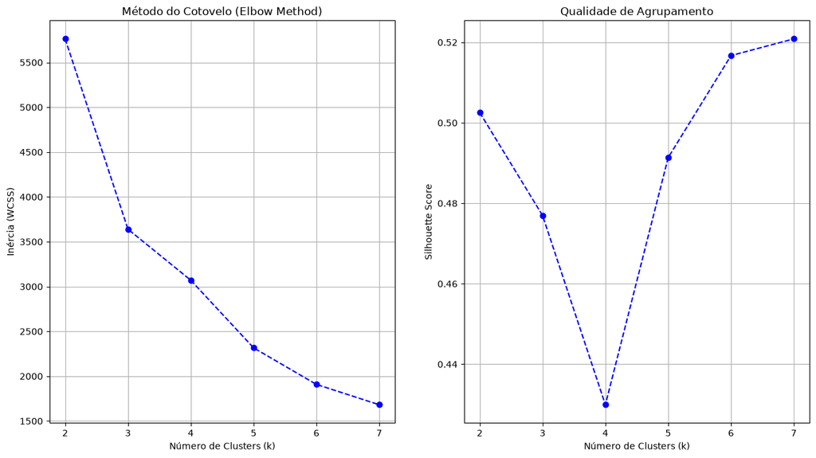

```python
segmentacao1 = segmentacao[['area', 'rooms', 'bathroom']].copy()


robust = RobustScaler()
x = robust.fit_transform(segmentacao1)


resultados = []

for k in range(2, 8):
    model = KMeans(
        n_clusters=k,
        random_state=42,
        #n_init=10
        )

    labels = model.fit_predict(x)

    resultados.append({
        'k': k,
        'silhouette': silhouette_score(x, labels),
        'inertia': model.inertia_})

pd.DataFrame(resultados)

plt.figure(figsize=(15, 8))

ks = [r['k'] for r in resultados]
inercias = [r['inertia'] for r in resultados]
plt.subplot(1,2,1)
plt.plot(ks, inercias, marker='o', color='b', linestyle='--')
plt.title('Método do Cotovelo (Elbow Method)')
plt.xlabel('Número de Clusters (k)')
plt.ylabel('Inércia (WCSS)')
plt.xticks(ks)
plt.grid(True)


ks = [r['k'] for r in resultados]
inercias = [r['silhouette'] for r in resultados]
plt.subplot(1,2,2)
plt.plot(ks, inercias, marker='o', color='b', linestyle='--')
plt.title('Qualidade de Agrupamento')
plt.xlabel('Número de Clusters (k)')
plt.ylabel('Silhouette Score')
plt.xticks(ks)
plt.grid(True)

plt.show()
```

```python
model = KMeans(n_clusters=3, random_state=42, n_init=10)
clusters = model.fit_predict(x)

segmentacao1['cluster'] = clusters

print(segmentacao1['cluster'].value_counts())

segmentacao1.groupby('cluster').agg({
    'area': ['min', 'max', 'mean', 'std'],
    'rooms': ['min', 'max', 'mean', 'std'],
    'bathroom': ['min', 'max', 'mean', 'std']}).T
```

```
cluster
0    2687
2    2058
1     957
Name: count, dtype: int64
```

|  | cluster | 0 | 1 | 2 |
| --- | --- | --- | --- | --- |
| area | min | 11.000000 | 100.000000 | 10.000000 |
|  | max | 440.000000 | 620.000000 | 380.000000 |
|  | mean | 63.749907 | 327.345873 | 153.172012 |
|  | std | 31.379596 | 103.072701 | 59.978116 |
| rooms | min | 1.000000 | 2.000000 | 2.000000 |
|  | max | 2.000000 | 10.000000 | 5.000000 |
|  | mean | 1.539635 | 4.032393 | 3.040816 |
|  | std | 0.498519 | 0.816921 | 0.383528 |
| bathroom | min | 1.000000 | 1.000000 | 1.000000 |
|  | max | 4.000000 | 9.000000 | 6.000000 |
|  | mean | 1.331597 | 4.411703 | 2.648202 |
|  | std | 0.542857 | 1.110896 | 0.947657 |

O método do cotovelo nos dá k=3 e o silhouette score não difere muito deste k em relação ao melhor. Em termos de negócio a clusterização em 2 grupos não é significante ao considerarmos a complexidade de variáveis de construção e economicas. Para este experimento tivemos uma separação que não traz muitos conhecimentos relevantes. Para nossos objetivos, além de ser desejável a inclusão de variáveis economicas, possivelmente será necessário para possuírmos clusters significativos.

#### Experimento 2

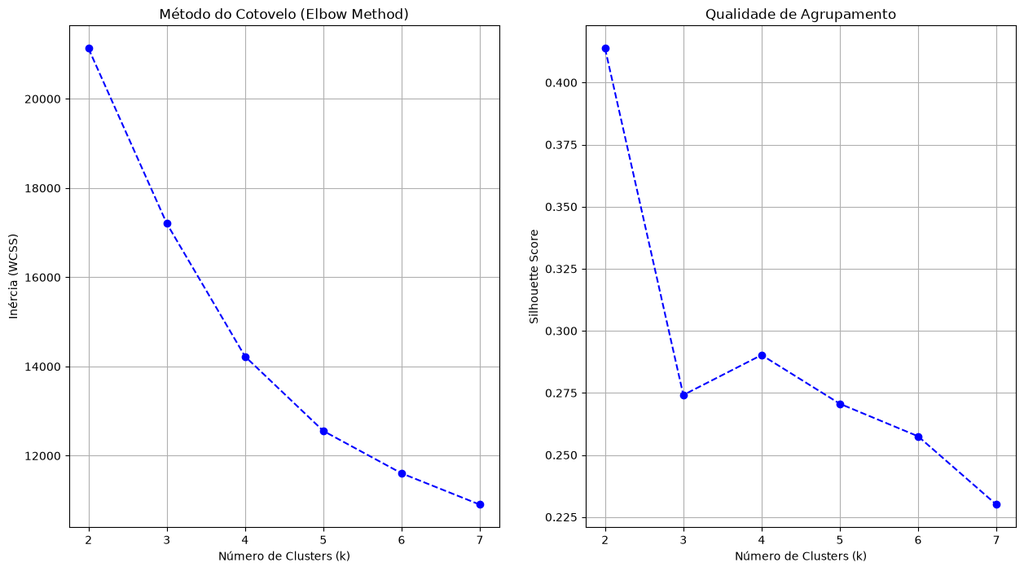

```python
segmentacao2 = segmentacao.drop(columns=['hoa', 'rent amount', 'property tax', 'fire insurance', 'apartamento', 'prop_hoa_total', 'city', 'floor', 'animal', 'furniture']).copy()

robust = RobustScaler()
x = robust.fit_transform(segmentacao2)


resultados = []

for k in range(2, 8):
    model = KMeans(
        n_clusters=k,
        random_state=42,
        #n_init=10
    )

    labels = model.fit_predict(x)

    resultados.append({
        'k': k,
        'silhouette': silhouette_score(x, labels),
        'inertia': model.inertia_})

pd.DataFrame(resultados)


plt.figure(figsize=(15, 8))

ks = [r['k'] for r in resultados]
inercias = [r['inertia'] for r in resultados]
plt.subplot(1,2,1)
plt.plot(ks, inercias, marker='o', color='b', linestyle='--')
plt.title('Método do Cotovelo (Elbow Method)')
plt.xlabel('Número de Clusters (k)')
plt.ylabel('Inércia (WCSS)')
plt.xticks(ks)
plt.grid(True)


ks = [r['k'] for r in resultados]
inercias = [r['silhouette'] for r in resultados]
plt.subplot(1,2,2)
plt.plot(ks, inercias, marker='o', color='b', linestyle='--')
plt.title('Qualidade de Agrupamento')
plt.xlabel('Número de Clusters (k)')
plt.ylabel('Silhouette Score')
plt.xticks(ks)
plt.grid(True)

plt.show()
```

```python
model = KMeans(n_clusters=2, random_state=42, n_init=10)
clusters = model.fit_predict(x)

segmentacao2['cluster'] = clusters

print(segmentacao2['cluster'].value_counts())

segmentacao2.groupby('cluster').agg({
    'area': ['min', 'max', 'mean', 'std'],
    'rooms': ['min', 'max', 'mean', 'std'],
    'bathroom': ['min', 'max', 'mean', 'std'],
    'parking spaces': ['min', 'max', 'mean', 'std'],
    'condominio': 'mean',
    'total': ['min', 'max', 'mean', 'std'],
    'valor_m2': ['min', 'max', 'mean', 'std']}).T
```

```
cluster
0    3914
1    1788
Name: count, dtype: int64
```

|  | cluster | 0 | 1 |
| --- | --- | --- | --- |
| area | min | 10 | 70 |
|  | max | 500 | 620 |
|  | mean | 84.646398 | 262.017897 |
|  | std | 51.143871 | 108.202254 |
| rooms | min | 1 | 1 |
|  | max | 6 | 10 |
|  | mean | 2.006387 | 3.579978 |
|  | std | 0.82586 | 0.828819 |
| bathroom | min | 1 | 1 |
|  | max | 5 | 9 |
|  | mean | 1.638222 | 3.824385 |
|  | std | 0.787346 | 1.1971 |
| parking spaces | min | 0 | 0 |
|  | max | 4 | 8 |
|  | mean | 0.951967 | 3.481544 |
|  | std | 0.715455 | 1.4587 |
| condominio | mean | 0.820644 | 0.642058 |
| total | min | 660 | 1611 |
|  | max | 22025 | 28491 |
|  | mean | 3837.796117 | 10158.82047 |
|  | std | 2637.945596 | 4901.171393 |
| valor_m2 | min | 4.846 | 6.966667 |
|  | max | 310.766667 | 207.6625 |
|  | mean | 51.546052 | 42.116706 |
|  | std | 33.1493 | 20.956814 |

A qualidade de separação (silhouette) não foi tão interessante para esta configuração e optamos pelo k=2 para avaliação. Porém, conforme citado anteriormente, seria pouco significativo em termos de negócio, assim como o resultado não se mostrou convincente. Vamos variar as features para o próximo experimentos.

#### Experimento 3

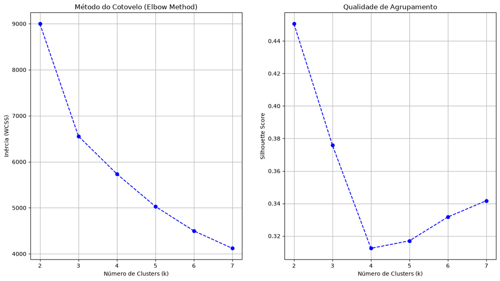

```python
segmentacao3= segmentacao.drop(columns=['hoa', 'rent amount', 'property tax', 'fire insurance', 'apartamento', 'prop_hoa_total', 'city', 'floor', 'animal', 'furniture', 'parking spaces', 'valor_m2']).copy()

robust = RobustScaler()
x = robust.fit_transform(segmentacao3)


resultados = []

for k in range(2, 8):
    model = KMeans(
        n_clusters=k,
        random_state=42
        #n_init=10
    )

    labels = model.fit_predict(x)

    resultados.append({
        'k': k,
        'silhouette': silhouette_score(x, labels),
        'inertia': model.inertia_})

pd.DataFrame(resultados)

plt.figure(figsize=(15, 8))

ks = [r['k'] for r in resultados]
inercias = [r['inertia'] for r in resultados]
plt.subplot(1,2,1)
plt.plot(ks, inercias, marker='o', color='b', linestyle='--')
plt.title('Método do Cotovelo (Elbow Method)')
plt.xlabel('Número de Clusters (k)')
plt.ylabel('Inércia (WCSS)')
plt.xticks(ks)
plt.grid(True)


ks = [r['k'] for r in resultados]
inercias = [r['silhouette'] for r in resultados]
plt.subplot(1,2,2)
plt.plot(ks, inercias, marker='o', color='b', linestyle='--')
plt.title('Qualidade de Agrupamento')
plt.xlabel('Número de Clusters (k)')
plt.ylabel('Silhouette Score')
plt.xticks(ks)
plt.grid(True)

plt.show()
```

```python
model = KMeans(n_clusters=3, random_state=42, n_init=10)
clusters = model.fit_predict(x)

segmentacao3['cluster'] = clusters

print(segmentacao3['cluster'].value_counts())

segmentacao3.groupby('cluster').agg({
    'area': ['min', 'max', 'mean', 'std'],
    'rooms': ['min', 'max', 'mean', 'std'],
    'bathroom': ['min', 'max', 'mean', 'std'],
    'total': ['min', 'max', 'mean', 'std'],
    'condominio': ['min', 'max', 'mean', 'std']}).T
```

```
cluster
1    2607
0    1974
2    1121
Name: count, dtype: int64
```

|  | cluster | 0 | 1 | 2 |
| --- | --- | --- | --- | --- |
| area | min | 10 | 11 | 80 |
|  | max | 500 | 330 | 620 |
|  | mean | 146.695035 | 62.127733 | 310.661017 |
|  | std | 58.864283 | 29.530637 | 104.000237 |
| rooms | min | 1 | 1 | 2 |
|  | max | 5 | 2 | 10 |
|  | mean | 3.025329 | 1.525892 | 3.839429 |
|  | std | 0.460686 | 0.499425 | 0.864528 |
| bathroom | min | 1 | 1 | 2 |
|  | max | 5 | 4 | 9 |
|  | mean | 2.56383 | 1.294208 | 4.295272 |
|  | std | 0.902061 | 0.499171 | 1.103268 |
| total | min | 1215 | 660 | 2176 |
|  | max | 17520 | 16355 | 28491 |
|  | mean | 5724.150456 | 3039.382432 | 12454.917038 |
|  | std | 2944.019211 | 1888.694471 | 4558.550466 |
| condominio | min | 0 | 0 | 0 |
|  | max | 1 | 1 | 1 |
|  | mean | 0.756839 | 0.817798 | 0.654773 |
|  | std | 0.4291 | 0.386085 | 0.475655 |

Ocorreu uma queda acentuada no cotovelo a partir de k=3 e a diferença da qualidade da separação não é tão grande para o melhor k de silhouette (2). Porém, a separação de área está confusa e não consegue representar bem segmentos de mercado para imóveis. Vamos continuar a variar as features para o próximo experimentos.

#### Experimento 4

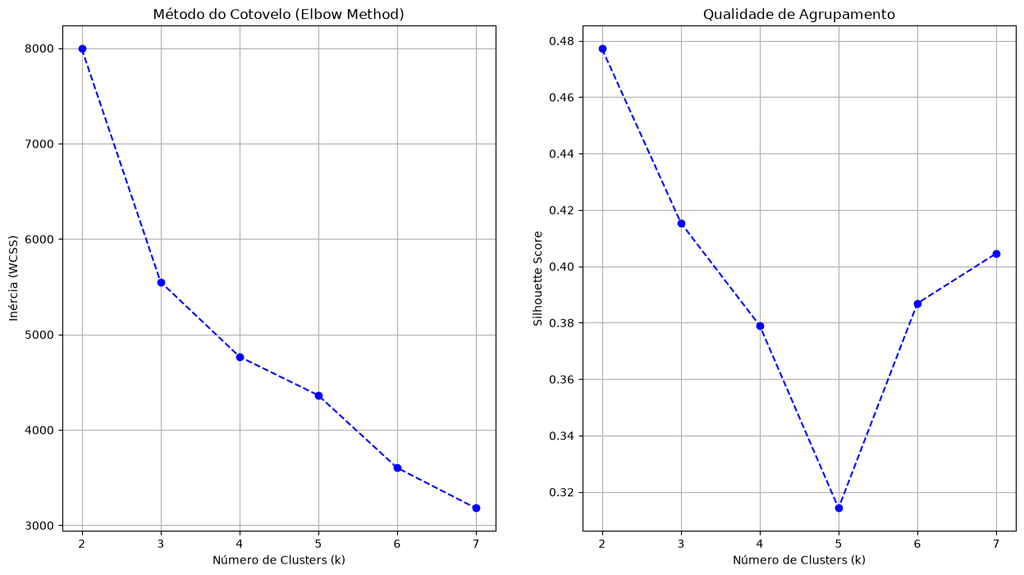

```python
segmentacao4 = segmentacao.drop(columns=['hoa', 'rent amount', 'property tax', 'fire insurance', 'apartamento', 'prop_hoa_total', 'city', 'floor', 'animal', 'furniture', 'parking spaces', 'valor_m2', 'condominio']).copy()

robust = RobustScaler()
x = robust.fit_transform(segmentacao4)


resultados = []

for k in range(2, 8):
    model = KMeans(
        n_clusters=k,
        random_state=42
        #n_init=10
    )

    labels = model.fit_predict(x)

    resultados.append({
        'k': k,
        'silhouette': silhouette_score(x, labels),
        'inertia': model.inertia_})

pd.DataFrame(resultados)


plt.figure(figsize=(15, 8))

ks = [r['k'] for r in resultados]
inercias = [r['inertia'] for r in resultados]
plt.subplot(1,2,1)
plt.plot(ks, inercias, marker='o', color='b', linestyle='--')
plt.title('Método do Cotovelo (Elbow Method)')
plt.xlabel('Número de Clusters (k)')
plt.ylabel('Inércia (WCSS)')
plt.xticks(ks)
plt.grid(True)


ks = [r['k'] for r in resultados]
inercias = [r['silhouette'] for r in resultados]
plt.subplot(1,2,2)
plt.plot(ks, inercias, marker='o', color='b', linestyle='--')
plt.title('Qualidade de Agrupamento')
plt.xlabel('Número de Clusters (k)')
plt.ylabel('Silhouette Score')
plt.xticks(ks)
plt.grid(True)

plt.show()
```

```python
model = KMeans(n_clusters=3, random_state=42, n_init=10)
clusters = model.fit_predict(x)

segmentacao4['cluster'] = clusters

print(segmentacao4['cluster'].value_counts())

segmentacao4.groupby('cluster').agg({
    'area': ['min', 'max', 'mean', 'std'],
    'rooms': ['min', 'max', 'mean', 'std'],
    'bathroom': ['min', 'max', 'mean', 'std'],
    'total': ['min', 'max', 'mean', 'std']}).T
```

```
cluster
2    2596
0    1956
1    1150
Name: count, dtype: int64
```

|  | cluster | 0 | 1 | 2 |
| --- | --- | --- | --- | --- |
| area | min | 10 | 80 | 11 |
|  | max | 500 | 620 | 330 |
|  | mean | 145.81953 | 307.67913 | 61.918336 |
|  | std | 58.975435 | 104.306674 | 29.394013 |
| rooms | min | 1 | 2 | 1 |
|  | max | 5 | 10 | 2 |
|  | mean | 3.011247 | 3.833043 | 1.523883 |
|  | std | 0.458928 | 0.85906 | 0.499526 |
| bathroom | min | 1 | 2 | 1 |
|  | max | 5 | 9 | 4 |
|  | mean | 2.547546 | 4.27913 | 1.288906 |
|  | std | 0.893448 | 1.098856 | 0.492456 |
| total | min | 1215 | 2176 | 660 |
|  | max | 17520 | 28491 | 16355 |
|  | mean | 5672.432004 | 12380.038261 | 3024.955316 |
|  | std | 2912.555485 | 4538.004247 | 1876.306171 |

Ocorreu uma queda acentuada no cotovelo em k=3 e k=4, porém a diferença da qualidade da separação em k=3 não é tão grande para o melhor k de silhouette (2), já o caso de k=4 temos uma piora mais significativa. Porém, o resultado dos clustes de área, assim como total, está confusa e não consegue representar bem segmentos de mercado para imóveis. Vamos manter as features para o próximo experimentos, só que experimentar a transformação logarítmica ao invés de robust scaler.

#### Experimento 5

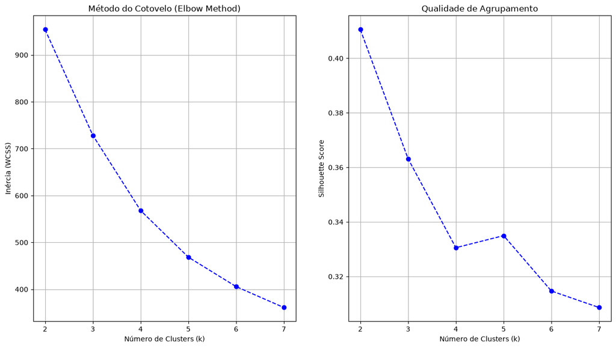

```python
segmentacao5 = segmentacao[['area', 'total', 'rooms', 'valor_m2']].copy()


#robust = RobustScaler()
#x = robust.fit_transform(segmentacao0)
x = np.log10(segmentacao5)


resultados = []

for k in range(2, 8):
    model = KMeans(
        n_clusters=k,
        random_state=42,
        n_init=10)

    labels = model.fit_predict(x)

    resultados.append({
        'k': k,
        'silhouette': silhouette_score(x, labels),
        'inertia': model.inertia_})

pd.DataFrame(resultados)

plt.figure(figsize=(15, 8))

ks = [r['k'] for r in resultados]
inercias = [r['inertia'] for r in resultados]
plt.subplot(1,2,1)
plt.plot(ks, inercias, marker='o', color='b', linestyle='--')
plt.title('Método do Cotovelo (Elbow Method)')
plt.xlabel('Número de Clusters (k)')
plt.ylabel('Inércia (WCSS)')
plt.xticks(ks)
plt.grid(True)


ks = [r['k'] for r in resultados]
inercias = [r['silhouette'] for r in resultados]
plt.subplot(1,2,2)
plt.plot(ks, inercias, marker='o', color='b', linestyle='--')
plt.title('Qualidade de Agrupamento')
plt.xlabel('Número de Clusters (k)')
plt.ylabel('Silhouette Score')
plt.xticks(ks)
plt.grid(True)

plt.show()
```

```python
model = KMeans(n_clusters=3, random_state=42, n_init=10)
clusters = model.fit_predict(x)

segmentacao5['cluster'] = clusters

print(segmentacao5['cluster'].value_counts())

segmentacao5.groupby('cluster').agg({
    'area': ['min', 'max', 'mean', 'std'],
    'valor_m2': ['min', 'max', 'mean', 'std'],
    'rooms': ['min', 'max', 'mean', 'std'],
    'total': ['min', 'max', 'mean', 'std']}).T
```

```
cluster
1    2439
2    2010
0    1253
Name: count, dtype: int64
```

|  | cluster | 0 | 1 | 2 |
| --- | --- | --- | --- | --- |
| area | min | 10 | 79 | 20 |
|  | max | 120 | 620 | 500 |
|  | mean | 50.967279 | 233.526445 | 82.766667 |
|  | std | 20.515086 | 107.56896 | 39.797231 |
| valor_m2 | min | 40.61 | 7.84 | 4.846 |
|  | max | 310.766667 | 207.6625 | 57.197183 |
|  | mean | 83.584095 | 45.475453 | 30.552446 |
|  | std | 35.977158 | 21.832308 | 9.958204 |
| rooms | min | 1 | 1 | 1 |
|  | max | 4 | 10 | 6 |
|  | mean | 1.347965 | 3.378844 | 2.151244 |
|  | std | 0.531956 | 0.831582 | 0.741308 |
| total | min | 870 | 2960 | 660 |
|  | max | 16355 | 28491 | 4833 |
|  | mean | 4110.093376 | 9549.946289 | 2359.621393 |
|  | std | 2189.421222 | 4520.268479 | 923.487469 |

Ocorreu uma queda acentuada no cotovelo em k=4, a diferença da qualidade da separação é razoável para o melhor k de silhouette (2), por isso optamos pelo silhouette score intermediário de k=3. Porém, o resultado dos clustes de área está confusa e não consegue representar bem segmentos de mercado para imóveis. Só que é possível observar que as mudanças proporcionaram melhor separação em total se compararmos com o experimento anterior. Vamos continuar a variar as features para os próximos experimentos e a aplicação da transformação logarítmica. Buscaremos outras alterações nos próximos experimentos de modo a encontrar algum caminho mais relevante.

#### Experimento 6

Os 5 experimentos anteriores não trouxeram resultado minimamente interessante, apesar de considerarmos que a melhoria de log seja válido continuar nos testes. Vamos mudar a abordagem procurando maior controle. Inicialmente, deixaremosde lado os outliers (whis 1.5) e verificar se sua suavização de ruídos tornará mais facilitada a missão de encontrar centróides para os clusters.

```python
segmentacao6 = segmentacao.copy()
```

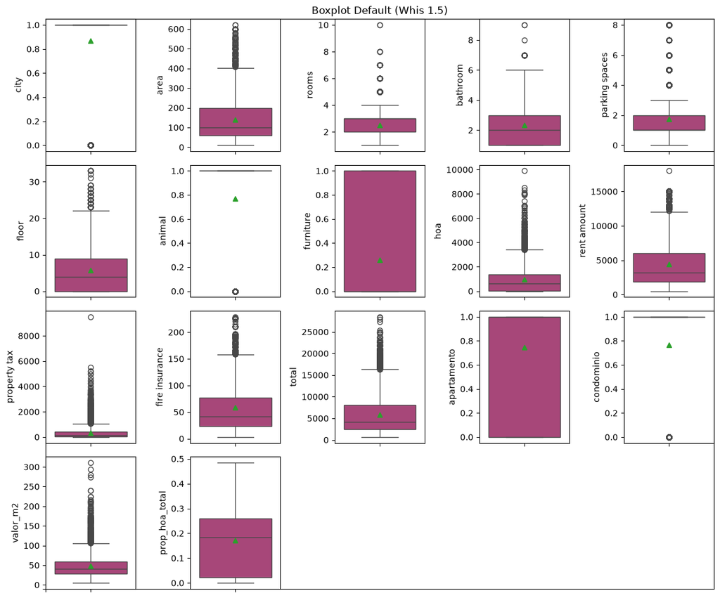

```python
plt.figure(figsize=(12,10))
plt.title('Boxplot Default (Whis 1.5)')
plt.xticks([0], [''])
plt.yticks([0], [''])
for i in range(17):
    plt.subplot(4,5,i+1)
    sns.boxplot(data=segmentacao, y=segmentacao.columns[i], showmeans=True, palette='magma')
plt.tight_layout()
```

```python
col_outliers = ['area', 'rooms', 'bathroom', 'parking spaces', 'hoa', 'rent amount',
                'property tax','fire insurance', 'total', 'valor_m2', 'prop_hoa_total']
```

```python
mascara_out_index = []

for col in col_outliers:
    out_default = box_out(segmentacao6[col])
    indices_outliers = segmentacao6[segmentacao6[col] > out_default[1]].index
    mascara_out_index.extend(indices_outliers)

indices_finais = list(set(mascara_out_index))
```

```python
print(segmentacao6.shape)
segmentacao6_sem_outliers = segmentacao6.drop(index=indices_finais)
print(segmentacao6_sem_outliers.shape)
```

```
(5702, 17)
(4293, 17)
```

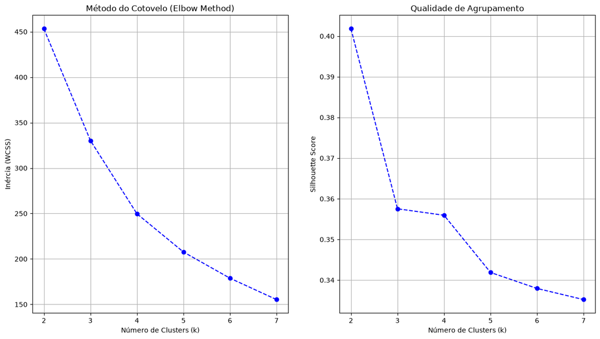

```python
x = segmentacao6_sem_outliers[['area', 'total', 'valor_m2']]


#robust = RobustScaler()
#x = robust.fit_transform(segmentacao0)
x = np.log10(x)


resultados = []

for k in range(2, 8):
    model = KMeans(
        n_clusters=k,
        random_state=42,
        n_init=10)

    labels = model.fit_predict(x)

    resultados.append({
        'k': k,
        'silhouette': silhouette_score(x, labels),
        'inertia': model.inertia_})

pd.DataFrame(resultados)

plt.figure(figsize=(15, 8))

ks = [r['k'] for r in resultados]
inercias = [r['inertia'] for r in resultados]
plt.subplot(1,2,1)
plt.plot(ks, inercias, marker='o', color='b', linestyle='--')
plt.title('Método do Cotovelo (Elbow Method)')
plt.xlabel('Número de Clusters (k)')
plt.ylabel('Inércia (WCSS)')
plt.xticks(ks)
plt.grid(True)


ks = [r['k'] for r in resultados]
inercias = [r['silhouette'] for r in resultados]
plt.subplot(1,2,2)
plt.plot(ks, inercias, marker='o', color='b', linestyle='--')
plt.title('Qualidade de Agrupamento')
plt.xlabel('Número de Clusters (k)')
plt.ylabel('Silhouette Score')
plt.xticks(ks)
plt.grid(True)

plt.show()
```

```python
model = KMeans(n_clusters=4, random_state=42, n_init=10)
clusters = model.fit_predict(x)

segmentacao6_sem_outliers['cluster'] = clusters

print(segmentacao6_sem_outliers['cluster'].value_counts())

segmentacao6_sem_outliers.groupby('cluster').agg({
    'area': ['min', 'max', 'mean', 'std'],
    'valor_m2': ['min', 'max', 'mean', 'std'],
    'total': ['min', 'max', 'mean', 'std']}).T
```

```
cluster
2    1170
1    1146
3    1059
0     918
Name: count, dtype: int64
```

|  | cluster | 0 | 1 | 2 | 3 |
| --- | --- | --- | --- | --- | --- |
| area | min | 80 | 16 | 12 | 77 |
|  | max | 402 | 120 | 98 | 402 |
|  | mean | 149.239651 | 57.806283 | 58.335897 | 168.426818 |
|  | std | 61.120662 | 17.451742 | 17.939424 | 63.342388 |
| valor_m2 | min | 5.771318 | 7.5 | 35.9 | 20.015 |
|  | max | 44.97 | 67.4 | 106.096774 | 105.369231 |
|  | mean | 26.589416 | 30.205705 | 63.083607 | 53.722987 |
|  | std | 8.546261 | 9.286985 | 18.174461 | 17.810045 |
| total | min | 1243 | 660 | 1114 | 4648 |
|  | max | 7497 | 2706 | 7465 | 15703 |
|  | mean | 3650.300654 | 1648.311518 | 3499.299145 | 8391.34372 |
|  | std | 1069.631578 | 456.022103 | 1050.010247 | 2454.844744 |

#### Experimento 7

```python
segmentacao7 = segmentacao.copy()
```

Anteriormente retiramos outliers de todas as features. Agora iremos nos ater as features que de fato são relevantes para a clusterização.

```python
col_outliers = ['area', 'total', 'valor_m2']
```

```python
mascara_out_index = []

for col in col_outliers:
    out_default = box_out(segmentacao7[col])
    indices_outliers = segmentacao7[segmentacao7[col] > out_default[1]].index
    mascara_out_index.extend(indices_outliers)

indices_finais = list(set(mascara_out_index))
```

```python
print(segmentacao7.shape)
segmentacao7_sem_outliers = segmentacao7.drop(index=indices_finais)
print(segmentacao7_sem_outliers.shape)
```

```
(5702, 17)
(5054, 17)
```

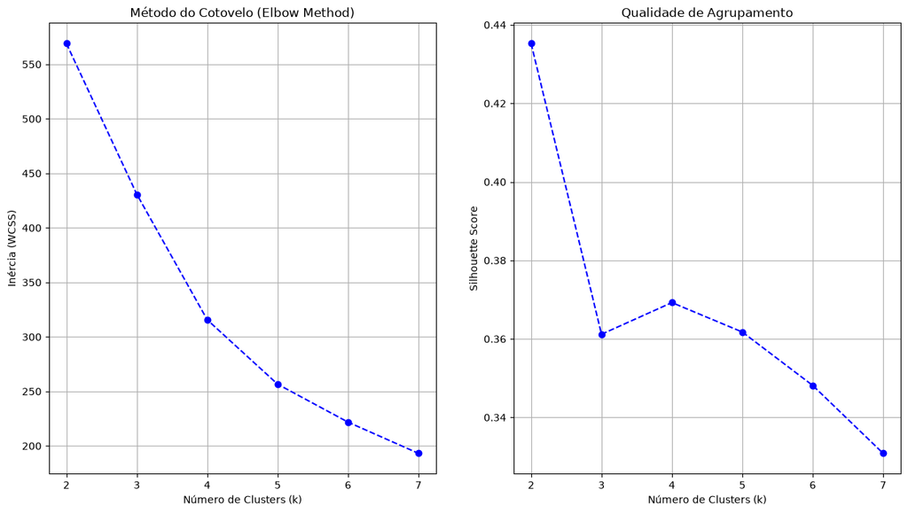

```python
x = segmentacao7_sem_outliers[['area', 'total', 'valor_m2']]


#robust = RobustScaler()
#x = robust.fit_transform(segmentacao0)
x = np.log10(x)


resultados = []

for k in range(2, 8):
    model = KMeans(
        n_clusters=k,
        random_state=42,
        n_init=10)

    labels = model.fit_predict(x)

    resultados.append({
        'k': k,
        'silhouette': silhouette_score(x, labels),
        'inertia': model.inertia_})

pd.DataFrame(resultados)

plt.figure(figsize=(15, 8))

ks = [r['k'] for r in resultados]
inercias = [r['inertia'] for r in resultados]
plt.subplot(1,2,1)
plt.plot(ks, inercias, marker='o', color='b', linestyle='--')
plt.title('Método do Cotovelo (Elbow Method)')
plt.xlabel('Número de Clusters (k)')
plt.ylabel('Inércia (WCSS)')
plt.xticks(ks)
plt.grid(True)


ks = [r['k'] for r in resultados]
inercias = [r['silhouette'] for r in resultados]
plt.subplot(1,2,2)
plt.plot(ks, inercias, marker='o', color='b', linestyle='--')
plt.title('Qualidade de Agrupamento')
plt.xlabel('Número de Clusters (k)')
plt.ylabel('Silhouette Score')
plt.xticks(ks)
plt.grid(True)

plt.show()
```

```python
model = KMeans(n_clusters=4, random_state=42, n_init=10)
clusters = model.fit_predict(x)

segmentacao7_sem_outliers['cluster'] = clusters

print(segmentacao7_sem_outliers['cluster'].value_counts())

segmentacao7_sem_outliers.groupby('cluster').agg({
    'area': ['min', 'max', 'mean', 'std'],
    'valor_m2': ['min', 'max', 'mean', 'std'],
    'total': ['min', 'max', 'mean', 'std']}).T
```

```
cluster
2    1410
1    1345
0    1316
3     983
Name: count, dtype: int64
```

|  | cluster | 0 | 1 | 2 | 3 |
| --- | --- | --- | --- | --- | --- |
| area | min | 12 | 96 | 15 | 95 |
|  | max | 120 | 400 | 120 | 402 |
|  | mean | 59.340426 | 215.286989 | 68.39078 | 185.747711 |
|  | std | 19.598663 | 76.843084 | 22.952935 | 73.184457 |
| valor_m2 | min | 7.5 | 20.8875 | 32.430108 | 5.771318 |
|  | max | 92.833333 | 105.369231 | 106.096774 | 43.130081 |
|  | mean | 31.299534 | 51.025459 | 60.874746 | 24.351485 |
|  | std | 10.910063 | 17.250882 | 18.728447 | 8.138211 |
| total | min | 660 | 5483 | 1570 | 1243 |
|  | max | 2871 | 16350 | 9021 | 8126 |
|  | mean | 1725.192249 | 10125.262454 | 3912.314184 | 4179.610376 |
|  | std | 486.585034 | 2709.350523 | 1247.168418 | 1297.749124 |

A solução apresenta agrupamento moderado e comportamento específico por clusters. Temos 2 dimensões: Porte e Posicionamento Economico (o que reflete as features que inserimos no modelo). E cada cluster se posiciona em um local deste quadrante de duas dimensões. Seguiremos com este modelo, visto que foi possível visualizar separações e convergência com interpretações de negócio.

Retornaremos os outliers para a base, traremos seu retorno por proximidade com os centróides existentes dos clusters e observaremos o impacto de suas classificações dentro de algum segmento. O que procuramos aqui é: quando os outlier formam os 4 segmentos, ainda temos as mesmas características vistas antes em um quadrante de duas dimensões?

```python
outliers = segmentacao7.loc[indices_finais].copy()

x_outliers = outliers[['area', 'total', 'valor_m2']]
x_outliers = np.log10(x_outliers)

outliers['cluster'] = model.predict(x_outliers)

print(outliers['cluster'].value_counts())

outliers.groupby('cluster').agg({
    'area': ['min', 'max', 'mean', 'std'],
    'valor_m2': ['min', 'max', 'mean', 'std'],
    'total': ['min', 'max', 'mean', 'std'],}).T
```

```
cluster
1    354
2    243
3     50
0      1
Name: count, dtype: int64
```

|  | cluster | 0 | 1 | 2 | 3 |
| --- | --- | --- | --- | --- | --- |
| area | min | 11 | 75 | 10 | 411 |
|  | max | 11 | 620 | 84 | 600 |
|  | mean | 11.0 | 333.793785 | 40.246914 | 503.32 |
|  | std | NaN | 143.389957 | 16.758763 | 63.612167 |
| valor_m2 | min | 108.727273 | 16.983333 | 106.425 | 4.846 |
|  | max | 108.727273 | 207.6625 | 310.766667 | 19.0 |
|  | mean | 108.727273 | 64.193136 | 139.66252 | 13.889949 |
|  | std | <NA> | 34.667971 | 34.984604 | 3.039965 |
| total | min | 1196 | 8518 | 2187 | 2423 |
|  | max | 1196 | 28491 | 14903 | 9292 |
|  | mean | 1196.0 | 16893.612994 | 5522.794239 | 6955.6 |
|  | std | <NA> | 3870.721944 | 2464.293958 | 1593.787608 |

```python
from sklearn.metrics import pairwise_distances

distancias = model.transform(x_outliers)

outliers['dist_cluster'] = distancias.min(axis=1)

outliers[outliers['cluster'] == 3].sort_values('dist_cluster', ascending=False)[
    [
        'area',
        'total',
        'valor_m2',
        'cluster',
        'dist_cluster'
    ]]
```

|  | area | total | valor_m2 | cluster | dist_cluster |
| --- | --- | --- | --- | --- | --- |
| 1085 | 500 | 2423 | 4.846 | 3 | 0.843757 |
| 2373 | 600 | 5434 | 9.056667 | 3 | 0.686602 |
| 980 | 550 | 4312 | 7.84 | 3 | 0.684920 |
| 6071 | 600 | 9292 | 15.486667 | 3 | 0.675324 |
| 4400 | 600 | 5967 | 9.945 | 3 | 0.673134 |
| 5941 | 600 | 9051 | 15.085 | 3 | 0.672129 |
| 2507 | 600 | 8471 | 14.118333 | 3 | 0.665746 |
| 2161 | 600 | 6483 | 10.805 | 3 | 0.665132 |
| 2164 | 600 | 7903 | 13.171667 | 3 | 0.661680 |
| 500 | 600 | 7869 | 13.115 | 3 | 0.661517 |
| 5618 | 600 | 7854 | 13.09 | 3 | 0.661449 |
| 257 | 600 | 7525 | 12.541667 | 3 | 0.660453 |
| 538 | 580 | 9149 | 15.774138 | 3 | 0.657893 |
| 1666 | 556 | 9165 | 16.483813 | 3 | 0.639257 |
| 577 | 556 | 8697 | 15.642086 | 3 | 0.632154 |
| 3151 | 550 | 5951 | 10.82 | 3 | 0.623064 |
| 3172 | 550 | 8246 | 14.992727 | 3 | 0.621341 |
| 3074 | 500 | 4693 | 9.386 | 3 | 0.605571 |
| 3713 | 530 | 7240 | 13.660377 | 3 | 0.594943 |
| 2996 | 520 | 7751 | 14.905769 | 3 | 0.588900 |
| 96 | 500 | 8829 | 17.658 | 3 | 0.587327 |
| 3943 | 500 | 8773 | 17.546 | 3 | 0.586235 |
| 4264 | 500 | 8746 | 17.492 | 3 | 0.585714 |
| 3446 | 500 | 8165 | 16.33 | 3 | 0.575598 |
| 1208 | 500 | 8104 | 16.208 | 3 | 0.574671 |
| 2383 | 500 | 5667 | 11.334 | 3 | 0.573306 |
| 5077 | 500 | 7264 | 14.528 | 3 | 0.565261 |
| 158 | 500 | 6558 | 13.116 | 3 | 0.563613 |
| 3527 | 480 | 8400 | 17.5 | 3 | 0.561507 |
| 3547 | 470 | 8443 | 17.96383 | 3 | 0.553369 |
| 3812 | 480 | 6766 | 14.095833 | 3 | 0.541867 |
| 2367 | 440 | 4478 | 10.177273 | 3 | 0.538696 |
| 1020 | 472 | 7248 | 15.355932 | 3 | 0.536375 |
| 461 | 462 | 5666 | 12.264069 | 3 | 0.527753 |
| 3784 | 420 | 4203 | 10.007143 | 3 | 0.526619 |
| 4448 | 440 | 8360 | 19.0 | 3 | 0.524310 |
| 769 | 440 | 4827 | 10.970455 | 3 | 0.522308 |
| 2263 | 450 | 7735 | 17.188889 | 3 | 0.520677 |
| 3497 | 438 | 8269 | 18.878995 | 3 | 0.520294 |
| 2684 | 450 | 5460 | 12.133333 | 3 | 0.516476 |
| 411 | 450 | 5491 | 12.202222 | 3 | 0.515836 |
| 3422 | 450 | 7234 | 16.075556 | 3 | 0.512991 |
| 845 | 450 | 6805 | 15.122222 | 3 | 0.508784 |
| 2598 | 450 | 6347 | 14.104444 | 3 | 0.507346 |
| 4619 | 445 | 5870 | 13.191011 | 3 | 0.503761 |
| 5484 | 414 | 4465 | 10.785024 | 3 | 0.502264 |
| 912 | 430 | 6104 | 14.195349 | 3 | 0.483359 |
| 3977 | 420 | 7315 | 17.416667 | 3 | 0.481994 |
| 3217 | 412 | 6462 | 15.684466 | 3 | 0.461640 |
| 2772 | 411 | 6250 | 15.206813 | 3 | 0.459324 |

Por serem valores extremos, quando os observamos sozinhos, existem mudanças nos grupos definidos, porém as características gerais se mantêm. Era esperado ocorrer uma expansão de limite quando observados sozinhos, porém o importante é que não houve mudança de panorâma geral das característica ou no fato de borrar os limites.

Vamos testar a estabilidade da solução, antes de tomá-la como definitiva, visto que KMeans é um modelo cuja a inicialização dos centróides afeta os resultados e este é um processo aleatório. Logo, trabalhar com diferentes sementes é importante para verificar se ocorre instabilidade. A semente que usamos até agora foi 42.

```python
sementes = [42, 123, 999, 77, 33]
scores_silhueta = []

for seed in sementes:
    kmeans = KMeans(n_clusters=4, random_state=seed, n_init=10)

    labelsT = kmeans.fit_predict(x)

    if len(np.unique(labelsT)) > 1:
        score = silhouette_score(x, labelsT)
        scores_silhueta.append(score)
        print(f"Semente {seed} -> Silhueta: {score:.4f}")
```

```
Semente 42 -> Silhueta: 0.3692
Semente 123 -> Silhueta: 0.3693
Semente 999 -> Silhueta: 0.3692
Semente 77 -> Silhueta: 0.3692
Semente 33 -> Silhueta: 0.3692
```

### Modelo Final - Perfil de Cluster relativo a este dataset

Para fins de visualização é importante entender os segmentos de mercado em mais de uma dimensão:

- Os limites compõem um segmento de mercado imobiliário (faixa operacional)
- A essência de um segmento de mercado imobiliário (núcleo)

Para o primeiro caso, é considerado os limites de mínimo e máximo para cada uma das 3 variáveis decisórias. Já para o núcleo, consideramos os 50% dos dados centrais (Percentil 25 até Percentil 75). O núcleo tem a potência de apresentar maior uniformidade e unicidade de cada segmento de mercado.

```python
segmentacao_final = pd.concat([segmentacao7_sem_outliers, outliers], axis=0).drop(columns='dist_cluster')

segmentacao_final['cluster'] = segmentacao_final['cluster'].map({0:'PequenoPorte_BaixoPosicionamento', 1:'GrandePorte_AltoPosicionamento', 2:'PequenoPorte_AltoPosicionamento', 3:'GrandePorte_BaixoPosicionamento'})

regras_negocio = (segmentacao_final.groupby('cluster')[['area', 'total', 'valor_m2']].agg(
        area_min=('area', 'min'),
        area_p25=('area', lambda x: x.quantile(0.25)),
        area_p75=('area', lambda x: x.quantile(0.75)),
        area_max=('area', 'max'),

        total_min=('total', 'min'),
        total_p25=('total', lambda x: x.quantile(0.25)),
        total_p75=('total', lambda x: x.quantile(0.75)),
        total_max=('total', 'max'),

        valor_m2_min=('valor_m2', 'min'),
        valor_m2_p25=('valor_m2', lambda x: x.quantile(0.25)),
        valor_m2_p75=('valor_m2', lambda x: x.quantile(0.75)),
        valor_m2_max=('valor_m2', 'max')
    ))

regras_negocio = regras_negocio.round()
regras_negocio
```

| cluster | area_min | area_p25 | area_p75 | area_max | total_min | total_p25 | total_p75 | total_max | valor_m2_min | valor_m2_p25 | valor_m2_p75 | valor_m2_max |
| --- | --- | --- | --- | --- | --- | --- | --- | --- | --- | --- | --- | --- |
| GrandePorte_AltoPosicionamento | 75 | 160.0 | 300.0 | 620 | 5483 | 8414.0 | 14040.0 | 28491 | 17.0 | 38.0 | 65.0 | 208.0 |
| GrandePorte_BaixoPosicionamento | 95 | 130.0 | 250.0 | 600 | 1243 | 3218.0 | 5229.0 | 9292 | 5.0 | 17.0 | 30.0 | 43.0 |
| PequenoPorte_AltoPosicionamento | 10 | 45.0 | 84.0 | 120 | 1570 | 3000.0 | 4872.0 | 14903 | 32.0 | 47.0 | 87.0 | 311.0 |
| PequenoPorte_BaixoPosicionamento | 11 | 46.0 | 72.0 | 120 | 660 | 1326.0 | 2105.0 | 2871 | 8.0 | 24.0 | 37.0 | 109.0 |

## EDA

### Visualizações Iniciais (Univariada e Multivariada)

```python
segmentacao_final.describe()
```

|  | city | area | rooms | bathroom | parking spaces | floor | animal | furniture | hoa | rent amount | property tax | fire insurance | total | apartamento | condominio | valor_m2 | prop_hoa_total |
| --- | --- | --- | --- | --- | --- | --- | --- | --- | --- | --- | --- | --- | --- | --- | --- | --- | --- |
| count | 5702.000000 | 5702.000000 | 5702.000000 | 5702.000000 | 5702.000000 | 5702.0 | 5702.0 | 5702.0 | 5702.0 | 5702.0 | 5702.0 | 5702.0 | 5702.0 | 5702.000000 | 5702.000000 | 5702.0 | 5702.0 |
| mean | 0.866889 | 140.265521 | 2.499825 | 2.323746 | 1.745177 | 5.6745 | 0.77201 | 0.261136 | 994.121186 | 4414.826552 | 352.670291 | 58.288145 | 5819.906173 | 0.746931 | 0.764644 | 48.589253 | 0.171122 |
| std | 0.339725 | 110.626022 | 1.102969 | 1.379706 | 1.547853 | 5.886577 | 0.419573 | 0.439293 | 1132.151111 | 3456.30103 | 548.268036 | 47.311423 | 4572.485747 | 0.434808 | 0.424258 | 30.183489 | 0.123463 |
| min | 0.000000 | 10.000000 | 1.000000 | 1.000000 | 0.000000 | 0.0 | 0.0 | 0.0 | -2.0 | 500.0 | 0.0 | 3.0 | 660.0 | 0.000000 | 0.000000 | 4.846 | -0.000146 |
| 25% | 1.000000 | 60.000000 | 2.000000 | 1.000000 | 1.000000 | 0.0 | 1.0 | 0.0 | 50.0 | 1891.75 | 33.0 | 23.0 | 2476.0 | 0.000000 | 1.000000 | 28.580375 | 0.022817 |
| 50% | 1.000000 | 100.000000 | 3.000000 | 2.000000 | 1.000000 | 4.0 | 1.0 | 0.0 | 650.0 | 3200.0 | 150.0 | 42.0 | 4181.5 | 1.000000 | 1.000000 | 41.012481 | 0.183733 |
| 75% | 1.000000 | 197.000000 | 3.000000 | 3.000000 | 2.000000 | 9.0 | 1.0 | 1.0 | 1400.0 | 6000.0 | 450.0 | 77.0 | 8028.5 | 1.000000 | 1.000000 | 59.678046 | 0.259709 |
| max | 1.000000 | 620.000000 | 10.000000 | 9.000000 | 8.000000 | 33.0 | 1.0 | 1.0 | 9900.0 | 18000.0 | 9500.0 | 229.0 | 28491.0 | 1.000000 | 1.000000 | 310.766667 | 0.484429 |

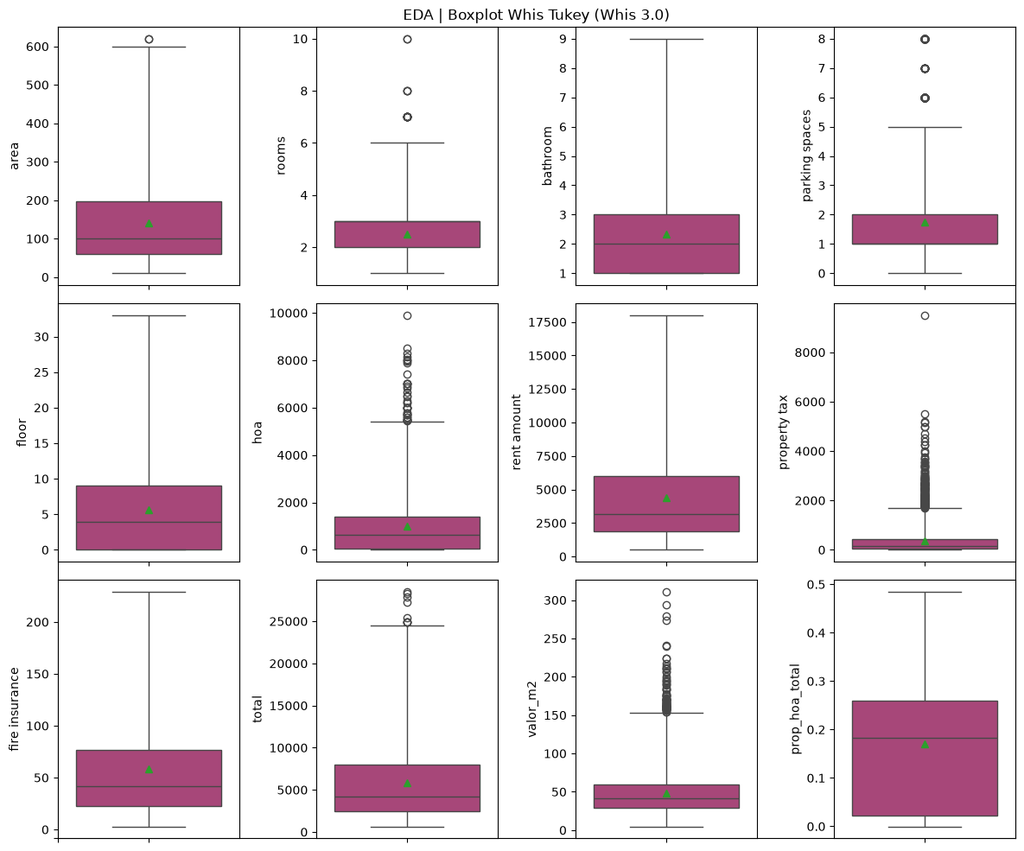

```python
plt.figure(figsize=(12,10))
plt.title('EDA | Boxplot Whis Tukey (Whis 3.0)')
plt.xticks([0], [''])
plt.yticks([0], [''])
for i in range(12):
    plt.subplot(3,4,i+1)
    sns.boxplot(data=segmentacao_final.drop(columns=['city', 'animal', 'furniture', 'condominio', 'apartamento']), y=segmentacao_final.drop(columns=['city', 'animal', 'furniture', 'condominio', 'apartamento']).columns[i], showmeans=True, palette='magma', whis=3.0)
plt.tight_layout()
```

‘Valor_m2’, ‘hoa’ e ‘property tax’ são as variáveis com grande quantidade de outliers. O iptu pode nos apontar que estamos tratando com muitas regiões e bairros, com alto contraste entre elas. Infelizmente não possuiremos uma varíavel que traga esta informação para aprofundarmos as relações de localização, que no mercado imobiliário impactam profundamente a precificação e costuma ser uma das mais importantes features.

```python
segmentacao_final[['area', 'total']].corr()
```

|  | area | total |
| --- | --- | --- |
| area | 1.000000 | 0.689342 |
| total | 0.689342 | 1.000000 |

Outro ponto relevante é, mesmo diante de um limite conservador (whis 3.0), possuirmos uma grande diferença de quantidade de outliers em ‘total’/‘area’ com relação a feature que é filha de ambas (‘valor_m2’) Embora exista uma correlação linear, confirmada pela verificação, a relação preço-área não é estritamente proporcional, indicando a presença de fatores externos que distorcem o valor do metro quadrado em casos específicos. Ocorre na relação o impacto de heterocedasticidade (a variância do preço muda conforme o tamanho do imóvel) e influência pesada de outras variáveis, não existe uma constância.

```python
quali_quantidisc = ['city', 'animal', 'furniture', 'rooms', 'bathroom', 'parking spaces', 'apartamento', 'condominio', 'cluster']
quanticont = ['area', 'total', 'valor_m2', 'prop_hoa_total', 'floor']
```

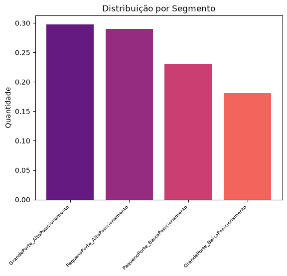

```python
plt.bar(segmentacao_final['cluster'].value_counts(normalize=True).index, segmentacao_final['cluster'].value_counts(normalize=True).values, color=cores)
plt.ylabel('Quantidade')
plt.xticks(rotation=45, fontsize=7, ha='right')
plt.title('Distribuição por Segmento')
```

O gráfico de frequência dos segmentos é relativamente uniforme entre os segmentos.

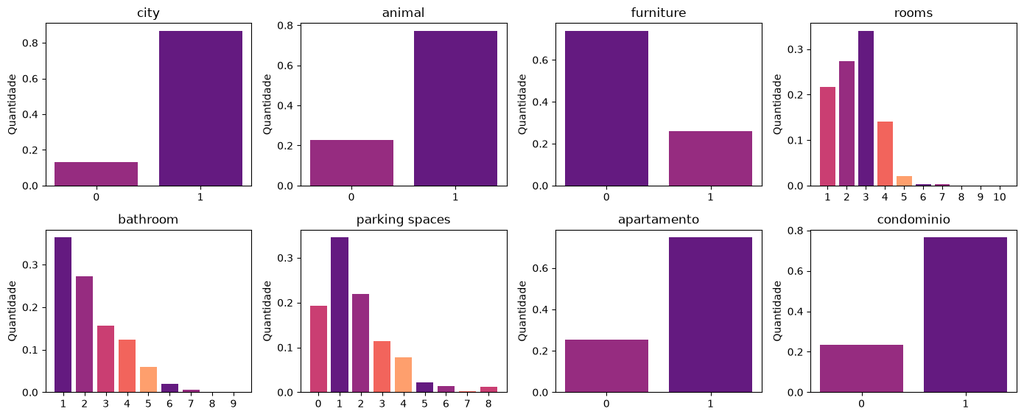

```python
plt.figure(figsize=(14,6))
for i in range(8):
    plt.subplot(2,4,i+1)
    valores = []
    categorias = []
    valores = segmentacao_final[quali_quantidisc].iloc[:,i].value_counts(normalize=True).values
    categorias = segmentacao_final[quali_quantidisc].iloc[:,i].value_counts(normalize=True).index
    plt.bar(categorias, valores, color=cores)
    plt.xticks(range(segmentacao_final[quali_quantidisc].iloc[:,i].min(), segmentacao_final[quali_quantidisc].iloc[:,i].max()+1, 1))
    plt.ylabel('Quantidade')
    plt.title(quali_quantidisc[i])
plt.tight_layout(rect=[0, 0, 1, 0.96])
```

Os gráficos de frequência nos mostram que: - concentração de imóveis de nossa database noa cidade 1 (próximo de 80%) - concentração de imóveis que aceitam animais (próximo de 80%) - concentração de imóveis não mobiliados ((próximo de 70%)) - concentração de imóveis que são apartamentos (próximo de 70%) - concentração de imóveis que possuem condomínios (próximo de 80%) - a moda de banheiros e estacionamentos é 1, enquanto que para quartos é 3. A média, arredondada, das 3 variáveis é 2. Para os 3 casos possuímos imóveis com números bem superiores, apesar da baixa frequência, ainda que valha destacar a surpresa para vagas de estacionamento.

```python
print('----------Skewness----------')
print(segmentacao_final[quanticont].skew(numeric_only=True))
print('\n----------Kurtosis----------')
print(segmentacao_final[quanticont].kurtosis(numeric_only=True))
```

```
----------Skewness----------
area              1.501013
total             1.431726
valor_m2          2.053481
prop_hoa_total    0.002723
floor             1.134109
dtype: Float64

----------Kurtosis----------
area              2.155381
total             1.783483
valor_m2          7.067645
prop_hoa_total   -0.925509
floor             0.984845
dtype: Float64
```

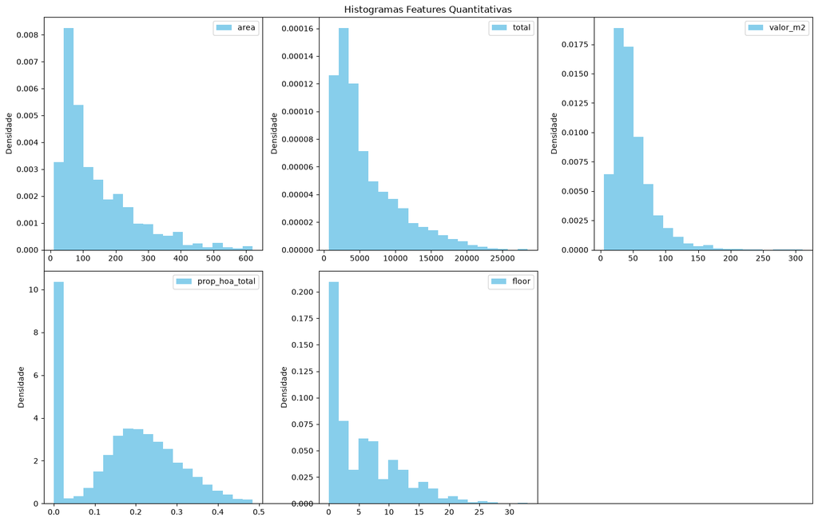

```python
plt.figure(figsize=(15,10))
plt.title('Histogramas Features Quantitativas')
plt.xticks([])
plt.yticks([])
for i in range(5):
    plt.subplot(2,3,i+1)
    plt.hist(segmentacao_final[quanticont].iloc[:,i], bins=20, label=segmentacao_final[quanticont].columns[i], density=True, color='skyblue')
    plt.ylabel('Densidade')
    plt.legend()
plt.tight_layout(rect=[0, 0, 1, 0.96])
```

Os gráficos de distribuições de densidade possuem assimetrias à direita (positiva), que nos indica valores de média maiores que valores de mediana e moda. Isso ocorre pois a distribuição é puxado por valores atípicos (ou até outliers) elevados de uma minoria de imóveis, que geram a cauda longa à direita do gráfico.

A exceção é prop_hoa_total, com um pico aproximadamente em 0.2 (devemos desconsiderar o casos de 0.0, já que são casos sem taxa condominial). Esta é uma leitura interessante e pode ajudar na balização de preços, porém é preciso cautela quanto a qualidade dos dados antes de ser uma decisão final.

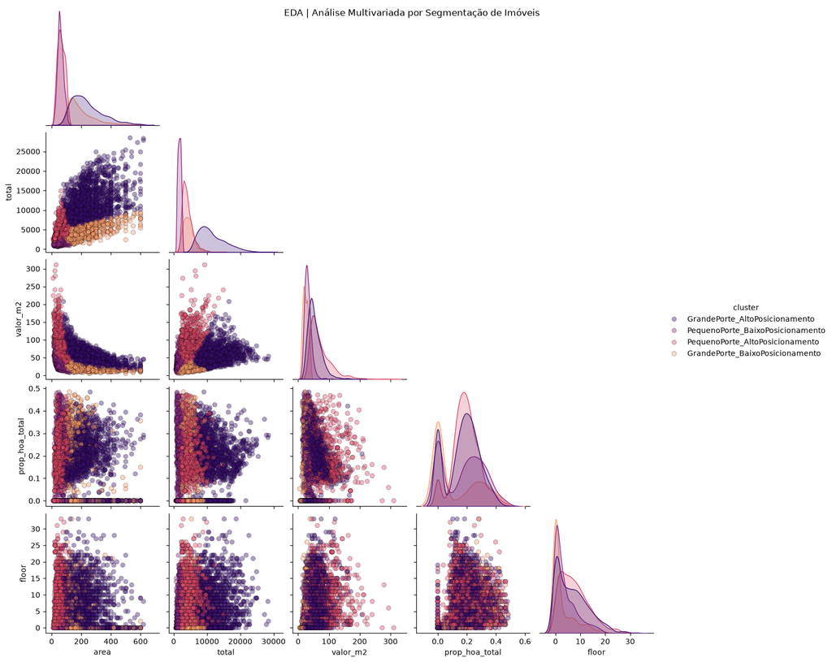

```python
sns.pairplot(data=segmentacao_final, vars=segmentacao_final[quanticont], palette='magma', diag_kind='kde',
             hue='cluster', corner=True, plot_kws={'alpha': 0.4, 'edgecolor':'black'}
             ).figure.suptitle('EDA | Análise Multivariada por Segmentação de Imóveis')
```

Temos alguma separações interessantes: - Valor_m2 X Area e Total (esperado devido ao KMeans, mas ótimo visualizarmos isto no espaço), assim como Area x Total

### Cidade

```python
with pd.option_context('display.max_rows', None):
    display(segmentacao_final.groupby('city')[['area', 'rooms', 'floor', 'total', 'valor_m2']].describe().T)
```

|  | city | 0 | 1 |
| --- | --- | --- | --- |
| area | count | 759.0 | 4943.0 |
|  | mean | 123.071146 | 142.905725 |
|  | std | 107.871382 | 110.817559 |
|  | min | 20.0 | 10.0 |
|  | 25% | 55.0 | 60.0 |
|  | 50% | 77.0 | 103.0 |
|  | 75% | 145.0 | 200.0 |
|  | max | 600.0 | 620.0 |
| rooms | count | 759.0 | 4943.0 |
|  | mean | 2.387352 | 2.517095 |
|  | std | 1.076321 | 1.106098 |
|  | min | 1.0 | 1.0 |
|  | 25% | 2.0 | 2.0 |
|  | 50% | 2.0 | 3.0 |
|  | 75% | 3.0 | 3.0 |
|  | max | 7.0 | 10.0 |
| floor | count | 759.0 | 4943.0 |
|  | mean | 4.546772 | 5.847663 |
|  | std | 4.733267 | 6.02595 |
|  | min | 0.0 | 0.0 |
|  | 25% | 1.0 | 0.0 |
|  | 50% | 3.0 | 4.0 |
|  | 75% | 7.0 | 10.0 |
|  | max | 33.0 | 33.0 |
| total | count | 759.0 | 4943.0 |
|  | mean | 3307.874835 | 6205.629779 |
|  | std | 2779.5222 | 4670.730605 |
|  | min | 736.0 | 660.0 |
|  | 25% | 1493.0 | 2706.0 |
|  | 50% | 2329.0 | 4568.0 |
|  | 75% | 3955.0 | 8611.0 |
|  | max | 20561.0 | 28491.0 |
| valor_m2 | count | 759.0 | 4943.0 |
|  | mean | 30.135429 | 51.422846 |
|  | std | 14.811893 | 30.935095 |
|  | min | 5.771318 | 4.846 |
|  | 25% | 20.618248 | 30.947705 |
|  | 50% | 26.728571 | 43.895455 |
|  | 75% | 36.009783 | 63.090855 |
|  | max | 166.36 | 310.766667 |

```python
cidade0 = segmentacao_final[segmentacao_final['city'] == 0]
cidade1 = segmentacao_final[segmentacao_final['city'] == 1]
```

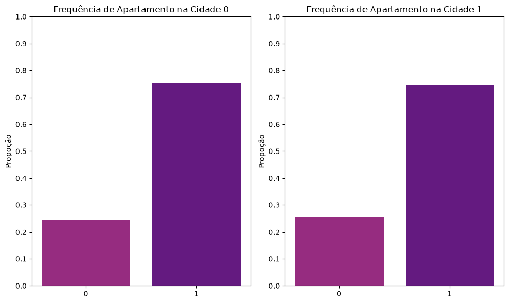

```python
plt.figure(figsize=(10,6))

plt.subplot(1,2,1)
plt.bar(cidade0['apartamento'].value_counts(normalize=True).index, cidade0['apartamento'].value_counts(normalize=True).values, color=cores)
plt.ylabel('Propoção')
plt.title('Frequência de Apartamento na Cidade 0')
plt.xticks(range(0, 2, 1))
plt.yticks(np.arange(0.0, 1.1, 0.1))



plt.subplot(1,2,2)
plt.bar(cidade1['apartamento'].value_counts(normalize=True).index, cidade1['apartamento'].value_counts(normalize=True).values, color=cores)
plt.ylabel('Propoção')
plt.title('Frequência de Apartamento na Cidade 1')
plt.xticks(range(0, 2, 1))
plt.yticks(np.arange(0.0, 1.1, 0.1))


plt.tight_layout()
```

Concentração de maior de apartamentos do que casas em ambas as cidades, inclusive com comportamento identico.

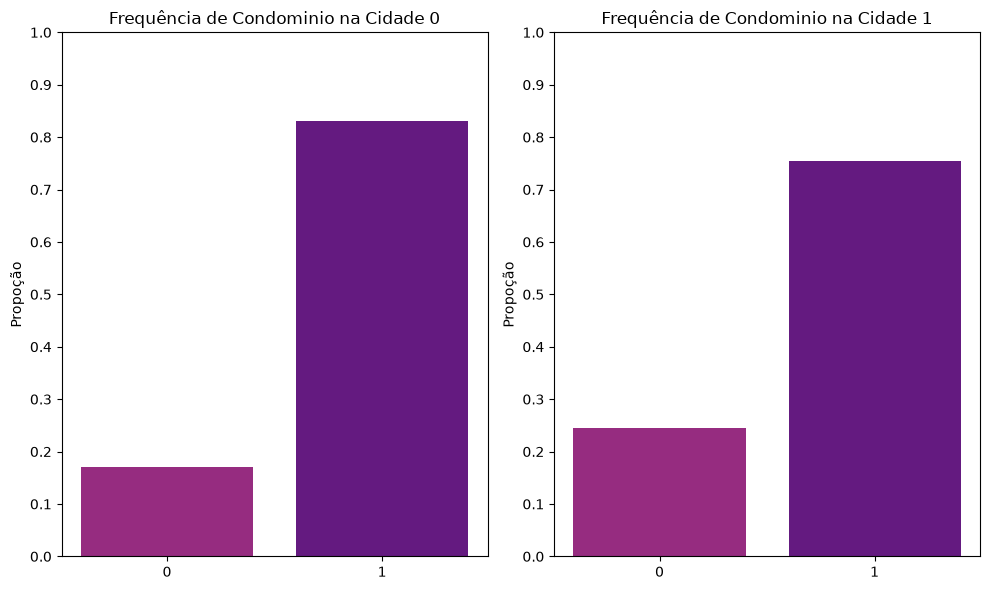

```python
plt.figure(figsize=(10,6))

plt.subplot(1,2,1)
plt.bar(cidade0['condominio'].value_counts(normalize=True).index, cidade0['condominio'].value_counts(normalize=True).values, color=cores)
plt.ylabel('Propoção')
plt.title('Frequência de Condominio na Cidade 0')
plt.yticks(np.arange(0.0, 1.1, 0.1))
plt.xticks(range(0, 2, 1))

plt.subplot(1,2,2)
plt.bar(cidade1['condominio'].value_counts(normalize=True).index, cidade1['condominio'].value_counts(normalize=True).values, color=cores)
plt.ylabel('Propoção')
plt.title('Frequência de Condominio na Cidade 1')
plt.yticks(np.arange(0.0, 1.1, 0.1))
plt.xticks(range(0, 2, 1))

plt.tight_layout()
```

Concentração maior de imóveis com taxa condominial em ambas as cidades, com comportamentos bem aproximados.

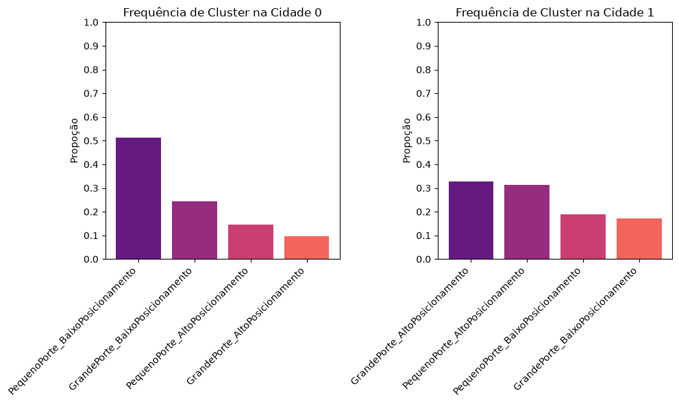

```python
plt.figure(figsize=(10,6))

plt.subplot(1,2,1)
plt.bar(cidade0['cluster'].value_counts(normalize=True).index, cidade0['cluster'].value_counts(normalize=True).values, color=cores)
plt.ylabel('Propoção')
plt.title('Frequência de Cluster na Cidade 0')
plt.yticks(np.arange(0.0, 1.1, 0.1))
plt.xticks(rotation=45, ha='right')

plt.subplot(1,2,2)
plt.bar(cidade1['cluster'].value_counts(normalize=True).index, cidade1['cluster'].value_counts(normalize=True).values, color=cores)
plt.ylabel('Propoção')
plt.title('Frequência de Cluster na Cidade 1')
plt.yticks(np.arange(0.0, 1.1, 0.1))
plt.xticks(rotation=45, ha='right')

plt.tight_layout()
```

```python
print(f'Cidade 0 | Media dos imóveis: {cidade0['total'].mean()} | Mediana dos imóveis: {cidade0['total'].median()}')
print(f'Cidade 1 | Media dos imóveis: {cidade1['total'].mean()} | Mediana dos imóveis: {cidade1['total'].median()}')
```

```
Cidade 0 | Media dos imóveis: 3307.874835309618 | Mediana dos imóveis: 2329.0
Cidade 1 | Media dos imóveis: 6205.629779486142 | Mediana dos imóveis: 4568.0
```

A composição de imóveis é quase que completamente inversa. As duas maiores categorais da cidade 1, são as de menor importância na cidade 0.

### Segmentos de Imóveis

#### Faixa Operacional

[output not shown]

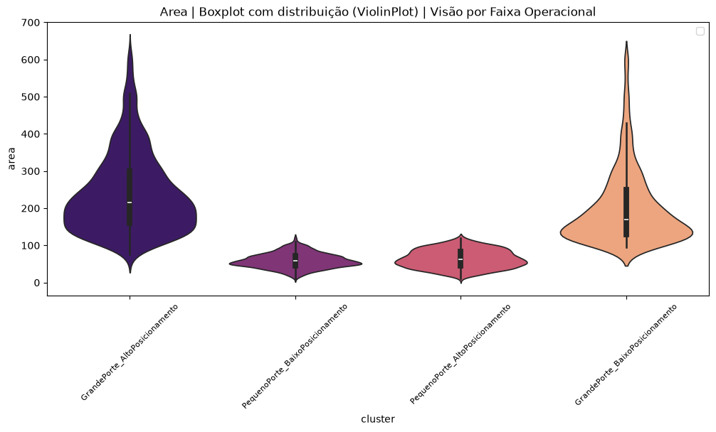

```python
plt.figure(figsize=(12, 5))
sns.violinplot(data=segmentacao_final, y='area',x='cluster', palette='magma')
plt.title('Area | Boxplot com distribuição (ViolinPlot) | Visão por Faixa Operacional')
plt.legend()
plt.xticks(rotation=45, fontsize=8)
```

[output not shown]

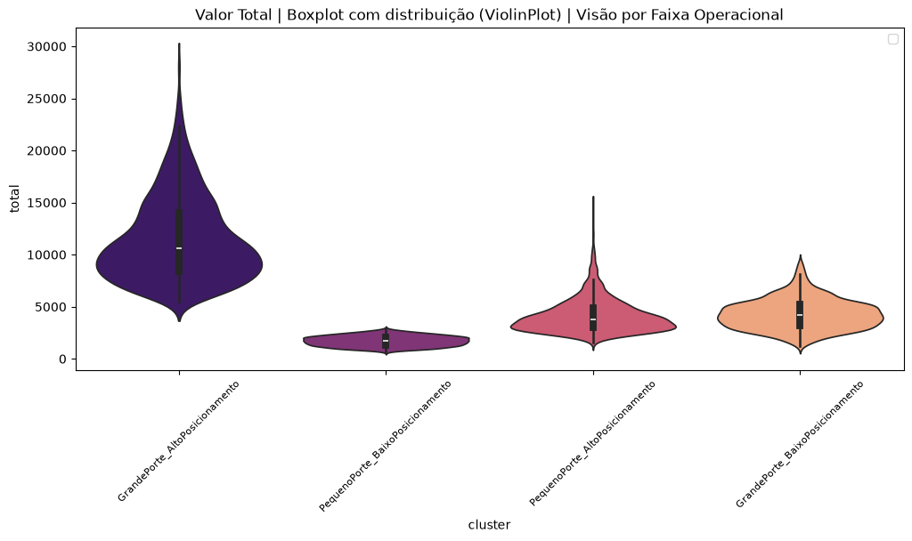

```python
plt.figure(figsize=(12, 5))
sns.violinplot(data=segmentacao_final, y='total',x='cluster', palette='magma')
plt.title('Valor Total | Boxplot com distribuição (ViolinPlot) | Visão por Faixa Operacional')
plt.legend()
plt.xticks(rotation=45, fontsize=8)
```

[output not shown]

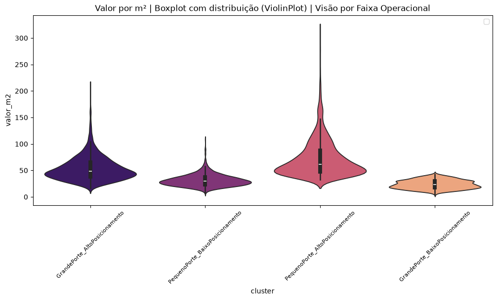

```python
plt.figure(figsize=(12, 5))
sns.violinplot(data=segmentacao_final, y='valor_m2',x='cluster', palette='magma')
plt.title('Valor por m² | Boxplot com distribuição (ViolinPlot) | Visão por Faixa Operacional')
plt.legend()
plt.xticks(rotation=45, fontsize=8)
```

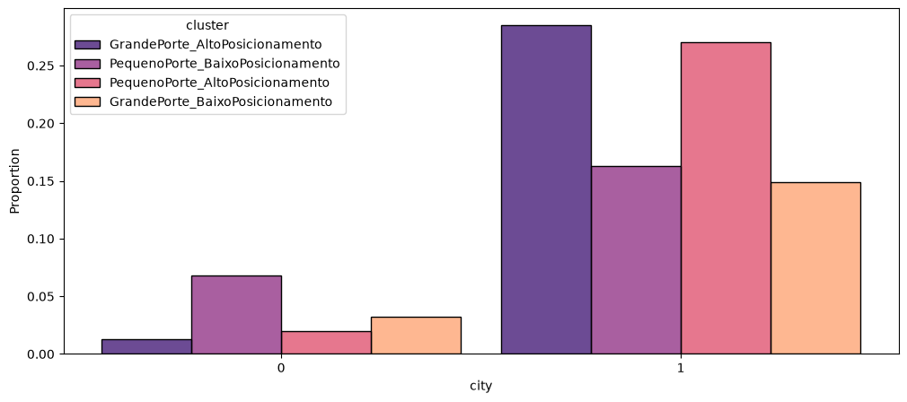

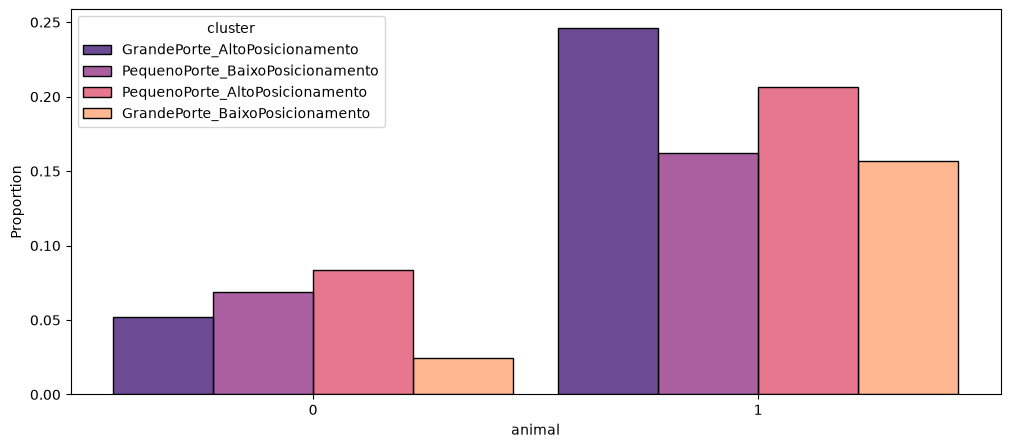

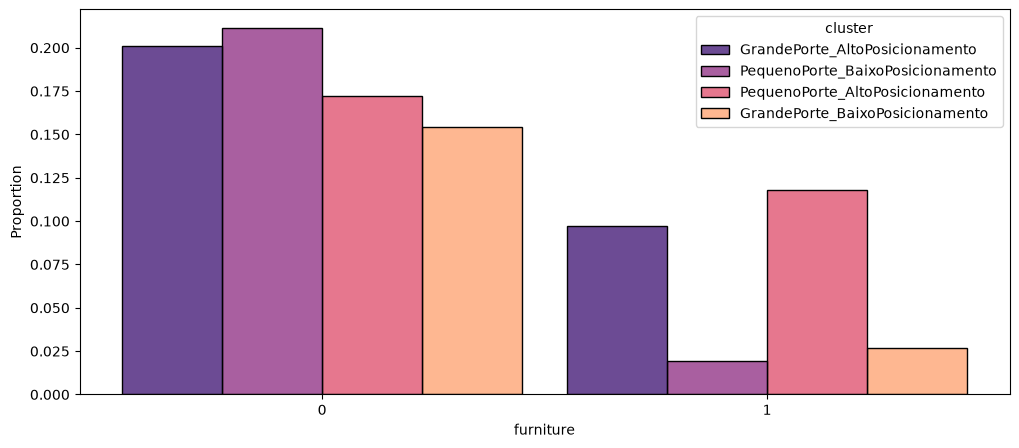

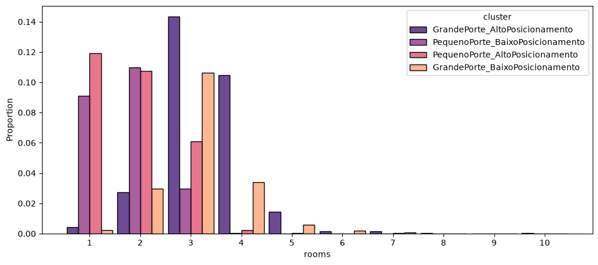

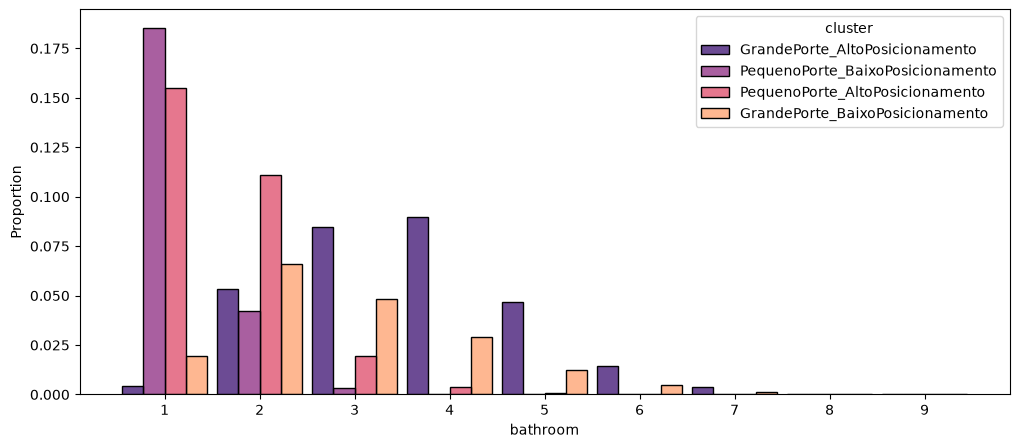

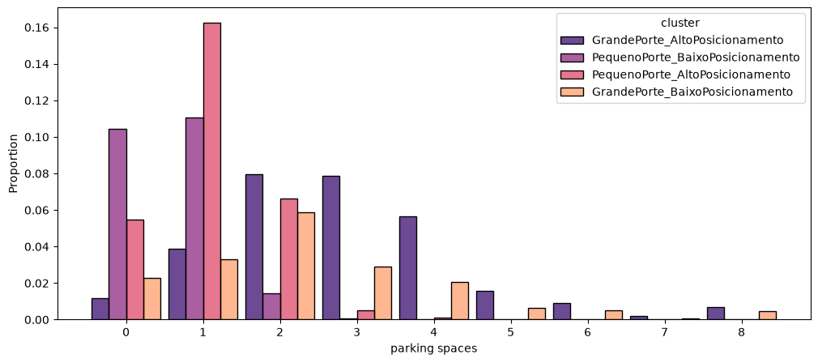

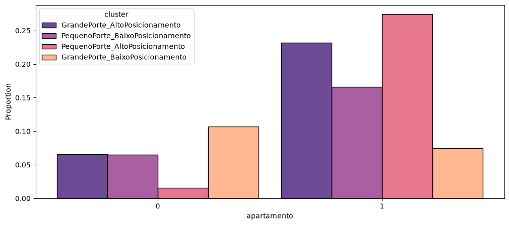

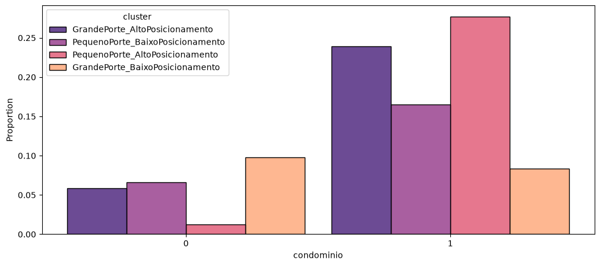

```python
for i in range(len(quali_quantidisc)-1):
    plt.figure(figsize=(12, 5))
    sns.histplot(data=segmentacao_final, x=quali_quantidisc[i], hue='cluster', stat='proportion', multiple='dodge', palette='magma', discrete=True, shrink=0.9)
    plt.xticks(range(segmentacao_final[quali_quantidisc[i]].min(), segmentacao_final[quali_quantidisc[i]].max()+1, 1))
    plt.show()
```